# Analyses in Perceiving through the Grapevine: A Network Approach to Reputations

#### Honesty-Propriety

```r
hp_PTmod_ha <- rep_accuracy_id_mods(study1,
                      target_self = c("C_C_hp",
                                     "A_A_hp"),
                      p2_reports = c("B_C_hp_cent",
                                     "D_A_hp_cent"),
                      id_mod_variable = c("B_iri_perspective_cent",
                                          "D_iri_perspective_cent"),
                      interaction_term = c("PTxHP_B",
                                           "PTxHP_D"))
summary(hp_PTmod_ha, standardized = TRUE)
```

```
## lavaan 0.6-4 ended normally after 25 iterations
##
##   Optimization method                           NLMINB
##   Number of free parameters                         23
##   Number of equality constraints                    11
##   Row rank of the constraints matrix                11
##
##   Number of observations                           124
##   Number of missing patterns                        16
##
##   Estimator                                         ML
##   Model Fit Test Statistic                      36.603
##   Degrees of freedom                                32
##   P-value (Chi-square)                           0.264
##
## Parameter Estimates:
##
##   Information                                 Observed
##   Observed information based on                Hessian
##   Standard Errors                             Standard
##
## Regressions:
##                    Estimate  Std.Err  z-value  P(>|z|)   Std.lv  Std.all
##   C_C_hp ~
##     B_C_hp_ (ha_m)    0.045    0.080    0.563    0.574    0.045    0.044
##     B_r_pr_ (md_m)   -0.002    0.090   -0.024    0.981   -0.002   -0.002
##     PTxHP_B (intr)    0.285    0.168    1.698    0.089    0.285    0.170
##   A_A_hp ~
##     D_A_hp_ (ha_m)    0.045    0.080    0.563    0.574    0.045    0.044
##     D_r_pr_ (md_m)   -0.002    0.090   -0.024    0.981   -0.002   -0.002
##     PTxHP_D (intr)    0.285    0.168    1.698    0.089    0.285    0.170
##
## Covariances:
##                    Estimate  Std.Err  z-value  P(>|z|)   Std.lv  Std.all
##  .C_C_hp ~~
##    .A_A_hp           -0.039    0.030   -1.321    0.186   -0.039   -0.125
##
## Intercepts:
##                    Estimate  Std.Err  z-value  P(>|z|)   Std.lv  Std.all
##    .C_C_hp (int_s)    3.731    0.035  107.880    0.000    3.731    6.568
##     B_C_h_  (in_2)    0.001    0.040    0.019    0.985    0.001    0.001
##     B_r_p_ (int_m)   -0.000    0.060   -0.002    0.999   -0.000   -0.000
##     PTHP_B (int_n)   -0.006    0.033   -0.191    0.848   -0.006   -0.019
##    .A_A_hp (int_s)    3.731    0.035  107.880    0.000    3.731    6.568
##     D_A_h_  (in_2)    0.001    0.040    0.019    0.985    0.001    0.001
##     D_r_p_ (int_m)   -0.000    0.060   -0.002    0.999   -0.000   -0.000
##     PTHP_D (int_n)   -0.006    0.033   -0.191    0.848   -0.006   -0.019
##
## Variances:
##                    Estimate  Std.Err  z-value  P(>|z|)   Std.lv  Std.all
##    .C_C_hp  (v_sl)    0.313    0.030   10.444    0.000    0.313    0.969
##     B_C_hp_ (v_p2)    0.304    0.031    9.744    0.000    0.304    1.000
##     B_r_pr_ (v_md)    0.388    0.053    7.314    0.000    0.388    1.000
##     PTxHP_B (v_nt)    0.115    0.016    7.162    0.000    0.115    1.000
##    .A_A_hp  (v_sl)    0.313    0.030   10.444    0.000    0.313    0.969
##     D_A_hp_ (v_p2)    0.304    0.031    9.744    0.000    0.304    1.000
##     D_r_pr_ (v_md)    0.388    0.053    7.314    0.000    0.388    1.000
##     PTxHP_D (v_nt)    0.115    0.016    7.162    0.000    0.115    1.000
```

#### Neuroticism

```r
neuroticism_PTmod_ha <- rep_accuracy_id_mods(study1,
                      target_self = c("C_C_neuroticism",
                                     "A_A_neuroticism"),
                      p2_reports = c("B_C_neuroticism_cent",
                                     "D_A_neuroticism_cent"),
                      id_mod_variable = c("B_iri_perspective_cent",
                                          "D_iri_perspective_cent"),
                      interaction_term = c("PTxN_B",
                                           "PTxN_D"))
summary(neuroticism_PTmod_ha, standardized = TRUE)
```

```
## lavaan 0.6-4 ended normally after 26 iterations
##
##   Optimization method                           NLMINB
##   Number of free parameters                         23
##   Number of equality constraints                    11
##   Row rank of the constraints matrix                11
##
##   Number of observations                           124
##   Number of missing patterns                        16
##
##   Estimator                                         ML
##   Model Fit Test Statistic                      36.317
##   Degrees of freedom                                32
##   P-value (Chi-square)                           0.274
##
## Parameter Estimates:
##
##   Information                                 Observed
##   Observed information based on                Hessian
##   Standard Errors                             Standard
##
## Regressions:
##                     Estimate  Std.Err  z-value  P(>|z|)   Std.lv  Std.all
##   C_C_neuroticism ~
##     B_C_nr_ (ha_m)     0.179    0.101    1.781    0.075    0.179    0.128
##     B_r_pr_ (md_m)    -0.146    0.124   -1.173    0.241   -0.146   -0.107
##     PTxN_B  (intr)     0.230    0.224    1.026    0.305    0.230    0.095
##   A_A_neuroticism ~
##     D_A_nr_ (ha_m)     0.179    0.101    1.781    0.075    0.179    0.128
##     D_r_pr_ (md_m)    -0.146    0.124   -1.173    0.241   -0.146   -0.107
##     PTxN_D  (intr)     0.230    0.224    1.026    0.305    0.230    0.095
##
## Covariances:
##                      Estimate  Std.Err  z-value  P(>|z|)   Std.lv  Std.all
##  .C_C_neuroticism ~~
##    .A_A_neuroticsm      0.084    0.065    1.296    0.195    0.084    0.121
##
## Intercepts:
##                    Estimate  Std.Err  z-value  P(>|z|)   Std.lv  Std.all
##    .C_C_nr (int_s)    2.887    0.058   50.020    0.000    2.887    3.412
##     B_C_n_  (in_2)    0.002    0.044    0.045    0.964    0.002    0.003
##     B_r_p_ (int_m)    0.000    0.060    0.001    0.999    0.000    0.000
##     PTxN_B (int_n)   -0.019    0.034   -0.550    0.582   -0.019   -0.054
##    .A_A_nr (int_s)    2.887    0.058   50.020    0.000    2.887    3.412
##     D_A_n_  (in_2)    0.002    0.044    0.045    0.964    0.002    0.003
##     D_r_p_ (int_m)    0.000    0.060    0.001    0.999    0.000    0.000
##     PTxN_D (int_n)   -0.019    0.034   -0.550    0.582   -0.019   -0.054
##
## Variances:
##                    Estimate  Std.Err  z-value  P(>|z|)   Std.lv  Std.all
##    .C_C_nrt (v_sl)    0.690    0.065   10.576    0.000    0.690    0.963
##     B_C_nr_ (v_p2)    0.366    0.038    9.750    0.000    0.366    1.000
##     B_r_pr_ (v_md)    0.388    0.053    7.321    0.000    0.388    1.000
##     PTxN_B  (v_nt)    0.123    0.017    7.182    0.000    0.123    1.000
##    .A_A_nrt (v_sl)    0.690    0.065   10.576    0.000    0.690    0.963
##     D_A_nr_ (v_p2)    0.366    0.038    9.750    0.000    0.366    1.000
##     D_r_pr_ (v_md)    0.388    0.053    7.321    0.000    0.388    1.000
##     PTxN_D  (v_nt)    0.123    0.017    7.182    0.000    0.123    1.000
```

#### Extraversion

```r
extraversion_PTmod_ha <- rep_accuracy_id_mods(study1,
                      target_self = c("C_C_extraversion",
                                     "A_A_extraversion"),
                      p2_reports = c("B_C_extraversion_cent",
                                     "D_A_extraversion_cent"),
                      id_mod_variable = c("B_iri_perspective_cent",
                                          "D_iri_perspective_cent"),
                      interaction_term = c("PTxE_B",
                                           "PTxE_D"))
summary(extraversion_PTmod_ha, standardized = TRUE)
```

```
## lavaan 0.6-4 ended normally after 19 iterations
##
##   Optimization method                           NLMINB
##   Number of free parameters                         23
##   Number of equality constraints                    11
##   Row rank of the constraints matrix                11
##
##   Number of observations                           124
##   Number of missing patterns                        16
##
##   Estimator                                         ML
##   Model Fit Test Statistic                      21.370
##   Degrees of freedom                                32
##   P-value (Chi-square)                           0.923
##
## Parameter Estimates:
##
##   Information                                 Observed
##   Observed information based on                Hessian
##   Standard Errors                             Standard
##
## Regressions:
##                      Estimate  Std.Err  z-value  P(>|z|)   Std.lv  Std.all
##   C_C_extraversion ~
##     B_C_xt_ (ha_m)      0.250    0.069    3.601    0.000    0.250    0.251
##     B_r_pr_ (md_m)     -0.013    0.111   -0.115    0.909   -0.013   -0.011
##     PTxE_B  (intr)      0.195    0.152    1.283    0.199    0.195    0.123
##   A_A_extraversion ~
##     D_A_xt_ (ha_m)      0.250    0.069    3.601    0.000    0.250    0.251
##     D_r_pr_ (md_m)     -0.013    0.111   -0.115    0.909   -0.013   -0.011
##     PTxE_D  (intr)      0.195    0.152    1.283    0.199    0.195    0.123
##
## Covariances:
##                       Estimate  Std.Err  z-value  P(>|z|)   Std.lv
##  .C_C_extraversion ~~
##    .A_A_extraversn      -0.044    0.047   -0.923    0.356   -0.044
##   Std.all
##
##    -0.088
##
## Intercepts:
##                    Estimate  Std.Err  z-value  P(>|z|)   Std.lv  Std.all
##    .C_C_xt (int_s)    3.395    0.046   74.310    0.000    3.395    4.640
##     B_C_x_  (in_2)    0.001    0.053    0.018    0.986    0.001    0.001
##     B_r_p_ (int_m)    0.000    0.060    0.003    0.997    0.000    0.000
##     PTxE_B (int_n)    0.073    0.045    1.606    0.108    0.073    0.158
##    .A_A_xt (int_s)    3.395    0.046   74.310    0.000    3.395    4.640
##     D_A_x_  (in_2)    0.001    0.053    0.018    0.986    0.001    0.001
##     D_r_p_ (int_m)    0.000    0.060    0.003    0.997    0.000    0.000
##     PTxE_D (int_n)    0.073    0.045    1.606    0.108    0.073    0.158
##
## Variances:
##                    Estimate  Std.Err  z-value  P(>|z|)   Std.lv  Std.all
##    .C_C_xtr (v_sl)    0.493    0.047   10.488    0.000    0.493    0.922
##     B_C_xt_ (v_p2)    0.540    0.055    9.749    0.000    0.540    1.000
##     B_r_pr_ (v_md)    0.388    0.053    7.314    0.000    0.388    1.000
##     PTxE_B  (v_nt)    0.213    0.030    7.179    0.000    0.213    1.000
##    .A_A_xtr (v_sl)    0.493    0.047   10.488    0.000    0.493    0.922
##     D_A_xt_ (v_p2)    0.540    0.055    9.749    0.000    0.540    1.000
##     D_r_pr_ (v_md)    0.388    0.053    7.314    0.000    0.388    1.000
##     PTxE_D  (v_nt)    0.213    0.030    7.179    0.000    0.213    1.000
```

#### Openness

```r
openness_PTmod_ha <- rep_accuracy_id_mods(study1,
                      target_self = c("C_C_openness",
                                     "A_A_openness"),
                      p2_reports = c("B_C_openness_cent",
                                     "D_A_openness_cent"),
                      id_mod_variable = c("B_iri_perspective_cent",
                                          "D_iri_perspective_cent"),
                      interaction_term = c("PTxO_B",
                                           "PTxO_D"))
summary(openness_PTmod_ha, standardized = TRUE)
```

```
## lavaan 0.6-4 ended normally after 32 iterations
##
##   Optimization method                           NLMINB
##   Number of free parameters                         23
##   Number of equality constraints                    11
##   Row rank of the constraints matrix                11
##
##   Number of observations                           124
##   Number of missing patterns                        16
##
##   Estimator                                         ML
##   Model Fit Test Statistic                      57.426
##   Degrees of freedom                                32
##   P-value (Chi-square)                           0.004
##
## Parameter Estimates:
##
##   Information                                 Observed
##   Observed information based on                Hessian
##   Standard Errors                             Standard
##
## Regressions:
##                    Estimate  Std.Err  z-value  P(>|z|)   Std.lv  Std.all
##   C_C_openness ~
##     B_C_pn_ (ha_m)    0.194    0.092    2.103    0.035    0.194    0.159
##     B_r_pr_ (md_m)   -0.104    0.093   -1.110    0.267   -0.104   -0.110
##     PTxO_B  (intr)    0.299    0.214    1.401    0.161    0.299    0.141
##   A_A_openness ~
##     D_A_pn_ (ha_m)    0.194    0.092    2.103    0.035    0.194    0.159
##     D_r_pr_ (md_m)   -0.104    0.093   -1.110    0.267   -0.104   -0.110
##     PTxO_D  (intr)    0.299    0.214    1.401    0.161    0.299    0.141
##
## Covariances:
##                    Estimate  Std.Err  z-value  P(>|z|)   Std.lv  Std.all
##  .C_C_openness ~~
##    .A_A_openness     -0.014    0.031   -0.446    0.656   -0.014   -0.043
##
## Intercepts:
##                    Estimate  Std.Err  z-value  P(>|z|)   Std.lv  Std.all
##    .C_C_pn (int_s)    3.780    0.040   95.505    0.000    3.780    6.437
##     B_C_p_  (in_2)    0.002    0.035    0.053    0.958    0.002    0.004
##     B_r_p_ (int_m)   -0.001    0.060   -0.021    0.983   -0.001   -0.002
##     PTxO_B (int_n)    0.064    0.027    2.360    0.018    0.064    0.231
##    .A_A_pn (int_s)    3.780    0.040   95.505    0.000    3.780    6.437
##     D_A_p_  (in_2)    0.002    0.035    0.053    0.958    0.002    0.004
##     D_r_p_ (int_m)   -0.001    0.060   -0.021    0.983   -0.001   -0.002
##     PTxO_D (int_n)    0.064    0.027    2.360    0.018    0.064    0.231
##
## Variances:
##                    Estimate  Std.Err  z-value  P(>|z|)   Std.lv  Std.all
##    .C_C_pnn (v_sl)    0.325    0.032   10.278    0.000    0.325    0.943
##     B_C_pn_ (v_p2)    0.229    0.024    9.731    0.000    0.229    1.000
##     B_r_pr_ (v_md)    0.389    0.053    7.307    0.000    0.389    1.000
##     PTxO_B  (v_nt)    0.077    0.011    7.160    0.000    0.077    1.000
##    .A_A_pnn (v_sl)    0.325    0.032   10.278    0.000    0.325    0.943
##     D_A_pn_ (v_p2)    0.229    0.024    9.731    0.000    0.229    1.000
##     D_r_pr_ (v_md)    0.389    0.053    7.307    0.000    0.389    1.000
##     PTxO_D  (v_nt)    0.077    0.011    7.160    0.000    0.077    1.000
```

### Empathic Concern

#### Agreeableness

```r
agreeableness_empmod_ha <- rep_accuracy_id_mods(study1,
                      target_self = c("C_C_agreeableness",
                                     "A_A_agreeableness"),
                      p2_reports = c("B_C_agreeableness_cent",
                                     "D_A_agreeableness_cent"),
                      id_mod_variable = c("B_iri_empathic_cent",
                                          "D_iri_empathic_cent"),
                      interaction_term = c("empxA_B",
                                           "empxA_D"))
summary(agreeableness_empmod_ha, standardized = TRUE)
```

```
## lavaan 0.6-4 ended normally after 32 iterations
##
##   Optimization method                           NLMINB
##   Number of free parameters                         23
##   Number of equality constraints                    11
##   Row rank of the constraints matrix                11
##
##   Number of observations                           124
##   Number of missing patterns                        16
##
##   Estimator                                         ML
##   Model Fit Test Statistic                      56.987
##   Degrees of freedom                                32
##   P-value (Chi-square)                           0.004
##
## Parameter Estimates:
##
##   Information                                 Observed
##   Observed information based on                Hessian
##   Standard Errors                             Standard
##
## Regressions:
##                       Estimate  Std.Err  z-value  P(>|z|)   Std.lv
##   C_C_agreeableness ~
##     B_C_gr_ (ha_m)       0.211    0.076    2.768    0.006    0.211
##     B_r_mp_ (md_m)      -0.113    0.098   -1.153    0.249   -0.113
##     empxA_B (intr)      -0.052    0.192   -0.271    0.787   -0.052
##   A_A_agreeableness ~
##     D_A_gr_ (ha_m)       0.211    0.076    2.768    0.006    0.211
##     D_r_mp_ (md_m)      -0.113    0.098   -1.153    0.249   -0.113
##     empxA_D (intr)      -0.052    0.192   -0.271    0.787   -0.052
##   Std.all
##
##     0.200
##    -0.109
##    -0.026
##
##     0.200
##    -0.109
##    -0.026
```

[output cut: 15 more lines]

```
##    .A_A_gr (int_s)    3.872    0.037  103.971    0.000    3.872    6.978
##     D_A_g_  (in_2)    0.002    0.038    0.062    0.950    0.002    0.004
##     D_r_m_ (int_m)   -0.004    0.052   -0.075    0.940   -0.004   -0.007
##     empA_D (int_n)    0.037    0.027    1.352    0.176    0.037    0.133
##
## Variances:
##                    Estimate  Std.Err  z-value  P(>|z|)   Std.lv  Std.all
##    .C_C_grb (v_sl)    0.292    0.028   10.594    0.000    0.292    0.948
##     B_C_gr_ (v_p2)    0.277    0.028    9.735    0.000    0.277    1.000
##     B_r_mp_ (v_md)    0.290    0.040    7.319    0.000    0.290    1.000
##     empxA_B (v_nt)    0.076    0.011    7.177    0.000    0.076    1.000
##    .A_A_grb (v_sl)    0.292    0.028   10.594    0.000    0.292    0.948
##     D_A_gr_ (v_p2)    0.277    0.028    9.735    0.000    0.277    1.000
##     D_r_mp_ (v_md)    0.290    0.040    7.319    0.000    0.290    1.000
##     empxA_D (v_nt)    0.076    0.011    7.177    0.000    0.076    1.000
```

#### Conscientiousness

```r
conscientiousness_empmod_ha <- rep_accuracy_id_mods(study1,
                      target_self = c("C_C_conscientiousness",
                                     "A_A_conscientiousness"),
                      p2_reports = c("B_C_conscientiousness_cent",
                                     "D_A_conscientiousness_cent"),
                      id_mod_variable = c("B_iri_empathic_cent",
                                          "D_iri_empathic_cent"),
                      interaction_term = c("empxC_B",
                                           "empxC_D"))
summary(conscientiousness_empmod_ha, standardized = TRUE)
```

```
## lavaan 0.6-4 ended normally after 27 iterations
##
##   Optimization method                           NLMINB
##   Number of free parameters                         23
##   Number of equality constraints                    11
##   Row rank of the constraints matrix                11
##
##   Number of observations                           124
##   Number of missing patterns                        16
##
##   Estimator                                         ML
##   Model Fit Test Statistic                      40.725
##   Degrees of freedom                                32
##   P-value (Chi-square)                           0.139
##
## Parameter Estimates:
##
##   Information                                 Observed
##   Observed information based on                Hessian
##   Standard Errors                             Standard
##
## Regressions:
##                           Estimate  Std.Err  z-value  P(>|z|)   Std.lv
##   C_C_conscientiousness ~
##     B_C_cn_ (ha_m)           0.094    0.082    1.157    0.247    0.094
##     B_r_mp_ (md_m)          -0.122    0.118   -1.033    0.302   -0.122
##     empxC_B (intr)           0.041    0.202    0.204    0.839    0.041
##   A_A_conscientiousness ~
##     D_A_cn_ (ha_m)           0.094    0.082    1.157    0.247    0.094
##     D_r_mp_ (md_m)          -0.122    0.118   -1.033    0.302   -0.122
##     empxC_D (intr)           0.041    0.202    0.204    0.839    0.041
##   Std.all
##
##     0.091
##    -0.102
##     0.021
##
##     0.091
##    -0.102
##     0.021
```

[output cut: 15 more lines]

```
##    .A_A_cn (int_s)    3.524    0.041   86.224    0.000    3.524    5.512
##     D_A_c_  (in_2)    0.001    0.045    0.027    0.978    0.001    0.002
##     D_r_m_ (int_m)   -0.003    0.052   -0.058    0.954   -0.003   -0.006
##     empC_D (int_n)    0.051    0.032    1.581    0.114    0.051    0.156
##
## Variances:
##                    Estimate  Std.Err  z-value  P(>|z|)   Std.lv  Std.all
##    .C_C_cns (v_sl)    0.401    0.037   10.729    0.000    0.401    0.981
##     B_C_cn_ (v_p2)    0.378    0.039    9.741    0.000    0.378    1.000
##     B_r_mp_ (v_md)    0.290    0.040    7.313    0.000    0.290    1.000
##     empxC_B (v_nt)    0.108    0.015    7.176    0.000    0.108    1.000
##    .A_A_cns (v_sl)    0.401    0.037   10.729    0.000    0.401    0.981
##     D_A_cn_ (v_p2)    0.378    0.039    9.741    0.000    0.378    1.000
##     D_r_mp_ (v_md)    0.290    0.040    7.313    0.000    0.290    1.000
##     empxC_D (v_nt)    0.108    0.015    7.176    0.000    0.108    1.000
```

#### Honesty-Propriety

```r
hp_empmod_ha <- rep_accuracy_id_mods(study1,
                      target_self = c("C_C_hp",
                                     "A_A_hp"),
                      p2_reports = c("B_C_hp_cent",
                                     "D_A_hp_cent"),
                      id_mod_variable = c("B_iri_empathic_cent",
                                          "D_iri_empathic_cent"),
                      interaction_term = c("empxHP_B",
                                           "empxHP_D"))
summary(hp_empmod_ha, standardized = TRUE)
```

```
## lavaan 0.6-4 ended normally after 29 iterations
##
##   Optimization method                           NLMINB
##   Number of free parameters                         23
##   Number of equality constraints                    11
##   Row rank of the constraints matrix                11
##
##   Number of observations                           124
##   Number of missing patterns                        16
##
##   Estimator                                         ML
##   Model Fit Test Statistic                      70.576
##   Degrees of freedom                                32
##   P-value (Chi-square)                           0.000
##
## Parameter Estimates:
##
##   Information                                 Observed
##   Observed information based on                Hessian
##   Standard Errors                             Standard
##
## Regressions:
##                    Estimate  Std.Err  z-value  P(>|z|)   Std.lv  Std.all
##   C_C_hp ~
##     B_C_hp_ (ha_m)    0.116    0.083    1.399    0.162    0.116    0.112
##     B_r_mp_ (md_m)   -0.123    0.104   -1.181    0.238   -0.123   -0.117
##     empHP_B (intr)   -0.330    0.210   -1.572    0.116   -0.330   -0.163
##   A_A_hp ~
##     D_A_hp_ (ha_m)    0.116    0.083    1.399    0.162    0.116    0.112
##     D_r_mp_ (md_m)   -0.123    0.104   -1.181    0.238   -0.123   -0.117
##     empHP_D (intr)   -0.330    0.210   -1.572    0.116   -0.330   -0.163
##
## Covariances:
##                    Estimate  Std.Err  z-value  P(>|z|)   Std.lv  Std.all
##  .C_C_hp ~~
##    .A_A_hp           -0.031    0.029   -1.079    0.281   -0.031   -0.102
##
## Intercepts:
##                    Estimate  Std.Err  z-value  P(>|z|)   Std.lv  Std.all
##    .C_C_hp (int_s)    3.737    0.035  105.772    0.000    3.737    6.561
##     B_C_h_  (in_2)    0.002    0.040    0.046    0.963    0.002    0.003
##     B_r_m_ (int_m)   -0.004    0.052   -0.085    0.933   -0.004   -0.008
##     emHP_B (int_n)    0.027    0.028    0.972    0.331    0.027    0.095
##    .A_A_hp (int_s)    3.737    0.035  105.772    0.000    3.737    6.561
##     D_A_h_  (in_2)    0.002    0.040    0.046    0.963    0.002    0.003
##     D_r_m_ (int_m)   -0.004    0.052   -0.085    0.933   -0.004   -0.008
##     emHP_D (int_n)    0.027    0.028    0.972    0.331    0.027    0.095
##
## Variances:
##                    Estimate  Std.Err  z-value  P(>|z|)   Std.lv  Std.all
##    .C_C_hp  (v_sl)    0.307    0.030   10.135    0.000    0.307    0.947
##     B_C_hp_ (v_p2)    0.304    0.031    9.731    0.000    0.304    1.000
##     B_r_mp_ (v_md)    0.291    0.040    7.306    0.000    0.291    1.000
##     empHP_B (v_nt)    0.079    0.011    7.160    0.000    0.079    1.000
##    .A_A_hp  (v_sl)    0.307    0.030   10.135    0.000    0.307    0.947
##     D_A_hp_ (v_p2)    0.304    0.031    9.731    0.000    0.304    1.000
##     D_r_mp_ (v_md)    0.291    0.040    7.306    0.000    0.291    1.000
##     empHP_D (v_nt)    0.079    0.011    7.160    0.000    0.079    1.000
```

#### Neuroticism

```r
neuroticism_empmod_ha <- rep_accuracy_id_mods(study1,
                      target_self = c("C_C_neuroticism",
                                     "A_A_neuroticism"),
                      p2_reports = c("B_C_neuroticism_cent",
                                     "D_A_neuroticism_cent"),
                      id_mod_variable = c("B_iri_empathic_cent",
                                          "D_iri_empathic_cent"),
                      interaction_term = c("empxN_B",
                                           "empxN_D"))
summary(neuroticism_empmod_ha, standardized = TRUE)
```

```
## lavaan 0.6-4 ended normally after 28 iterations
##
##   Optimization method                           NLMINB
##   Number of free parameters                         23
##   Number of equality constraints                    11
##   Row rank of the constraints matrix                11
##
##   Number of observations                           124
##   Number of missing patterns                        16
##
##   Estimator                                         ML
##   Model Fit Test Statistic                      53.205
##   Degrees of freedom                                32
##   P-value (Chi-square)                           0.011
##
## Parameter Estimates:
##
##   Information                                 Observed
##   Observed information based on                Hessian
##   Standard Errors                             Standard
##
## Regressions:
##                     Estimate  Std.Err  z-value  P(>|z|)   Std.lv  Std.all
##   C_C_neuroticism ~
##     B_C_nr_ (ha_m)     0.187    0.101    1.855    0.064    0.187    0.134
##     B_r_mp_ (md_m)     0.224    0.148    1.509    0.131    0.224    0.142
##     empxN_B (intr)    -0.096    0.269   -0.358    0.721   -0.096   -0.034
##   A_A_neuroticism ~
##     D_A_nr_ (ha_m)     0.187    0.101    1.855    0.064    0.187    0.134
##     D_r_mp_ (md_m)     0.224    0.148    1.509    0.131    0.224    0.142
##     empxN_D (intr)    -0.096    0.269   -0.358    0.721   -0.096   -0.034
##
## Covariances:
##                      Estimate  Std.Err  z-value  P(>|z|)   Std.lv  Std.all
##  .C_C_neuroticism ~~
##    .A_A_neuroticsm      0.072    0.065    1.111    0.267    0.072    0.104
##
## Intercepts:
##                    Estimate  Std.Err  z-value  P(>|z|)   Std.lv  Std.all
##    .C_C_nr (int_s)    2.880    0.057   50.254    0.000    2.880    3.402
##     B_C_n_  (in_2)    0.002    0.044    0.049    0.961    0.002    0.004
##     B_r_m_ (int_m)    0.000    0.052    0.001    0.999    0.000    0.000
##     empN_B (int_n)   -0.017    0.030   -0.561    0.575   -0.017   -0.055
##    .A_A_nr (int_s)    2.880    0.057   50.254    0.000    2.880    3.402
##     D_A_n_  (in_2)    0.002    0.044    0.049    0.961    0.002    0.004
##     D_r_m_ (int_m)    0.000    0.052    0.001    0.999    0.000    0.000
##     empN_D (int_n)   -0.017    0.030   -0.561    0.575   -0.017   -0.055
##
## Variances:
##                    Estimate  Std.Err  z-value  P(>|z|)   Std.lv  Std.all
##    .C_C_nrt (v_sl)    0.688    0.065   10.534    0.000    0.688    0.961
##     B_C_nr_ (v_p2)    0.366    0.038    9.750    0.000    0.366    1.000
##     B_r_mp_ (v_md)    0.290    0.040    7.327    0.000    0.290    1.000
##     empxN_B (v_nt)    0.090    0.013    7.177    0.000    0.090    1.000
##    .A_A_nrt (v_sl)    0.688    0.065   10.534    0.000    0.688    0.961
##     D_A_nr_ (v_p2)    0.366    0.038    9.750    0.000    0.366    1.000
##     D_r_mp_ (v_md)    0.290    0.040    7.327    0.000    0.290    1.000
##     empxN_D (v_nt)    0.090    0.013    7.177    0.000    0.090    1.000
```

#### Extraversion

```r
extraversion_empmod_ha <- rep_accuracy_id_mods(study1,
                      target_self = c("C_C_extraversion",
                                     "A_A_extraversion"),
                      p2_reports = c("B_C_extraversion_cent",
                                     "D_A_extraversion_cent"),
                      id_mod_variable = c("B_iri_empathic_cent",
                                          "D_iri_empathic_cent"),
                      interaction_term = c("empxE_B",
                                           "empxE_D"))
summary(extraversion_empmod_ha, standardized = TRUE)
```

```
## lavaan 0.6-4 ended normally after 24 iterations
##
##   Optimization method                           NLMINB
##   Number of free parameters                         23
##   Number of equality constraints                    11
##   Row rank of the constraints matrix                11
##
##   Number of observations                           124
##   Number of missing patterns                        16
##
##   Estimator                                         ML
##   Model Fit Test Statistic                      41.499
##   Degrees of freedom                                32
##   P-value (Chi-square)                           0.121
##
## Parameter Estimates:
##
##   Information                                 Observed
##   Observed information based on                Hessian
##   Standard Errors                             Standard
##
## Regressions:
##                      Estimate  Std.Err  z-value  P(>|z|)   Std.lv  Std.all
##   C_C_extraversion ~
##     B_C_xt_ (ha_m)      0.270    0.068    3.962    0.000    0.270    0.270
##     B_r_mp_ (md_m)     -0.314    0.121   -2.598    0.009   -0.314   -0.230
##     empxE_B (intr)      0.101    0.177    0.573    0.566    0.101    0.053
##   A_A_extraversion ~
##     D_A_xt_ (ha_m)      0.270    0.068    3.962    0.000    0.270    0.270
##     D_r_mp_ (md_m)     -0.314    0.121   -2.598    0.009   -0.314   -0.230
##     empxE_D (intr)      0.101    0.177    0.573    0.566    0.101    0.053
##
## Covariances:
##                       Estimate  Std.Err  z-value  P(>|z|)   Std.lv
##  .C_C_extraversion ~~
##    .A_A_extraversn      -0.058    0.047   -1.249    0.212   -0.058
##   Std.all
##
##    -0.123
##
## Intercepts:
##                    Estimate  Std.Err  z-value  P(>|z|)   Std.lv  Std.all
##    .C_C_xt (int_s)    3.406    0.045   75.961    0.000    3.406    4.631
##     B_C_x_  (in_2)    0.001    0.053    0.018    0.986    0.001    0.001
##     B_r_m_ (int_m)    0.004    0.051    0.073    0.942    0.004    0.007
##     empE_B (int_n)    0.051    0.038    1.340    0.180    0.051    0.132
##    .A_A_xt (int_s)    3.406    0.045   75.961    0.000    3.406    4.631
##     D_A_x_  (in_2)    0.001    0.053    0.018    0.986    0.001    0.001
##     D_r_m_ (int_m)    0.004    0.051    0.073    0.942    0.004    0.007
##     empE_D (int_n)    0.051    0.038    1.340    0.180    0.051    0.132
##
## Variances:
##                    Estimate  Std.Err  z-value  P(>|z|)   Std.lv  Std.all
##    .C_C_xtr (v_sl)    0.472    0.047    9.983    0.000    0.472    0.872
##     B_C_xt_ (v_p2)    0.540    0.055    9.747    0.000    0.540    1.000
##     B_r_mp_ (v_md)    0.290    0.040    7.328    0.000    0.290    1.000
##     empxE_B (v_nt)    0.147    0.021    7.177    0.000    0.147    1.000
##    .A_A_xtr (v_sl)    0.472    0.047    9.983    0.000    0.472    0.872
##     D_A_xt_ (v_p2)    0.540    0.055    9.747    0.000    0.540    1.000
##     D_r_mp_ (v_md)    0.290    0.040    7.328    0.000    0.290    1.000
##     empxE_D (v_nt)    0.147    0.021    7.177    0.000    0.147    1.000
```

#### Openness

```r
openness_empmod_ha <- rep_accuracy_id_mods(study1,
                      target_self = c("C_C_openness",
                                     "A_A_openness"),
                      p2_reports = c("B_C_openness_cent",
                                     "D_A_openness_cent"),
                      id_mod_variable = c("B_iri_empathic_cent",
                                          "D_iri_empathic_cent"),
                      interaction_term = c("empxO_B",
                                           "empxO_D"))
summary(openness_empmod_ha, standardized = TRUE)
```

```
## lavaan 0.6-4 ended normally after 69 iterations
##
##   Optimization method                           NLMINB
##   Number of free parameters                         23
##   Number of equality constraints                    11
##   Row rank of the constraints matrix                11
##
##   Number of observations                           124
##   Number of missing patterns                        16
##
##   Estimator                                         ML
##   Model Fit Test Statistic                      90.763
##   Degrees of freedom                                32
##   P-value (Chi-square)                           0.000
##
## Parameter Estimates:
##
##   Information                                 Observed
##   Observed information based on                Hessian
##   Standard Errors                             Standard
##
## Regressions:
##                    Estimate  Std.Err  z-value  P(>|z|)   Std.lv  Std.all
##   C_C_openness ~
##     B_C_pn_ (ha_m)    0.186    0.095    1.964    0.050    0.186    0.152
##     B_r_mp_ (md_m)   -0.147    0.111   -1.329    0.184   -0.147   -0.135
##     empxO_B (intr)    0.035    0.292    0.122    0.903    0.035    0.013
##   A_A_openness ~
##     D_A_pn_ (ha_m)    0.186    0.095    1.964    0.050    0.186    0.152
##     D_r_mp_ (md_m)   -0.147    0.111   -1.329    0.184   -0.147   -0.135
##     empxO_D (intr)    0.035    0.292    0.122    0.903    0.035    0.013
##
## Covariances:
##                    Estimate  Std.Err  z-value  P(>|z|)   Std.lv  Std.all
##  .C_C_openness ~~
##    .A_A_openness     -0.019    0.032   -0.579    0.562   -0.019   -0.056
##
## Intercepts:
##                    Estimate  Std.Err  z-value  P(>|z|)   Std.lv  Std.all
##    .C_C_pn (int_s)    3.798    0.038   99.342    0.000    3.798    6.475
##     B_C_p_  (in_2)    0.002    0.035    0.051    0.959    0.002    0.004
##     B_r_m_ (int_m)   -0.001    0.052   -0.027    0.979   -0.001   -0.003
##     empO_B (int_n)    0.037    0.021    1.762    0.078    0.037    0.174
##    .A_A_pn (int_s)    3.798    0.038   99.342    0.000    3.798    6.475
##     D_A_p_  (in_2)    0.002    0.035    0.051    0.959    0.002    0.004
##     D_r_m_ (int_m)   -0.001    0.052   -0.027    0.979   -0.001   -0.003
##     empO_D (int_n)    0.037    0.021    1.762    0.078    0.037    0.174
##
## Variances:
##                    Estimate  Std.Err  z-value  P(>|z|)   Std.lv  Std.all
##    .C_C_pnn (v_sl)    0.330    0.031   10.550    0.000    0.330    0.958
##     B_C_pn_ (v_p2)    0.229    0.024    9.732    0.000    0.229    1.000
##     B_r_mp_ (v_md)    0.291    0.040    7.303    0.000    0.291    1.000
##     empxO_B (v_nt)    0.046    0.006    7.176    0.000    0.046    1.000
##    .A_A_pnn (v_sl)    0.330    0.031   10.550    0.000    0.330    0.958
##     D_A_pn_ (v_p2)    0.229    0.024    9.732    0.000    0.229    1.000
##     D_r_mp_ (v_md)    0.291    0.040    7.303    0.000    0.291    1.000
##     empxO_D (v_nt)    0.046    0.006    7.176    0.000    0.046    1.000
```

### Personal Distress

#### Agreeableness

```r
agreeableness_dismod_ha <- rep_accuracy_id_mods(study1,
                      target_self = c("C_C_agreeableness",
                                     "A_A_agreeableness"),
                      p2_reports = c("B_C_agreeableness_cent",
                                     "D_A_agreeableness_cent"),
                      id_mod_variable = c("B_iri_distress_cent",
                                          "D_iri_distress_cent"),
                      interaction_term = c("disxA_B",
                                           "disxA_D"))
summary(agreeableness_dismod_ha, standardized = TRUE)
```

```
## lavaan 0.6-4 ended normally after 27 iterations
##
##   Optimization method                           NLMINB
##   Number of free parameters                         23
##   Number of equality constraints                    11
##   Row rank of the constraints matrix                11
##
##   Number of observations                           124
##   Number of missing patterns                        16
##
##   Estimator                                         ML
##   Model Fit Test Statistic                      57.737
##   Degrees of freedom                                32
##   P-value (Chi-square)                           0.004
##
## Parameter Estimates:
##
##   Information                                 Observed
##   Observed information based on                Hessian
##   Standard Errors                             Standard
##
## Regressions:
##                       Estimate  Std.Err  z-value  P(>|z|)   Std.lv
##   C_C_agreeableness ~
##     B_C_gr_ (ha_m)       0.203    0.076    2.682    0.007    0.203
##     B_r_ds_ (md_m)       0.020    0.078    0.253    0.800    0.020
##     disxA_B (intr)       0.056    0.151    0.370    0.711    0.056
##   A_A_agreeableness ~
##     D_A_gr_ (ha_m)       0.203    0.076    2.682    0.007    0.203
##     D_r_ds_ (md_m)       0.020    0.078    0.253    0.800    0.020
##     disxA_D (intr)       0.056    0.151    0.370    0.711    0.056
##   Std.all
##
##     0.193
##     0.025
##     0.037
##
##     0.193
##     0.025
##     0.037
```

[output cut: 15 more lines]

```
##    .A_A_gr (int_s)    3.871    0.037  105.235    0.000    3.871    6.980
##     D_A_g_  (in_2)    0.002    0.038    0.061    0.951    0.002    0.004
##     D_r_d_ (int_m)    0.001    0.068    0.017    0.986    0.001    0.002
##     dsxA_D (int_n)   -0.003    0.037   -0.078    0.938   -0.003   -0.008
##
## Variances:
##                    Estimate  Std.Err  z-value  P(>|z|)   Std.lv  Std.all
##    .C_C_grb (v_sl)    0.295    0.027   10.753    0.000    0.295    0.961
##     B_C_gr_ (v_p2)    0.276    0.028    9.735    0.000    0.276    1.000
##     B_r_ds_ (v_md)    0.499    0.068    7.315    0.000    0.499    1.000
##     disxA_B (v_nt)    0.137    0.019    7.177    0.000    0.137    1.000
##    .A_A_grb (v_sl)    0.295    0.027   10.753    0.000    0.295    0.961
##     D_A_gr_ (v_p2)    0.276    0.028    9.735    0.000    0.276    1.000
##     D_r_ds_ (v_md)    0.499    0.068    7.315    0.000    0.499    1.000
##     disxA_D (v_nt)    0.137    0.019    7.177    0.000    0.137    1.000
```

#### Conscientiousness

```r
conscientiousness_dismod_ha <- rep_accuracy_id_mods(study1,
                      target_self = c("C_C_conscientiousness",
                                     "A_A_conscientiousness"),
                      p2_reports = c("B_C_conscientiousness_cent",
                                     "D_A_conscientiousness_cent"),
                      id_mod_variable = c("B_iri_distress_cent",
                                          "D_iri_distress_cent"),
                      interaction_term = c("disxC_B",
                                           "disxC_D"))
summary(conscientiousness_dismod_ha, standardized = TRUE)
```

```
## lavaan 0.6-4 ended normally after 22 iterations
##
##   Optimization method                           NLMINB
##   Number of free parameters                         23
##   Number of equality constraints                    11
##   Row rank of the constraints matrix                11
##
##   Number of observations                           124
##   Number of missing patterns                        16
##
##   Estimator                                         ML
##   Model Fit Test Statistic                      49.444
##   Degrees of freedom                                32
##   P-value (Chi-square)                           0.025
##
## Parameter Estimates:
##
##   Information                                 Observed
##   Observed information based on                Hessian
##   Standard Errors                             Standard
##
## Regressions:
##                           Estimate  Std.Err  z-value  P(>|z|)   Std.lv
##   C_C_conscientiousness ~
##     B_C_cn_ (ha_m)           0.087    0.079    1.101    0.271    0.087
##     B_r_ds_ (md_m)           0.011    0.094    0.122    0.903    0.011
##     disxC_B (intr)           0.133    0.144    0.918    0.358    0.133
##   A_A_conscientiousness ~
##     D_A_cn_ (ha_m)           0.087    0.079    1.101    0.271    0.087
##     D_r_ds_ (md_m)           0.011    0.094    0.122    0.903    0.011
##     disxC_D (intr)           0.133    0.144    0.918    0.358    0.133
##   Std.all
##
##     0.083
##     0.013
##     0.095
##
##     0.083
##     0.013
##     0.095
```

[output cut: 15 more lines]

```
##    .A_A_cn (int_s)    3.526    0.039   89.547    0.000    3.526    5.517
##     D_A_c_  (in_2)    0.001    0.045    0.026    0.979    0.001    0.002
##     D_r_d_ (int_m)    0.001    0.068    0.007    0.994    0.001    0.001
##     dsxC_D (int_n)   -0.006    0.045   -0.138    0.890   -0.006   -0.014
##
## Variances:
##                    Estimate  Std.Err  z-value  P(>|z|)   Std.lv  Std.all
##    .C_C_cns (v_sl)    0.402    0.037   10.746    0.000    0.402    0.984
##     B_C_cn_ (v_p2)    0.378    0.039    9.742    0.000    0.378    1.000
##     B_r_ds_ (v_md)    0.499    0.068    7.314    0.000    0.499    1.000
##     disxC_B (v_nt)    0.211    0.029    7.173    0.000    0.211    1.000
##    .A_A_cns (v_sl)    0.402    0.037   10.746    0.000    0.402    0.984
##     D_A_cn_ (v_p2)    0.378    0.039    9.742    0.000    0.378    1.000
##     D_r_ds_ (v_md)    0.499    0.068    7.314    0.000    0.499    1.000
##     disxC_D (v_nt)    0.211    0.029    7.173    0.000    0.211    1.000
```

#### Honesty-Propriety

```r
hp_dismod_ha <- rep_accuracy_id_mods(study1,
                      target_self = c("C_C_hp",
                                     "A_A_hp"),
                      p2_reports = c("B_C_hp_cent",
                                     "D_A_hp_cent"),
                      id_mod_variable = c("B_iri_distress_cent",
                                          "D_iri_distress_cent"),
                      interaction_term = c("disxHP_B",
                                           "disxHP_D"))
summary(hp_dismod_ha, standardized = TRUE)
```

```
## lavaan 0.6-4 ended normally after 26 iterations
##
##   Optimization method                           NLMINB
##   Number of free parameters                         23
##   Number of equality constraints                    11
##   Row rank of the constraints matrix                11
##
##   Number of observations                           124
##   Number of missing patterns                        16
##
##   Estimator                                         ML
##   Model Fit Test Statistic                      51.078
##   Degrees of freedom                                32
##   P-value (Chi-square)                           0.018
##
## Parameter Estimates:
##
##   Information                                 Observed
##   Observed information based on                Hessian
##   Standard Errors                             Standard
##
## Regressions:
##                    Estimate  Std.Err  z-value  P(>|z|)   Std.lv  Std.all
##   C_C_hp ~
##     B_C_hp_ (ha_m)    0.071    0.080    0.895    0.371    0.071    0.069
##     B_r_ds_ (md_m)    0.044    0.086    0.517    0.605    0.044    0.055
##     dsxHP_B (intr)   -0.153    0.150   -1.017    0.309   -0.153   -0.107
##   A_A_hp ~
##     D_A_hp_ (ha_m)    0.071    0.080    0.895    0.371    0.071    0.069
##     D_r_ds_ (md_m)    0.044    0.086    0.517    0.605    0.044    0.055
##     dsxHP_D (intr)   -0.153    0.150   -1.017    0.309   -0.153   -0.107
##
## Covariances:
##                    Estimate  Std.Err  z-value  P(>|z|)   Std.lv  Std.all
##  .C_C_hp ~~
##    .A_A_hp           -0.036    0.030   -1.205    0.228   -0.036   -0.114
##
## Intercepts:
##                    Estimate  Std.Err  z-value  P(>|z|)   Std.lv  Std.all
##    .C_C_hp (int_s)    3.727    0.035  107.125    0.000    3.727    6.554
##     B_C_h_  (in_2)    0.001    0.040    0.029    0.977    0.001    0.002
##     B_r_d_ (int_m)    0.003    0.068    0.042    0.967    0.003    0.004
##     dsHP_B (int_n)   -0.012    0.039   -0.316    0.752   -0.012   -0.031
##    .A_A_hp (int_s)    3.727    0.035  107.125    0.000    3.727    6.554
##     D_A_h_  (in_2)    0.001    0.040    0.029    0.977    0.001    0.002
##     D_r_d_ (int_m)    0.003    0.068    0.042    0.967    0.003    0.004
##     dsHP_D (int_n)   -0.012    0.039   -0.316    0.752   -0.012   -0.031
##
## Variances:
##                    Estimate  Std.Err  z-value  P(>|z|)   Std.lv  Std.all
##    .C_C_hp  (v_sl)    0.317    0.030   10.602    0.000    0.317    0.981
##     B_C_hp_ (v_p2)    0.304    0.031    9.741    0.000    0.304    1.000
##     B_r_ds_ (v_md)    0.499    0.068    7.313    0.000    0.499    1.000
##     dsxHP_B (v_nt)    0.159    0.022    7.169    0.000    0.159    1.000
##    .A_A_hp  (v_sl)    0.317    0.030   10.602    0.000    0.317    0.981
##     D_A_hp_ (v_p2)    0.304    0.031    9.741    0.000    0.304    1.000
##     D_r_ds_ (v_md)    0.499    0.068    7.313    0.000    0.499    1.000
##     dsxHP_D (v_nt)    0.159    0.022    7.169    0.000    0.159    1.000
```

#### Neuroticism

```r
neuroticism_dismod_ha <- rep_accuracy_id_mods(study1,
                      target_self = c("C_C_neuroticism",
                                     "A_A_neuroticism"),
                      p2_reports = c("B_C_neuroticism_cent",
                                     "D_A_neuroticism_cent"),
                      id_mod_variable = c("B_iri_distress_cent",
                                          "D_iri_distress_cent"),
                      interaction_term = c("disxN_B",
                                           "disxN_D"))
summary(neuroticism_dismod_ha, standardized = TRUE)
```

```
## lavaan 0.6-4 ended normally after 22 iterations
##
##   Optimization method                           NLMINB
##   Number of free parameters                         23
##   Number of equality constraints                    11
##   Row rank of the constraints matrix                11
##
##   Number of observations                           124
##   Number of missing patterns                        16
##
##   Estimator                                         ML
##   Model Fit Test Statistic                      45.032
##   Degrees of freedom                                32
##   P-value (Chi-square)                           0.063
##
## Parameter Estimates:
##
##   Information                                 Observed
##   Observed information based on                Hessian
##   Standard Errors                             Standard
##
## Regressions:
##                     Estimate  Std.Err  z-value  P(>|z|)   Std.lv  Std.all
##   C_C_neuroticism ~
##     B_C_nr_ (ha_m)     0.165    0.102    1.626    0.104    0.165    0.118
##     B_r_ds_ (md_m)    -0.054    0.117   -0.464    0.643   -0.054   -0.045
##     disxN_B (intr)     0.079    0.189    0.415    0.678    0.079    0.041
##   A_A_neuroticism ~
##     D_A_nr_ (ha_m)     0.165    0.102    1.626    0.104    0.165    0.118
##     D_r_ds_ (md_m)    -0.054    0.117   -0.464    0.643   -0.054   -0.045
##     disxN_D (intr)     0.079    0.189    0.415    0.678    0.079    0.041
##
## Covariances:
##                      Estimate  Std.Err  z-value  P(>|z|)   Std.lv  Std.all
##  .C_C_neuroticism ~~
##    .A_A_neuroticsm      0.081    0.065    1.239    0.215    0.081    0.115
##
## Intercepts:
##                    Estimate  Std.Err  z-value  P(>|z|)   Std.lv  Std.all
##    .C_C_nr (int_s)    2.885    0.058   49.881    0.000    2.885    3.414
##     B_C_n_  (in_2)    0.002    0.044    0.042    0.966    0.002    0.003
##     B_r_d_ (int_m)    0.000    0.068    0.000    1.000    0.000    0.000
##     dsxN_B (int_n)   -0.039    0.043   -0.907    0.365   -0.039   -0.089
##    .A_A_nr (int_s)    2.885    0.058   49.881    0.000    2.885    3.414
##     D_A_n_  (in_2)    0.002    0.044    0.042    0.966    0.002    0.003
##     D_r_d_ (int_m)    0.000    0.068    0.000    1.000    0.000    0.000
##     dsxN_D (int_n)   -0.039    0.043   -0.907    0.365   -0.039   -0.089
##
## Variances:
##                    Estimate  Std.Err  z-value  P(>|z|)   Std.lv  Std.all
##    .C_C_nrt (v_sl)    0.702    0.065   10.795    0.000    0.702    0.982
##     B_C_nr_ (v_p2)    0.366    0.038    9.749    0.000    0.366    1.000
##     B_r_ds_ (v_md)    0.499    0.068    7.316    0.000    0.499    1.000
##     disxN_B (v_nt)    0.193    0.027    7.177    0.000    0.193    1.000
##    .A_A_nrt (v_sl)    0.702    0.065   10.795    0.000    0.702    0.982
##     D_A_nr_ (v_p2)    0.366    0.038    9.749    0.000    0.366    1.000
##     D_r_ds_ (v_md)    0.499    0.068    7.316    0.000    0.499    1.000
##     disxN_D (v_nt)    0.193    0.027    7.177    0.000    0.193    1.000
```

#### Extraversion

```r
extraversion_dismod_ha <- rep_accuracy_id_mods(study1,
                      target_self = c("C_C_extraversion",
                                     "A_A_extraversion"),
                      p2_reports = c("B_C_extraversion_cent",
                                     "D_A_extraversion_cent"),
                      id_mod_variable = c("B_iri_distress_cent",
                                          "D_iri_distress_cent"),
                      interaction_term = c("disxE_B",
                                           "disxE_D"))
summary(extraversion_dismod_ha, standardized = TRUE)
```

```
## lavaan 0.6-4 ended normally after 18 iterations
##
##   Optimization method                           NLMINB
##   Number of free parameters                         23
##   Number of equality constraints                    11
##   Row rank of the constraints matrix                11
##
##   Number of observations                           124
##   Number of missing patterns                        16
##
##   Estimator                                         ML
##   Model Fit Test Statistic                      61.054
##   Degrees of freedom                                32
##   P-value (Chi-square)                           0.001
##
## Parameter Estimates:
##
##   Information                                 Observed
##   Observed information based on                Hessian
##   Standard Errors                             Standard
##
## Regressions:
##                      Estimate  Std.Err  z-value  P(>|z|)   Std.lv  Std.all
##   C_C_extraversion ~
##     B_C_xt_ (ha_m)      0.264    0.070    3.784    0.000    0.264    0.264
##     B_r_ds_ (md_m)     -0.105    0.101   -1.046    0.296   -0.105   -0.101
##     disxE_B (intr)     -0.086    0.152   -0.566    0.571   -0.086   -0.057
##   A_A_extraversion ~
##     D_A_xt_ (ha_m)      0.264    0.070    3.784    0.000    0.264    0.264
##     D_r_ds_ (md_m)     -0.105    0.101   -1.046    0.296   -0.105   -0.101
##     disxE_D (intr)     -0.086    0.152   -0.566    0.571   -0.086   -0.057
##
## Covariances:
##                       Estimate  Std.Err  z-value  P(>|z|)   Std.lv
##  .C_C_extraversion ~~
##    .A_A_extraversn      -0.052    0.047   -1.100    0.271   -0.052
##   Std.all
##
##    -0.106
##
## Intercepts:
##                    Estimate  Std.Err  z-value  P(>|z|)   Std.lv  Std.all
##    .C_C_xt (int_s)    3.418    0.046   73.511    0.000    3.418    4.657
##     B_C_x_  (in_2)    0.001    0.053    0.015    0.988    0.001    0.001
##     B_r_d_ (int_m)    0.002    0.068    0.029    0.976    0.002    0.003
##     dsxE_B (int_n)    0.093    0.048    1.956    0.050    0.093    0.193
##    .A_A_xt (int_s)    3.418    0.046   73.511    0.000    3.418    4.657
##     D_A_x_  (in_2)    0.001    0.053    0.015    0.988    0.001    0.001
##     D_r_d_ (int_m)    0.002    0.068    0.029    0.976    0.002    0.003
##     dsxE_D (int_n)    0.093    0.048    1.956    0.050    0.093    0.193
##
## Variances:
##                    Estimate  Std.Err  z-value  P(>|z|)   Std.lv  Std.all
##    .C_C_xtr (v_sl)    0.494    0.047   10.507    0.000    0.494    0.917
##     B_C_xt_ (v_p2)    0.540    0.055    9.750    0.000    0.540    1.000
##     B_r_ds_ (v_md)    0.499    0.068    7.316    0.000    0.499    1.000
##     disxE_B (v_nt)    0.233    0.032    7.177    0.000    0.233    1.000
##    .A_A_xtr (v_sl)    0.494    0.047   10.507    0.000    0.494    0.917
##     D_A_xt_ (v_p2)    0.540    0.055    9.750    0.000    0.540    1.000
##     D_r_ds_ (v_md)    0.499    0.068    7.316    0.000    0.499    1.000
##     disxE_D (v_nt)    0.233    0.032    7.177    0.000    0.233    1.000
```

#### Openness

```r
openness_dismod_ha <- rep_accuracy_id_mods(study1,
                      target_self = c("C_C_openness",
                                     "A_A_openness"),
                      p2_reports = c("B_C_openness_cent",
                                     "D_A_openness_cent"),
                      id_mod_variable = c("B_iri_distress_cent",
                                          "D_iri_distress_cent"),
                      interaction_term = c("disxO_B",
                                           "disxO_D"))
summary(openness_dismod_ha, standardized = TRUE)
```

```
## lavaan 0.6-4 ended normally after 26 iterations
##
##   Optimization method                           NLMINB
##   Number of free parameters                         23
##   Number of equality constraints                    11
##   Row rank of the constraints matrix                11
##
##   Number of observations                           124
##   Number of missing patterns                        16
##
##   Estimator                                         ML
##   Model Fit Test Statistic                      76.054
##   Degrees of freedom                                32
##   P-value (Chi-square)                           0.000
##
## Parameter Estimates:
##
##   Information                                 Observed
##   Observed information based on                Hessian
##   Standard Errors                             Standard
##
## Regressions:
##                    Estimate  Std.Err  z-value  P(>|z|)   Std.lv  Std.all
##   C_C_openness ~
##     B_C_pn_ (ha_m)    0.176    0.092    1.919    0.055    0.176    0.144
##     B_r_ds_ (md_m)    0.105    0.091    1.154    0.248    0.105    0.127
##     disxO_B (intr)   -0.091    0.182   -0.499    0.618   -0.091   -0.056
##   A_A_openness ~
##     D_A_pn_ (ha_m)    0.176    0.092    1.919    0.055    0.176    0.144
##     D_r_ds_ (md_m)    0.105    0.091    1.154    0.248    0.105    0.127
##     disxO_D (intr)   -0.091    0.182   -0.499    0.618   -0.091   -0.056
##
## Covariances:
##                    Estimate  Std.Err  z-value  P(>|z|)   Std.lv  Std.all
##  .C_C_openness ~~
##    .A_A_openness     -0.007    0.031   -0.237    0.812   -0.007   -0.023
##
## Intercepts:
##                    Estimate  Std.Err  z-value  P(>|z|)   Std.lv  Std.all
##    .C_C_pn (int_s)    3.798    0.037  101.786    0.000    3.798    6.478
##     B_C_p_  (in_2)    0.002    0.035    0.050    0.960    0.002    0.004
##     B_r_d_ (int_m)    0.001    0.068    0.021    0.983    0.001    0.002
##     dsxO_B (int_n)   -0.011    0.035   -0.309    0.757   -0.011   -0.030
##    .A_A_pn (int_s)    3.798    0.037  101.786    0.000    3.798    6.478
##     D_A_p_  (in_2)    0.002    0.035    0.050    0.960    0.002    0.004
##     D_r_d_ (int_m)    0.001    0.068    0.021    0.983    0.001    0.002
##     dsxO_D (int_n)   -0.011    0.035   -0.309    0.757   -0.011   -0.030
##
## Variances:
##                    Estimate  Std.Err  z-value  P(>|z|)   Std.lv  Std.all
##    .C_C_pnn (v_sl)    0.330    0.032   10.448    0.000    0.330    0.960
##     B_C_pn_ (v_p2)    0.229    0.024    9.733    0.000    0.229    1.000
##     B_r_ds_ (v_md)    0.500    0.068    7.305    0.000    0.500    1.000
##     disxO_B (v_nt)    0.129    0.018    7.174    0.000    0.129    1.000
##    .A_A_pnn (v_sl)    0.330    0.032   10.448    0.000    0.330    0.960
##     D_A_pn_ (v_p2)    0.229    0.024    9.733    0.000    0.229    1.000
##     D_r_ds_ (v_md)    0.500    0.068    7.305    0.000    0.500    1.000
##     disxO_D (v_nt)    0.129    0.018    7.174    0.000    0.129    1.000
```

### Fantasy

#### Agreeableness

```r
agreeableness_fantmod_ha <- rep_accuracy_id_mods(study1,
                      target_self = c("C_C_agreeableness",
                                     "A_A_agreeableness"),
                      p2_reports = c("B_C_agreeableness_cent",
                                     "D_A_agreeableness_cent"),
                      id_mod_variable = c("B_iri_fantasy_cent",
                                          "D_iri_fantasy_cent"),
                      interaction_term = c("fantxA_B",
                                           "fantxA_D"))
summary(agreeableness_fantmod_ha, standardized = TRUE)
```

```
## lavaan 0.6-4 ended normally after 24 iterations
##
##   Optimization method                           NLMINB
##   Number of free parameters                         23
##   Number of equality constraints                    11
##   Row rank of the constraints matrix                11
##
##   Number of observations                           124
##   Number of missing patterns                        16
##
##   Estimator                                         ML
##   Model Fit Test Statistic                      50.060
##   Degrees of freedom                                32
##   P-value (Chi-square)                           0.022
##
## Parameter Estimates:
##
##   Information                                 Observed
##   Observed information based on                Hessian
##   Standard Errors                             Standard
##
## Regressions:
##                       Estimate  Std.Err  z-value  P(>|z|)   Std.lv
##   C_C_agreeableness ~
##     B_C_gr_ (ha_m)       0.208    0.076    2.726    0.006    0.208
##     B_r_fn_ (md_m)      -0.065    0.072   -0.895    0.371   -0.065
##     fntxA_B (intr)      -0.120    0.151   -0.794    0.427   -0.120
##   A_A_agreeableness ~
##     D_A_gr_ (ha_m)       0.208    0.076    2.726    0.006    0.208
##     D_r_fn_ (md_m)      -0.065    0.072   -0.895    0.371   -0.065
##     fntxA_D (intr)      -0.120    0.151   -0.794    0.427   -0.120
##   Std.all
##
##     0.197
##    -0.086
##    -0.079
##
##     0.197
##    -0.086
##    -0.079
```

[output cut: 15 more lines]

```
##    .A_A_gr (int_s)    3.868    0.037  105.826    0.000    3.868    6.974
##     D_A_g_  (in_2)    0.002    0.038    0.062    0.951    0.002    0.004
##     D_r_f_ (int_m)   -0.004    0.072   -0.059    0.953   -0.004   -0.006
##     fntA_D (int_n)   -0.014    0.036   -0.394    0.693   -0.014   -0.039
##
## Variances:
##                    Estimate  Std.Err  z-value  P(>|z|)   Std.lv  Std.all
##    .C_C_grb (v_sl)    0.291    0.028   10.569    0.000    0.291    0.947
##     B_C_gr_ (v_p2)    0.277    0.028    9.734    0.000    0.277    1.000
##     B_r_fn_ (v_md)    0.547    0.075    7.317    0.000    0.547    1.000
##     fntxA_B (v_nt)    0.133    0.018    7.179    0.000    0.133    1.000
##    .A_A_grb (v_sl)    0.291    0.028   10.569    0.000    0.291    0.947
##     D_A_gr_ (v_p2)    0.277    0.028    9.734    0.000    0.277    1.000
##     D_r_fn_ (v_md)    0.547    0.075    7.317    0.000    0.547    1.000
##     fntxA_D (v_nt)    0.133    0.018    7.179    0.000    0.133    1.000
```

#### Conscientiousness

```r
conscientiousness_fantmod_ha <- rep_accuracy_id_mods(study1,
                      target_self = c("C_C_conscientiousness",
                                     "A_A_conscientiousness"),
                      p2_reports = c("B_C_conscientiousness_cent",
                                     "D_A_conscientiousness_cent"),
                      id_mod_variable = c("B_iri_fantasy_cent",
                                          "D_iri_fantasy_cent"),
                      interaction_term = c("fantxC_B",
                                           "fantxC_D"))
summary(conscientiousness_fantmod_ha, standardized = TRUE)
```

```
## lavaan 0.6-4 ended normally after 20 iterations
##
##   Optimization method                           NLMINB
##   Number of free parameters                         23
##   Number of equality constraints                    11
##   Row rank of the constraints matrix                11
##
##   Number of observations                           124
##   Number of missing patterns                        16
##
##   Estimator                                         ML
##   Model Fit Test Statistic                      42.671
##   Degrees of freedom                                32
##   P-value (Chi-square)                           0.098
##
## Parameter Estimates:
##
##   Information                                 Observed
##   Observed information based on                Hessian
##   Standard Errors                             Standard
##
## Regressions:
##                           Estimate  Std.Err  z-value  P(>|z|)   Std.lv
##   C_C_conscientiousness ~
##     B_C_cn_ (ha_m)           0.107    0.079    1.342    0.180    0.107
##     B_r_fn_ (md_m)           0.093    0.086    1.087    0.277    0.093
##     fntxC_B (intr)          -0.208    0.136   -1.528    0.127   -0.208
##   A_A_conscientiousness ~
##     D_A_cn_ (ha_m)           0.107    0.079    1.342    0.180    0.107
##     D_r_fn_ (md_m)           0.093    0.086    1.087    0.277    0.093
##     fntxC_D (intr)          -0.208    0.136   -1.528    0.127   -0.208
##   Std.all
##
##     0.102
##     0.108
##    -0.152
##
##     0.102
##     0.108
##    -0.152
```

[output cut: 15 more lines]

```
##    .A_A_cn (int_s)    3.525    0.040   88.245    0.000    3.525    5.509
##     D_A_c_  (in_2)    0.001    0.045    0.028    0.978    0.001    0.002
##     D_r_f_ (int_m)    0.004    0.071    0.059    0.953    0.004    0.006
##     fntC_D (int_n)   -0.006    0.046   -0.141    0.888   -0.006   -0.014
##
## Variances:
##                    Estimate  Std.Err  z-value  P(>|z|)   Std.lv  Std.all
##    .C_C_cns (v_sl)    0.391    0.038   10.351    0.000    0.391    0.955
##     B_C_cn_ (v_p2)    0.378    0.039    9.740    0.000    0.378    1.000
##     B_r_fn_ (v_md)    0.548    0.075    7.313    0.000    0.548    1.000
##     fntxC_B (v_nt)    0.220    0.031    7.170    0.000    0.220    1.000
##    .A_A_cns (v_sl)    0.391    0.038   10.351    0.000    0.391    0.955
##     D_A_cn_ (v_p2)    0.378    0.039    9.740    0.000    0.378    1.000
##     D_r_fn_ (v_md)    0.548    0.075    7.313    0.000    0.548    1.000
##     fntxC_D (v_nt)    0.220    0.031    7.170    0.000    0.220    1.000
```

#### Honesty-Propriety

```r
hp_fantmod_ha <- rep_accuracy_id_mods(study1,
                      target_self = c("C_C_hp",
                                     "A_A_hp"),
                      p2_reports = c("B_C_hp_cent",
                                     "D_A_hp_cent"),
                      id_mod_variable = c("B_iri_fantasy_cent",
                                          "D_iri_fantasy_cent"),
                      interaction_term = c("fantxHP_B",
                                           "fantxHP_D"))
summary(hp_fantmod_ha, standardized = TRUE)
```

```
## lavaan 0.6-4 ended normally after 23 iterations
##
##   Optimization method                           NLMINB
##   Number of free parameters                         23
##   Number of equality constraints                    11
##   Row rank of the constraints matrix                11
##
##   Number of observations                           124
##   Number of missing patterns                        16
##
##   Estimator                                         ML
##   Model Fit Test Statistic                      52.952
##   Degrees of freedom                                32
##   P-value (Chi-square)                           0.011
##
## Parameter Estimates:
##
##   Information                                 Observed
##   Observed information based on                Hessian
##   Standard Errors                             Standard
##
## Regressions:
##                    Estimate  Std.Err  z-value  P(>|z|)   Std.lv  Std.all
##   C_C_hp ~
##     B_C_hp_ (ha_m)    0.084    0.082    1.024    0.306    0.084    0.082
##     B_r_fn_ (md_m)    0.003    0.080    0.043    0.966    0.003    0.004
##     fntHP_B (intr)   -0.134    0.160   -0.834    0.404   -0.134   -0.090
##   A_A_hp ~
##     D_A_hp_ (ha_m)    0.084    0.082    1.024    0.306    0.084    0.082
##     D_r_fn_ (md_m)    0.003    0.080    0.043    0.966    0.003    0.004
##     fntHP_D (intr)   -0.134    0.160   -0.834    0.404   -0.134   -0.090
##
## Covariances:
##                    Estimate  Std.Err  z-value  P(>|z|)   Std.lv  Std.all
##  .C_C_hp ~~
##    .A_A_hp           -0.029    0.030   -0.965    0.335   -0.029   -0.091
##
## Intercepts:
##                    Estimate  Std.Err  z-value  P(>|z|)   Std.lv  Std.all
##    .C_C_hp (int_s)    3.732    0.035  106.331    0.000    3.732    6.569
##     B_C_h_  (in_2)    0.001    0.040    0.033    0.974    0.001    0.002
##     B_r_f_ (int_m)    0.000    0.072    0.003    0.997    0.000    0.000
##     fnHP_B (int_n)    0.021    0.038    0.565    0.572    0.021    0.056
##    .A_A_hp (int_s)    3.732    0.035  106.331    0.000    3.732    6.569
##     D_A_h_  (in_2)    0.001    0.040    0.033    0.974    0.001    0.002
##     D_r_f_ (int_m)    0.000    0.072    0.003    0.997    0.000    0.000
##     fnHP_D (int_n)    0.021    0.038    0.565    0.572    0.021    0.056
##
## Variances:
##                    Estimate  Std.Err  z-value  P(>|z|)   Std.lv  Std.all
##    .C_C_hp  (v_sl)    0.318    0.030   10.691    0.000    0.318    0.985
##     B_C_hp_ (v_p2)    0.304    0.031    9.738    0.000    0.304    1.000
##     B_r_fn_ (v_md)    0.547    0.075    7.314    0.000    0.547    1.000
##     fntHP_B (v_nt)    0.145    0.020    7.171    0.000    0.145    1.000
##    .A_A_hp  (v_sl)    0.318    0.030   10.691    0.000    0.318    0.985
##     D_A_hp_ (v_p2)    0.304    0.031    9.738    0.000    0.304    1.000
##     D_r_fn_ (v_md)    0.547    0.075    7.314    0.000    0.547    1.000
##     fntHP_D (v_nt)    0.145    0.020    7.171    0.000    0.145    1.000
```

#### Neuroticism

```r
neuroticism_fantmod_ha <- rep_accuracy_id_mods(study1,
                      target_self = c("C_C_neuroticism",
                                     "A_A_neuroticism"),
                      p2_reports = c("B_C_neuroticism_cent",
                                     "D_A_neuroticism_cent"),
                      id_mod_variable = c("B_iri_fantasy_cent",
                                          "D_iri_fantasy_cent"),
                      interaction_term = c("fantxN_B",
                                           "fantxN_D"))
summary(neuroticism_fantmod_ha, standardized = TRUE)
```

```
## lavaan 0.6-4 ended normally after 24 iterations
##
##   Optimization method                           NLMINB
##   Number of free parameters                         23
##   Number of equality constraints                    11
##   Row rank of the constraints matrix                11
##
##   Number of observations                           124
##   Number of missing patterns                        16
##
##   Estimator                                         ML
##   Model Fit Test Statistic                      38.690
##   Degrees of freedom                                32
##   P-value (Chi-square)                           0.193
##
## Parameter Estimates:
##
##   Information                                 Observed
##   Observed information based on                Hessian
##   Standard Errors                             Standard
##
## Regressions:
##                     Estimate  Std.Err  z-value  P(>|z|)   Std.lv  Std.all
##   C_C_neuroticism ~
##     B_C_nr_ (ha_m)     0.178    0.101    1.772    0.076    0.178    0.128
##     B_r_fn_ (md_m)     0.053    0.110    0.480    0.631    0.053    0.046
##     fntxN_B (intr)    -0.060    0.231   -0.260    0.795   -0.060   -0.026
##   A_A_neuroticism ~
##     D_A_nr_ (ha_m)     0.178    0.101    1.772    0.076    0.178    0.128
##     D_r_fn_ (md_m)     0.053    0.110    0.480    0.631    0.053    0.046
##     fntxN_D (intr)    -0.060    0.231   -0.260    0.795   -0.060   -0.026
##
## Covariances:
##                      Estimate  Std.Err  z-value  P(>|z|)   Std.lv  Std.all
##  .C_C_neuroticism ~~
##    .A_A_neuroticsm      0.078    0.066    1.191    0.234    0.078    0.111
##
## Intercepts:
##                    Estimate  Std.Err  z-value  P(>|z|)   Std.lv  Std.all
##    .C_C_nr (int_s)    2.882    0.057   50.352    0.000    2.882    3.407
##     B_C_n_  (in_2)    0.002    0.044    0.046    0.963    0.002    0.003
##     B_r_f_ (int_m)    0.000    0.071    0.000    1.000    0.000    0.000
##     fntN_B (int_n)   -0.004    0.036   -0.100    0.920   -0.004   -0.010
##    .A_A_nr (int_s)    2.882    0.057   50.352    0.000    2.882    3.407
##     D_A_n_  (in_2)    0.002    0.044    0.046    0.963    0.002    0.003
##     D_r_f_ (int_m)    0.000    0.071    0.000    1.000    0.000    0.000
##     fntN_D (int_n)   -0.004    0.036   -0.100    0.920   -0.004   -0.010
##
## Variances:
##                    Estimate  Std.Err  z-value  P(>|z|)   Std.lv  Std.all
##    .C_C_nrt (v_sl)    0.702    0.065   10.785    0.000    0.702    0.981
##     B_C_nr_ (v_p2)    0.366    0.038    9.749    0.000    0.366    1.000
##     B_r_fn_ (v_md)    0.547    0.075    7.316    0.000    0.547    1.000
##     fntxN_B (v_nt)    0.134    0.019    7.177    0.000    0.134    1.000
##    .A_A_nrt (v_sl)    0.702    0.065   10.785    0.000    0.702    0.981
##     D_A_nr_ (v_p2)    0.366    0.038    9.749    0.000    0.366    1.000
##     D_r_fn_ (v_md)    0.547    0.075    7.316    0.000    0.547    1.000
##     fntxN_D (v_nt)    0.134    0.019    7.177    0.000    0.134    1.000
```

#### Extraversion

```r
extraversion_fantmod_ha <- rep_accuracy_id_mods(study1,
                      target_self = c("C_C_extraversion",
                                     "A_A_extraversion"),
                      p2_reports = c("B_C_extraversion_cent",
                                     "D_A_extraversion_cent"),
                      id_mod_variable = c("B_iri_fantasy_cent",
                                          "D_iri_fantasy_cent"),
                      interaction_term = c("fantxE_B",
                                           "fantxE_D"))
summary(extraversion_fantmod_ha, standardized = TRUE)
```

```
## lavaan 0.6-4 ended normally after 19 iterations
##
##   Optimization method                           NLMINB
##   Number of free parameters                         23
##   Number of equality constraints                    11
##   Row rank of the constraints matrix                11
##
##   Number of observations                           124
##   Number of missing patterns                        16
##
##   Estimator                                         ML
##   Model Fit Test Statistic                      18.841
##   Degrees of freedom                                32
##   P-value (Chi-square)                           0.969
##
## Parameter Estimates:
##
##   Information                                 Observed
##   Observed information based on                Hessian
##   Standard Errors                             Standard
##
## Regressions:
##                      Estimate  Std.Err  z-value  P(>|z|)   Std.lv  Std.all
##   C_C_extraversion ~
##     B_C_xt_ (ha_m)      0.258    0.069    3.730    0.000    0.258    0.258
##     B_r_fn_ (md_m)     -0.070    0.095   -0.739    0.460   -0.070   -0.071
##     fntxE_B (intr)     -0.073    0.144   -0.510    0.610   -0.073   -0.050
##   A_A_extraversion ~
##     D_A_xt_ (ha_m)      0.258    0.069    3.730    0.000    0.258    0.258
##     D_r_fn_ (md_m)     -0.070    0.095   -0.739    0.460   -0.070   -0.071
##     fntxE_D (intr)     -0.073    0.144   -0.510    0.610   -0.073   -0.050
##
## Covariances:
##                       Estimate  Std.Err  z-value  P(>|z|)   Std.lv
##  .C_C_extraversion ~~
##    .A_A_extraversn      -0.047    0.047   -0.991    0.322   -0.047
##   Std.all
##
##    -0.094
##
## Intercepts:
##                    Estimate  Std.Err  z-value  P(>|z|)   Std.lv  Std.all
##    .C_C_xt (int_s)    3.411    0.044   77.249    0.000    3.411    4.655
##     B_C_x_  (in_2)    0.001    0.053    0.020    0.984    0.001    0.001
##     B_r_f_ (int_m)    0.002    0.071    0.021    0.983    0.002    0.002
##     fntE_B (int_n)    0.015    0.049    0.299    0.765    0.015    0.029
##    .A_A_xt (int_s)    3.411    0.044   77.249    0.000    3.411    4.655
##     D_A_x_  (in_2)    0.001    0.053    0.020    0.984    0.001    0.001
##     D_r_f_ (int_m)    0.002    0.071    0.021    0.983    0.002    0.002
##     fntE_D (int_n)    0.015    0.049    0.299    0.765    0.015    0.029
##
## Variances:
##                    Estimate  Std.Err  z-value  P(>|z|)   Std.lv  Std.all
##    .C_C_xtr (v_sl)    0.497    0.047   10.593    0.000    0.497    0.926
##     B_C_xt_ (v_p2)    0.540    0.055    9.748    0.000    0.540    1.000
##     B_r_fn_ (v_md)    0.547    0.075    7.315    0.000    0.547    1.000
##     fntxE_B (v_nt)    0.246    0.034    7.177    0.000    0.246    1.000
##    .A_A_xtr (v_sl)    0.497    0.047   10.593    0.000    0.497    0.926
##     D_A_xt_ (v_p2)    0.540    0.055    9.748    0.000    0.540    1.000
##     D_r_fn_ (v_md)    0.547    0.075    7.315    0.000    0.547    1.000
##     fntxE_D (v_nt)    0.246    0.034    7.177    0.000    0.246    1.000
```

#### Openness

```r
openness_fantmod_ha <- rep_accuracy_id_mods(study1,
                      target_self = c("C_C_openness",
                                     "A_A_openness"),
                      p2_reports = c("B_C_openness_cent",
                                     "D_A_openness_cent"),
                      id_mod_variable = c("B_iri_fantasy_cent",
                                          "D_iri_fantasy_cent"),
                      interaction_term = c("fantxO_B",
                                           "fantxO_D"))
summary(openness_fantmod_ha, standardized = TRUE)
```

```
## lavaan 0.6-4 ended normally after 24 iterations
##
##   Optimization method                           NLMINB
##   Number of free parameters                         23
##   Number of equality constraints                    11
##   Row rank of the constraints matrix                11
##
##   Number of observations                           124
##   Number of missing patterns                        16
##
##   Estimator                                         ML
##   Model Fit Test Statistic                      72.483
##   Degrees of freedom                                32
##   P-value (Chi-square)                           0.000
##
## Parameter Estimates:
##
##   Information                                 Observed
##   Observed information based on                Hessian
##   Standard Errors                             Standard
##
## Regressions:
##                    Estimate  Std.Err  z-value  P(>|z|)   Std.lv  Std.all
##   C_C_openness ~
##     B_C_pn_ (ha_m)    0.150    0.095    1.582    0.114    0.150    0.123
##     B_r_fn_ (md_m)   -0.001    0.084   -0.016    0.987   -0.001   -0.002
##     fntxO_B (intr)    0.205    0.179    1.149    0.251    0.205    0.128
##   A_A_openness ~
##     D_A_pn_ (ha_m)    0.150    0.095    1.582    0.114    0.150    0.123
##     D_r_fn_ (md_m)   -0.001    0.084   -0.016    0.987   -0.001   -0.002
##     fntxO_D (intr)    0.205    0.179    1.149    0.251    0.205    0.128
##
## Covariances:
##                    Estimate  Std.Err  z-value  P(>|z|)   Std.lv  Std.all
##  .C_C_openness ~~
##    .A_A_openness     -0.008    0.031   -0.247    0.805   -0.008   -0.023
##
## Intercepts:
##                    Estimate  Std.Err  z-value  P(>|z|)   Std.lv  Std.all
##    .C_C_pn (int_s)    3.796    0.037  101.631    0.000    3.796    6.493
##     B_C_p_  (in_2)    0.001    0.035    0.041    0.967    0.001    0.003
##     B_r_f_ (int_m)   -0.000    0.072   -0.000    1.000   -0.000   -0.000
##     fntO_B (int_n)    0.019    0.036    0.533    0.594    0.019    0.052
##    .A_A_pn (int_s)    3.796    0.037  101.631    0.000    3.796    6.493
##     D_A_p_  (in_2)    0.001    0.035    0.041    0.967    0.001    0.003
##     D_r_f_ (int_m)   -0.000    0.072   -0.000    1.000   -0.000   -0.000
##     fntO_D (int_n)    0.019    0.036    0.533    0.594    0.019    0.052
##
## Variances:
##                    Estimate  Std.Err  z-value  P(>|z|)   Std.lv  Std.all
##    .C_C_pnn (v_sl)    0.331    0.031   10.594    0.000    0.331    0.969
##     B_C_pn_ (v_p2)    0.229    0.024    9.736    0.000    0.229    1.000
##     B_r_fn_ (v_md)    0.547    0.075    7.314    0.000    0.547    1.000
##     fntxO_B (v_nt)    0.132    0.018    7.163    0.000    0.132    1.000
##    .A_A_pnn (v_sl)    0.331    0.031   10.594    0.000    0.331    0.969
##     D_A_pn_ (v_p2)    0.229    0.024    9.736    0.000    0.229    1.000
##     D_r_fn_ (v_md)    0.547    0.075    7.314    0.000    0.547    1.000
##     fntxO_D (v_nt)    0.132    0.018    7.163    0.000    0.132    1.000
```

### Table of Empathy Moderating Hearsay Accuracy

This table has all of the empathy moderating hearsay accuracy similar to the second half of Supplemental Table S6

```r
emp_mod_ha <- ls()[str_detect(ls(), "PTmod_ha$|empmod_ha$|dismod_ha$|fantmod_ha$")]


emp_mod_ha %>%
  map(get) %>%
  map_df(ez_id_mod_table) %>%
  cbind(domain = rep(as.character(str_extract_all(emp_mod_ha, "^[:alpha:]*")),
                     each = 3)) %>%
  mutate(moderator = rep(str_extract(emp_mod_ha, "_[:alnum:]*"), each = 3),
         moderator = str_remove_all(moderator, "_"),
         moderator = str_remove_all(moderator, "mod"),
         moderator = case_when(moderator == "PT" ~ "Perspective Taking",
                               moderator == "emp" ~ "Empathic Concern",
                               moderator == "dis" ~ "Personal Distress",
                               moderator == "fant" ~ "Fantasy"),
  moderator = fct_relevel(moderator,
                          "Perspective Taking",
                          "Empathic Concern",
                          "Personal Distress",
                          "Fantasy"),
  domain = fct_relevel(domain,
                       "agreeableness",
                       "conscientiousness",
                       "hp",
                       "neuroticism",
                       "extraversion",
                       "openness"),
  pvalue = ifelse(pvalue >= .001,
                         str_pad(str_replace(round(pvalue, 3),
                                             "0.", "."), 4,
                                 side = "right", pad ="0"),
                         "< .001")) %>%
  filter(parameter == "interaction effect") %>%
  select(moderator, domain, everything(), -parameter) %>%
  arrange(moderator, domain) %>%
  knitr::kable(caption = "Empathy Moderating Hearsay Accuracy (akin to part of Table S6)",
               digits = c(NA, NA, 2, 2, 2, NA)) %>%
  kable_styling("striped", full_width = F)
```

Empathy Moderating Hearsay Accuracy (akin to part of Table S6)

| moderator | domain | beta | ci_lower | ci_upper | pvalue |
| --- | --- | --- | --- | --- | --- |
| Perspective Taking | agreeableness | 0.05 | -0.14 | 0.23 | .632 |
| Perspective Taking | conscientiousness | 0.17 | -0.02 | 0.37 | .080 |
| Perspective Taking | hp | 0.17 | -0.03 | 0.37 | .089 |
| Perspective Taking | neuroticism | 0.10 | -0.09 | 0.28 | .304 |
| Perspective Taking | extraversion | 0.12 | -0.06 | 0.31 | .199 |
| Perspective Taking | openness | 0.14 | -0.06 | 0.34 | .161 |
| Empathic Concern | agreeableness | -0.03 | -0.21 | 0.16 | .787 |
| Empathic Concern | conscientiousness | 0.02 | -0.18 | 0.22 | .839 |
| Empathic Concern | hp | -0.16 | -0.37 | 0.04 | .115 |
| Empathic Concern | neuroticism | -0.03 | -0.22 | 0.15 | .720 |
| Empathic Concern | extraversion | 0.05 | -0.13 | 0.23 | .567 |
| Empathic Concern | openness | 0.01 | -0.20 | 0.22 | .903 |
| Personal Distress | agreeableness | 0.04 | -0.16 | 0.23 | .711 |
| Personal Distress | conscientiousness | 0.10 | -0.11 | 0.30 | .358 |
| Personal Distress | hp | -0.11 | -0.31 | 0.10 | .309 |
| Personal Distress | neuroticism | 0.04 | -0.15 | 0.23 | .678 |
| Personal Distress | extraversion | -0.06 | -0.25 | 0.14 | .571 |
| Personal Distress | openness | -0.06 | -0.27 | 0.16 | .618 |
| Fantasy | agreeableness | -0.08 | -0.27 | 0.12 | .426 |
| Fantasy | conscientiousness | -0.15 | -0.35 | 0.04 | .126 |
| Fantasy | hp | -0.09 | -0.30 | 0.12 | .404 |
| Fantasy | neuroticism | -0.03 | -0.22 | 0.17 | .795 |
| Fantasy | extraversion | -0.05 | -0.24 | 0.14 | .610 |
| Fantasy | openness | 0.13 | -0.09 | 0.35 | .252 |

# Study 2

The Study 2 analyses (below) are in the same order as the manuscript, which is: 1. the context manipulation analyses 2. the social decision (leadership and friendship judgement) analyses 3. the integrated analyses.

## Status-relevant context and extraversion

First up, comparing hearsay consensus and accuracy for Extraversion in the status vs. control conditions.

```r
extra_status_noeq <- rep_auto_group_mod(study2,
                                        p1_reports = c("A_C_extraversion", "C_A_extraversion"),
                                        p2_reports = c("B_C_extraversion", "D_A_extraversion"),
                                        target_self = c("C_C_extraversion", "A_A_extraversion"),
                                        group_mod = "condition",
                                        groups_eql = "none",
                                        params_eql = "none",
                                        use_labs = TRUE)

extra_status_hceq <- rep_auto_group_mod(study2,
                                        p1_reports = c("A_C_extraversion", "C_A_extraversion"),
                                        p2_reports = c("B_C_extraversion", "D_A_extraversion"),
                                        target_self = c("C_C_extraversion", "A_A_extraversion"),
                                        group_mod = "condition",
                                        groups_eql = 2:3,
                                        params_eql = "hc",
                                        use_labs = TRUE)

extra_status_haeq <- rep_auto_group_mod(study2,
                                        p1_reports = c("A_C_extraversion", "C_A_extraversion"),
                                        p2_reports = c("B_C_extraversion", "D_A_extraversion"),
                                        target_self = c("C_C_extraversion", "A_A_extraversion"),
                                        group_mod = "condition",
                                        groups_eql = 2:3,
                                        params_eql = c("ha"),
                                        use_labs = TRUE)

extra_status_daeq <- rep_auto_group_mod(study2,
                                        p1_reports = c("A_C_extraversion", "C_A_extraversion"),
                                        p2_reports = c("B_C_extraversion", "D_A_extraversion"),
                                        target_self = c("C_C_extraversion", "A_A_extraversion"),
                                        group_mod = "condition",
                                        groups_eql = 2:3,
                                        params_eql = c("da"),
                                        use_labs = TRUE)
```

### Table of Model Comparison For Extraversion across Conditions

```r
extra_status_models <- c("extra_status_hceq",
                         "extra_status_haeq",
                         "extra_status_daeq")
extra_status_models %>%
  map(get) %>%
  map(anova, extra_status_noeq) %>%
  map(as.data.frame) %>%
  map(mutate, delt_aic = AIC - lag(AIC) ,
         delt_bic = BIC - lag(BIC)) %>%
  map_df(slice, -1) %>%
  cbind(comparison = c("Hearsay Consensus Equal",
                       "Hearsay Accuracy Equal",
                       "Direct Accuracy Equal")) %>%
  select(comparison, 5:9) %>%
  rename(pvalue = `Pr(>Chisq)`) %>%
  mutate(comparison = as.character(comparison),
         comparison = ifelse(comparison == "Direct Accuracy Equal",
                             paste0(comparison, footnote_marker_alphabet(1)), comparison),
         pvalue = ifelse(pvalue >= .001,
                         str_pad(str_replace(round(pvalue, 3),
                                             "0.", "."), 4,
                                 side = "right", pad ="0"),
                         "< .001")) %>%
  knitr::kable(caption = "Model Comparison Results for Status-Relevant Context and Extraversion",
               digits = c(NA, 2, 0, NA, 2, 2),
               format = "html", escape = FALSE) %>%
  kable_styling("striped", full_width = F) %>%
  footnote(general = "Each Model is Compared to the Null Model",
           alphabet = "not pre-registered")
```

Model Comparison Results for Status-Relevant Context and Extraversion

| comparison | Chisq diff | Df diff | pvalue | delt_aic | delt_bic |
| --- | --- | --- | --- | --- | --- |
| Hearsay Consensus Equal | 2.30 | 1 | .129 | 0.30 | -2.94 |
| Hearsay Accuracy Equal | 0.32 | 1 | .570 | -1.68 | -4.91 |
| Direct Accuracy Equal<sup>a</sup> | 3.38 | 1 | .066 | 1.38 | -1.86 |

Note:  
Each Model is Compared to the Null Model  
<sup>a</sup> not pre-registered

### Table of Differential Agreement for Extraversion by Condition

```r
ez_differential_group_table(extra_status_noeq) %>%
  mutate(condition = case_when(
  group_label == "grp1" ~ "Affiliation",
  group_label == "grp2" ~ "Neutral/Control",
  group_label == "grp3" ~ "Status"
  ),
  pvalue = ifelse(pvalue >= .001,
                         str_pad(str_replace(round(pvalue, 3), "0.", "."), 4,
                                 side = "right", pad ="0"),
                         "< .001")) %>%
  select(condition, everything(), -group_label) %>%
  knitr::kable(caption = "Differential Results for Extraversion Across Condition",
               digits = c(NA, NA, 2, 2, 2, 3),
               format = "html", escape = FALSE) %>%
  kable_styling("striped", full_width = F)
```

Differential Results for Extraversion Across Condition

| condition | parameter | r | ci_lower | ci_upper | pvalue |
| --- | --- | --- | --- | --- | --- |
| Affiliation | hearsay consensus | 0.69 | 0.60 | 0.79 | < .001 |
| Affiliation | hearsay accuracy | 0.23 | 0.05 | 0.40 | .010 |
| Affiliation | direct accuracy | 0.23 | 0.06 | 0.39 | .007 |
| Neutral/Control | hearsay consensus | 0.58 | 0.46 | 0.71 | < .001 |
| Neutral/Control | hearsay accuracy | 0.41 | 0.25 | 0.56 | < .001 |
| Neutral/Control | direct accuracy | 0.32 | 0.15 | 0.49 | < .001 |
| Status | hearsay consensus | 0.69 | 0.59 | 0.79 | < .001 |
| Status | hearsay accuracy | 0.30 | 0.14 | 0.46 | < .001 |
| Status | direct accuracy | 0.57 | 0.45 | 0.68 | < .001 |

### Plot of Hearsay Consensus & Accuracy for Extraversion in the Status vs. Control Conditions (Figure 5)

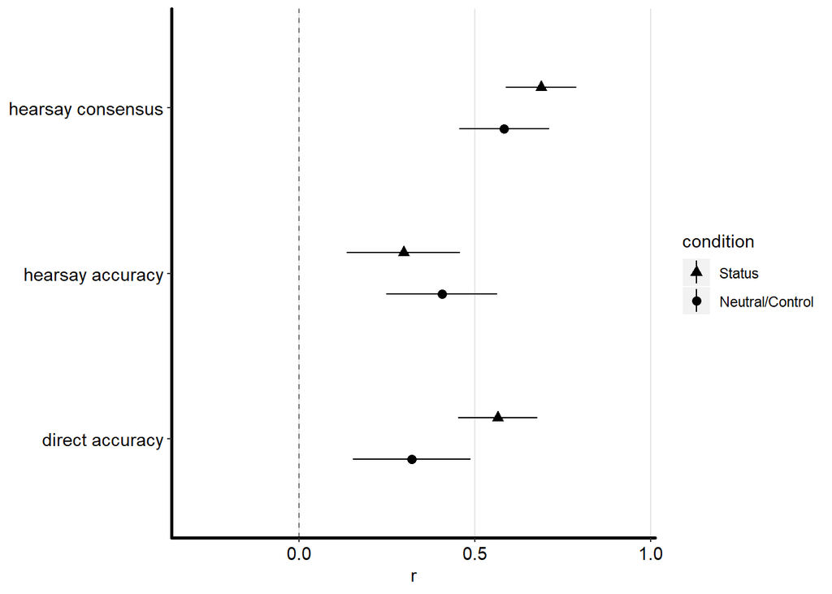

```r
extra_status_plot <- ez_differential_group_table(extra_status_noeq) %>%
  mutate(condition = case_when(group_label == "grp1" ~ "Affiliation",
  group_label == "grp2" ~ "Neutral/Control",
  group_label == "grp3" ~ "Status")) %>%
  filter(condition != "Affiliation") %>%
  ggplot(aes(x = parameter, y = r, shape = condition)) +
  geom_pointrange(aes(ymin = ci_lower, ymax = ci_upper), position = position_dodge(width = .5)) +
  theme_rep_manuscript +
  geom_hline(yintercept = 0, linetype = 2, alpha = .5) +
  scale_y_continuous(limit=c(-0.3, .95))+
  coord_flip()+
  guides(shape=guide_legend(reverse=TRUE)) +
  labs(x = NULL)
extra_status_plot
```

```r
ggsave("Plots/extraXCond.png",
       extra_status_plot,
       device = "png", height = 5, width = 9.5)
```

## Affiliation-relevant context and agreeableness

Next up, comparing hearsay consensus and accuracy for Agreeableness in the affiliation vs. control conditions.

```r
agree_affil_noeq <- rep_auto_group_mod(study2,
                                        p1_reports = c("A_C_agreeableness", "C_A_agreeableness"),
                                        p2_reports = c("B_C_agreeableness", "D_A_agreeableness"),
                                        target_self = c("C_C_agreeableness", "A_A_agreeableness"),
                                        group_mod = "condition",
                                        groups_eql = "none",
                                        params_eql = "none",
                                        use_labs = TRUE)

agree_affil_hceq <- rep_auto_group_mod(study2,
                                        p1_reports = c("A_C_agreeableness", "C_A_agreeableness"),
                                        p2_reports = c("B_C_agreeableness", "D_A_agreeableness"),
                                        target_self = c("C_C_agreeableness", "A_A_agreeableness"),
                                        group_mod = "condition",
                                        groups_eql = 1:2,
                                        params_eql = "hc",
                                        use_labs = TRUE)

agree_affil_haeq <- rep_auto_group_mod(study2,
                                        p1_reports = c("A_C_agreeableness", "C_A_agreeableness"),
                                        p2_reports = c("B_C_agreeableness", "D_A_agreeableness"),
                                        target_self = c("C_C_agreeableness", "A_A_agreeableness"),
                                        group_mod = "condition",
                                        groups_eql = 1:2,
                                        params_eql = c("ha"),
                                        use_labs = TRUE)

agree_affil_daeq <- rep_auto_group_mod(study2,
                                        p1_reports = c("A_C_agreeableness", "C_A_agreeableness"),
                                        p2_reports = c("B_C_agreeableness", "D_A_agreeableness"),
                                        target_self = c("C_C_agreeableness", "A_A_agreeableness"),
                                        group_mod = "condition",
                                        groups_eql = 1:2,
                                        params_eql = c("da"),
                                        use_labs = TRUE)
```

### Table of Model Comparison For Agreeableness across Conditions

```r
agree_affil_models <- c("agree_affil_hceq",
                         "agree_affil_haeq",
                         "agree_affil_daeq")
agree_affil_models %>%
  map(get) %>%
  map(anova, agree_affil_noeq) %>%
  map(as.data.frame) %>%
  map(mutate, delt_aic = AIC - lag(AIC) ,
         delt_bic = BIC - lag(BIC)) %>%
  map_df(slice, -1) %>%
  cbind(comparison = c("Hearsay Consensus Equal",
                       "Hearsay Accuracy Equal",
                       "Direct Accuracy Equal")) %>%
  select(comparison, 5:9) %>%
  rename(pvalue = `Pr(>Chisq)`) %>%
  mutate(comparison = as.character(comparison),
         comparison = ifelse(comparison == "Direct Accuracy Equal",
                             paste0(comparison, footnote_marker_alphabet(1)), comparison),
         pvalue = ifelse(pvalue >= .001,
                         str_pad(str_replace(round(pvalue, 3),
                                             "0.", "."), 4,
                                 side = "right", pad ="0"),
                         "< .001")) %>%
  knitr::kable(caption = "Model Comparison Results for Affiliation-Relevant Context and Agreeableness",
               digits = c(NA, 2, 0, NA, 2, 2),
               format = "html", escape = FALSE) %>%
  kable_styling("striped", full_width = F) %>%
  footnote(general = "Each Model is Compared to the Null Model",
           alphabet = "not pre-registered")
```

Model Comparison Results for Affiliation-Relevant Context and Agreeableness

| comparison | Chisq diff | Df diff | pvalue | delt_aic | delt_bic |
| --- | --- | --- | --- | --- | --- |
| Hearsay Consensus Equal | 0.56 | 1 | .454 | -1.44 | -4.68 |
| Hearsay Accuracy Equal | 2.21 | 1 | .137 | 0.21 | -3.03 |
| Direct Accuracy Equal<sup>a</sup> | 0.00 | 1 | .973 | -2.00 | -5.24 |

Note:  
Each Model is Compared to the Null Model  
<sup>a</sup> not pre-registered

### Table of Differential Agreement for Agreeableness by Condition

```r
ez_differential_group_table(agree_affil_noeq) %>%
  mutate(condition = case_when(
  group_label == "grp1" ~ "Affiliation",
  group_label == "grp2" ~ "Neutral/Control",
  group_label == "grp3" ~ "Status"
  ),
  pvalue = ifelse(pvalue >= .001,
                         str_pad(str_replace(round(pvalue, 3), "0.", "."), 4,
                                 side = "right", pad ="0"),
                         "< .001")) %>%
  select(condition, everything(), -group_label) %>%
  knitr::kable(caption = "Differential Results for Agreeableness Across Condition",
               digits = c(NA, NA, 2, 2, 2, 3),
               format = "html", escape = FALSE) %>%
  kable_styling("striped", full_width = F)
```

Differential Results for Agreeableness Across Condition

| condition | parameter | r | ci_lower | ci_upper | pvalue |
| --- | --- | --- | --- | --- | --- |
| Affiliation | hearsay consensus | 0.34 | 0.17 | 0.52 | < .001 |
| Affiliation | hearsay accuracy | 0.29 | 0.10 | 0.48 | .003 |
| Affiliation | direct accuracy | 0.17 | -0.01 | 0.35 | .067 |
| Neutral/Control | hearsay consensus | 0.46 | 0.31 | 0.61 | < .001 |
| Neutral/Control | hearsay accuracy | 0.03 | -0.19 | 0.25 | .818 |
| Neutral/Control | direct accuracy | 0.18 | 0.02 | 0.35 | .032 |
| Status | hearsay consensus | 0.23 | 0.04 | 0.42 | .017 |
| Status | hearsay accuracy | -0.25 | -0.44 | -0.06 | .010 |
| Status | direct accuracy | 0.17 | 0.01 | 0.34 | .041 |

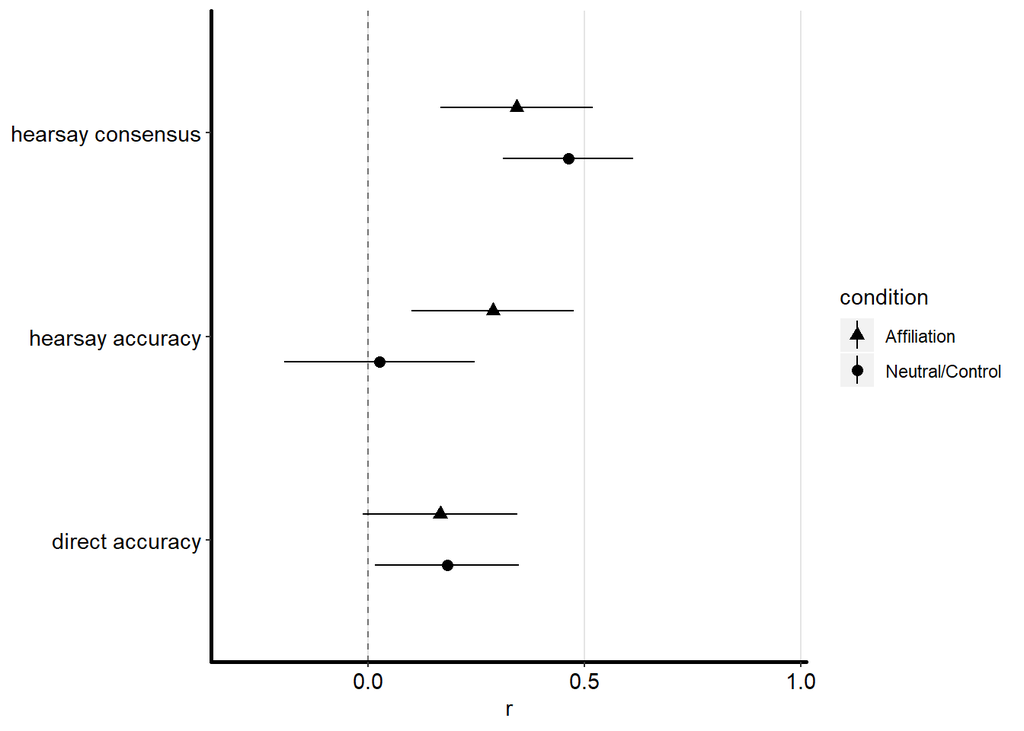

```r
agree_affil_plot <- ez_differential_group_table(agree_affil_noeq) %>%
  mutate(condition = case_when(group_label == "grp1" ~ "Affiliation",
  group_label == "grp2" ~ "Neutral/Control",
  group_label == "grp3" ~ "Status"),
  condition = fct_relevel(condition,
                                 "Neutral/Control",
                                 "Affiliation",
                                 "Status")) %>%
  filter(condition != "Status") %>%
  ggplot(aes(x = parameter, y = r, shape = condition)) +
  geom_pointrange(aes(ymin = ci_lower, ymax = ci_upper), position = position_dodge(width = .5)) +
  theme_rep_manuscript +
  geom_hline(yintercept = 0, linetype = 2, alpha = .5) +
  scale_y_continuous(limit=c(-0.3, .95))+
  coord_flip()+
  guides(shape=guide_legend(reverse=TRUE)) +
  labs(x = NULL)
agree_affil_plot
```

```r
ggsave("Plots/agreeXCond.png",
       agree_affil_plot,
       device = "png", height = 5, width = 9.5)
```

## Effects of reputation on leadership judgments

### Pre-registered Mediation Model: Extraversion to Leadership

This is a pre-registerd analysis looking at whether P1’s perception of thr target’s Extraversion influences P2’s perception of the target’s Extraversion, which in turn influences their perception of the target’s leadership potential. It was pre-registered as hypothesis 3 on OSF.

```r
extraversion_status_med_model_h3 <-'
# Model for A-B-C triad
B_C_contextitem_goodleader ~ b*B_C_extraversion + c*A_C_extraversion
B_C_extraversion ~ a*A_C_extraversion

# Model for C-D-A triad
D_A_contextitem_goodleader ~ b*D_A_extraversion + c*C_A_extraversion
D_A_extraversion ~ a*C_A_extraversion

# variances
B_C_contextitem_goodleader ~~ v_P2_gl*B_C_contextitem_goodleader
D_A_contextitem_goodleader ~~ v_P2_gl*D_A_contextitem_goodleader
B_C_extraversion ~~ v_P2*B_C_extraversion
D_A_extraversion ~~ v_P2*D_A_extraversion
A_C_extraversion ~~ v_P1*A_C_extraversion
C_A_extraversion ~~ v_P1*C_A_extraversion

# intercepts
B_C_contextitem_goodleader ~ int_P2_gl*1
D_A_contextitem_goodleader ~ int_P2_gl*1
B_C_extraversion ~ int_P2*1
D_A_extraversion ~ int_P2*1
A_C_extraversion ~ int_P1*1
C_A_extraversion ~ int_P1*1

# indirect (mediated) effect
indirecteffect := a*b
'
fit_extraversion_status_med_model_h3 <-sem(extraversion_status_med_model_h3,
                                            data = study2,
                                            missing="FIML",
                                            se="bootstrap",
                                            fixed.x=TRUE)

summary(fit_extraversion_status_med_model_h3)
```

```
## lavaan 0.6-4 ended normally after 23 iterations
##
##   Optimization method                           NLMINB
##   Number of free parameters                         19
##   Number of equality constraints                     9
##   Row rank of the constraints matrix                 9
##
##                                                   Used       Total
##   Number of observations                           189         195
##   Number of missing patterns                         3
##
##   Estimator                                         ML
##   Model Fit Test Statistic                      46.059
##   Degrees of freedom                                17
##   P-value (Chi-square)                           0.000
##
## Parameter Estimates:
##
##   Standard Errors                            Bootstrap
##   Number of requested bootstrap draws             1000
##   Number of successful bootstrap draws            1000
##
## Regressions:
##                                Estimate  Std.Err  z-value  P(>|z|)
##   B_C_contextitem_goodleader ~
##     B_C_xtrvrs (b)                0.772    0.111    6.958    0.000
##     A_C_xtrvrs (c)                0.043    0.102    0.418    0.676
##   B_C_extraversion ~
##     A_C_xtrvrs (a)                0.747    0.045   16.589    0.000
##   D_A_contextitem_goodleader ~
##     D_A_xtrvrs (b)                0.772    0.111    6.958    0.000
##     C_A_xtrvrs (c)                0.043    0.102    0.418    0.676
##   D_A_extraversion ~
##     C_A_xtrvrs (a)                0.747    0.045   16.589    0.000
##
## Covariances:
##                                 Estimate  Std.Err  z-value  P(>|z|)
##  .B_C_contextitem_goodleader ~~
##    .D_A_cntxttm_gd                -0.199    0.095   -2.103    0.035
##
## Intercepts:
##                    Estimate  Std.Err  z-value  P(>|z|)
##    .B_C_c_ (i_P2_)    0.927    0.247    3.758    0.000
##    .D_A_c_ (i_P2_)    0.927    0.247    3.758    0.000
##    .B_C_xt (in_P2)    0.820    0.153    5.377    0.000
##    .D_A_xt (in_P2)    0.820    0.153    5.377    0.000
##     A_C_xt  (i_P1)    3.213    0.035   91.422    0.000
##     C_A_xt  (i_P1)    3.213    0.035   91.422    0.000
##
## Variances:
##                    Estimate  Std.Err  z-value  P(>|z|)
##    .B_C_c_ (v_P2_)    0.955    0.079   12.053    0.000
##    .D_A_c_ (v_P2_)    0.955    0.079   12.053    0.000
##    .B_C_xt  (v_P2)    0.375    0.032   11.582    0.000
##    .D_A_xt  (v_P2)    0.375    0.032   11.582    0.000
##     A_C_xt  (v_P1)    0.511    0.034   14.984    0.000
##     C_A_xt  (v_P1)    0.511    0.034   14.984    0.000
##
## Defined Parameters:
##                    Estimate  Std.Err  z-value  P(>|z|)
##     indirecteffect    0.577    0.085    6.791    0.000
```

#### Table for Extraversion to Leadership Mediation model

```r
parameterestimates(fit_extraversion_status_med_model_h3) %>%
  as.data.frame() %>%
  filter(label == "a" |
         label == "b" |
         label == "c" |
         label == "indirecteffect") %>%
  rename(ci_upper = ci.upper,
         ci_lower = ci.lower) %>%
  mutate(parameter = case_when(label == "b" ~ "P2(T) Extraversion -> P2(T) Leadership",
                              label == "c" ~ "P1(T) Extraversion -> P2(T) Leadership",
                              label == "a" ~ "P1(T) Extraversion -> P2(T) Extraversion",
                              label == "indirecteffect" ~ "Mediated Effect"),
         label == fct_relevel(label,
                             "a",
                             "b",
                             "c"),
        pvalue = ifelse(pvalue >= .001,
                        str_pad(str_replace(round(pvalue, 3),
                                            "0.", "."), 4,
                                side = "right", pad ="0"),
                        "< .001"),
        est = round(est, 2),
        est = ifelse(str_detect(est, "\\..$"), paste0(est, "0"),
                   ifelse(str_detect(est, "^0$"), paste0(est, ".00"), est)),
        est = cell_spec(est, "html",
                            bold = ifelse(abs(z) > 1.96, TRUE, FALSE)),
        ci_lower = round(ci_lower, 2),
        ci_lower = ifelse(str_detect(ci_lower, "\\..$"), paste0(ci_lower, "0"),
                   ifelse(str_detect(ci_lower, "^0$"), paste0(ci_lower, ".00"), ci_lower)),
        ci_lower = cell_spec(ci_lower, "html",
                            bold = ifelse(abs(z) > 1.96, TRUE, FALSE)),
        ci_upper = round(ci_upper, 2),
        ci_upper = ifelse(str_detect(ci_upper, "\\..$"), paste0(ci_upper, "0"),
                   ifelse(str_detect(ci_upper, "^0$"), paste0(ci_upper, ".00"), ci_upper)),
        ci_upper = cell_spec(ci_upper, "html",
                            bold = ifelse(abs(z) > 1.96, TRUE, FALSE)),
        z = round(z, 2)) %>%
  arrange(label) %>%
  select(parameter, est, ci_lower, ci_upper, z, pvalue) %>%
  distinct() %>%
  knitr::kable(caption = "Extraversion and Leadership Mediation Results",
              format = "html", escape = F) %>%
 kable_styling("striped", full_width = F)
```

Extraversion and Leadership Mediation Results

| parameter | est | ci_lower | ci_upper | z | pvalue |
| --- | --- | --- | --- | --- | --- |
| P1(T) Extraversion -> P2(T) Extraversion | 0.75 | 0.65 | 0.83 | 16.59 | < .001 |
| P2(T) Extraversion -> P2(T) Leadership | 0.77 | 0.55 | 0.98 | 6.96 | < .001 |
| P1(T) Extraversion -> P2(T) Leadership | 0.04 | -0.15 | 0.25 | 0.42 | .676 |
| Mediated Effect | 0.58 | 0.42 | 0.74 | 6.79 | < .001 |

Our results are consistent with our hypothesis: P2’s perception of the target’s leadership is infleunced by their perception of the target’s Extraversion, which is in turn influenced by P1’s perception of the target’s Extraversion.

### Additional Model: All Big Six and Leadership

```r
big6_status_multi_med_model_h3alt <-'
# Model for A-B-C triad
B_C_contextitem_goodleader ~ b1*B_C_extraversion + b2*B_C_agreeableness + b3*B_C_conscientiousness + b4*B_C_neuroticism + b5*B_C_openness + b6*B_C_hp + c1*A_C_extraversion + c2*A_C_agreeableness + c3*A_C_conscientiousness + c4*A_C_neuroticism + c5*A_C_openness + c6*A_C_hp

B_C_extraversion      ~ a1*A_C_extraversion
B_C_agreeableness     ~ a2*A_C_agreeableness
B_C_conscientiousness ~ a3*A_C_conscientiousness
B_C_neuroticism       ~ a4*A_C_neuroticism
B_C_openness          ~ a5*A_C_openness
B_C_hp                ~ a6*A_C_hp

# Model for C-D-A triad
D_A_contextitem_goodleader ~ b1*D_A_extraversion + b2*D_A_agreeableness + b3*D_A_conscientiousness + b4*D_A_neuroticism + b5*D_A_openness + b6*D_A_hp + c1*C_A_extraversion + c2*C_A_agreeableness + c3*C_A_conscientiousness + c4*C_A_neuroticism + c5*C_A_openness + c6*C_A_hp

D_A_extraversion      ~ a1*C_A_extraversion
D_A_agreeableness     ~ a2*C_A_agreeableness
D_A_conscientiousness ~ a3*C_A_conscientiousness
D_A_neuroticism       ~ a4*C_A_neuroticism
D_A_openness          ~ a5*C_A_openness
D_A_hp                ~ a6*C_A_hp

# variances
B_C_contextitem_goodleader ~~ v_P2_gl*B_C_contextitem_goodleader
D_A_contextitem_goodleader ~~ v_P2_gl*D_A_contextitem_goodleader
B_C_extraversion ~~ v_P2_ex*B_C_extraversion
D_A_extraversion ~~ v_P2_ex*D_A_extraversion
B_C_agreeableness ~~ v_P2_ag*B_C_agreeableness
D_A_agreeableness ~~ v_P2_ag*D_A_agreeableness
B_C_conscientiousness ~~ v_P2_co*B_C_conscientiousness
D_A_conscientiousness ~~ v_P2_co*D_A_conscientiousness
B_C_neuroticism ~~ v_P2_ne*B_C_neuroticism
D_A_neuroticism ~~ v_P2_ne*D_A_neuroticism
B_C_openness ~~ v_P2_op*B_C_openness
D_A_openness ~~ v_P2_op*D_A_openness
B_C_hp ~~ v_P2_hp*B_C_hp
D_A_hp ~~ v_P2_hp*D_A_hp

A_C_extraversion ~~ v_P1_ex*A_C_extraversion
C_A_extraversion ~~ v_P1_ex*C_A_extraversion
A_C_agreeableness ~~ v_P1_ag*A_C_agreeableness
C_A_agreeableness ~~ v_P1_ag*C_A_agreeableness
A_C_conscientiousness ~~ v_P1_co*A_C_conscientiousness
C_A_conscientiousness ~~ v_P1_co*C_A_conscientiousness
A_C_neuroticism ~~ v_P1_ne*A_C_neuroticism
C_A_neuroticism ~~ v_P1_ne*C_A_neuroticism
A_C_openness ~~ v_P1_op*A_C_openness
C_A_openness ~~ v_P1_op*C_A_openness
A_C_hp ~~ v_P1_hp*A_C_hp
C_A_hp ~~ v_P1_hp*C_A_hp


# intercepts

B_C_contextitem_goodleader ~ int_P2_gl*1
D_A_contextitem_goodleader ~ int_P2_gl*1
B_C_extraversion ~ int_P2_ex*1
D_A_extraversion ~ int_P2_ex*1
B_C_agreeableness ~ int_P2_ag*1
D_A_agreeableness ~ int_P2_ag*1
B_C_conscientiousness ~ int_P2_co*1
D_A_conscientiousness ~ int_P2_co*1
B_C_neuroticism ~ int_P2_ne*1
D_A_neuroticism ~ int_P2_ne*1
B_C_openness ~ int_P2_op*1
D_A_openness ~ int_P2_op*1
B_C_hp ~ int_P2_hp*1
D_A_hp ~ int_P2_hp*1

A_C_extraversion ~ int_P1_ex*1
C_A_extraversion ~ int_P1_ex*1
A_C_agreeableness ~ int_P1_ag*1
C_A_agreeableness ~ int_P1_ag*1
A_C_conscientiousness ~ int_P1_co*1
C_A_conscientiousness ~ int_P1_co*1
A_C_neuroticism ~ int_P1_ne*1
C_A_neuroticism ~ int_P1_ne*1
A_C_openness ~ int_P1_op*1
C_A_openness ~ int_P1_op*1
A_C_hp ~ int_P1_hp*1
C_A_hp ~ int_P1_hp*1


# indirect (mediated) effect
indirect_ex := a1*b1
indirect_ag := a2*b2
indirect_co := a3*b3
indirect_ne := a4*b4
indirect_op := a5*b5
indirect_hp := a6*b6
'
fit_big6_status_multi_med_model_h3alt <-sem(big6_status_multi_med_model_h3alt,
                                            data = study2,
                                            missing = "FIML",
                                            se = "bootstrap",
                                            fixed.x = TRUE)

summary(fit_big6_status_multi_med_model_h3alt)
```

```
## lavaan 0.6-4 ended normally after 98 iterations
##
##   Optimization method                           NLMINB
##   Number of free parameters                         89
##   Number of equality constraints                    44
##   Row rank of the constraints matrix                44
##
##                                                   Used       Total
##   Number of observations                           189         195
##   Number of missing patterns                         3
##
##   Estimator                                         ML
##   Model Fit Test Statistic                    1783.248
##   Degrees of freedom                               332
##   P-value (Chi-square)                           0.000
##
## Parameter Estimates:
##
##   Standard Errors                            Bootstrap
##   Number of requested bootstrap draws             1000
##   Number of successful bootstrap draws            1000
##
## Regressions:
##                                Estimate  Std.Err  z-value  P(>|z|)
##   B_C_contextitem_goodleader ~
##     B_C_xtrvr (b1)                0.497    0.108    4.582    0.000
##     B_C_grbln (b2)               -0.330    0.168   -1.967    0.049
##     B_C_cnscn (b3)                0.621    0.145    4.287    0.000
##     B_C_nrtcs (b4)               -0.382    0.152   -2.508    0.012
##     B_C_pnnss (b5)                0.582    0.138    4.229    0.000
##     B_C_hp    (b6)               -0.205    0.179   -1.142    0.254
##     A_C_xtrvr (c1)                0.226    0.126    1.790    0.073
##     A_C_grbln (c2)                0.170    0.160    1.063    0.288
##     A_C_cnscn (c3)               -0.036    0.101   -0.352    0.725
##     A_C_nrtcs (c4)                0.202    0.134    1.505    0.132
##     A_C_pnnss (c5)               -0.095    0.092   -1.040    0.298
##     A_C_hp    (c6)                0.092    0.127    0.723    0.470
##   B_C_extraversion ~
##     A_C_xtrvr (a1)                0.747    0.046   16.185    0.000
##   B_C_agreeableness ~
```

[output cut: 91 more lines]

```
##     A_C_  (v_P1_n)    0.358    0.028   12.887    0.000
##     C_A_  (v_P1_n)    0.358    0.028   12.887    0.000
##     A_C_  (v_P1_p)    0.327    0.031   10.673    0.000
##     C_A_  (v_P1_p)    0.327    0.031   10.673    0.000
##     A_C_  (v_P1_h)    0.338    0.020   17.070    0.000
##     C_A_  (v_P1_h)    0.338    0.020   17.070    0.000
##
## Defined Parameters:
##                    Estimate  Std.Err  z-value  P(>|z|)
##     indirect_ex       0.371    0.082    4.533    0.000
##     indirect_ag      -0.113    0.061   -1.868    0.062
##     indirect_co       0.271    0.076    3.559    0.000
##     indirect_ne      -0.133    0.055   -2.398    0.017
##     indirect_op       0.103    0.034    3.013    0.003
##     indirect_hp      -0.065    0.056   -1.171    0.241
```

#### Table for Big Six to Leadership Mediation model

```r
parameterestimates(fit_big6_status_multi_med_model_h3alt) %>%
  as.data.frame() %>%
  filter(str_detect(label, "^a") |
         str_detect(label, "^b") |
         str_detect(label, "^c") |
         str_detect(label, "^indirect_")) %>%
  rename(ci_upper = ci.upper,
         ci_lower = ci.lower) %>%
  mutate(parameter = case_when(
    label == "a1" ~ "P1(T) Extraversion -> P2(T) Extraversion",
    label == "a2" ~ "P1(T) Agreeableness -> P2(T) Agreeableness",
    label == "a3" ~ "P1(T) Conscientiousness -> P2(T) Conscientiousness",
    label == "a4" ~ "P1(T) Neuroticism -> P2(T) Neuroticism",
    label == "a5" ~ "P1(T) Openness -> P2(T) Openness",
    label == "a6" ~ "P1(T) Honesty-Propriety -> P2(T) Honesty-Propriety",
    label == "b1" ~ "P2(T) Extraversion -> P2(T) Leadership",
    label == "b2" ~ "P2(T) Agreeableness -> P2(T) Leadership",
    label == "b3" ~ "P2(T) Conscientiousness -> P2(T) Leadership",
    label == "b4" ~ "P2(T) Neuroticism -> P2(T) Leadership",
    label == "b5" ~ "P2(T) Openness -> P2(T) Leadership",
    label == "b6" ~ "P2(T) Honesty-Propriety -> P2(T) Leadership",
    label == "c1" ~ "P1(T) Extraversion -> P2(T) Leadership",
    label == "c2" ~ "P1(T) Agreeableness -> P2(T) Leadership",
    label == "c3" ~ "P1(T) Conscientiousness -> P2(T) Leadership",
    label == "c4" ~ "P1(T) Neuroticism -> P2(T) Leadership",
    label == "c5" ~ "P1(T) Openness -> P2(T) Leadership",
    label == "c6" ~ "P1(T) Honesty-Propriety -> P2(T) Leadership",
    label == "indirect_ex" ~ "Indirect Extraversion",
    label == "indirect_ag" ~ "Indirect Agreeableness",
    label == "indirect_co" ~ "Indirect Conscientiousness",
    label == "indirect_ne" ~ "Indirect Neuroticism",
    label == "indirect_op" ~ "Indirect Openness ",
    label == "indirect_hp" ~ "Indirect Honesty-Propriety"),
    label = fct_relevel(label,
                             "a1",
                             "a2",
                             "a3",
                             "a4",
                             "a5",
                             "a6",
                             "b1",
                             "b2",
                             "b3",
                             "b4",
                             "b5",
                             "b6",
                             "c1",
                             "c2",
                             "c3",
                             "c4",
                             "c5",
                             "c6",
                             "indirect_ex",
                             "indirect_ag",
                             "indirect_co",
                             "indirect_ne",
                             "indirect_op",
                             "indirect_hp"),
        pvalue = ifelse(pvalue >= .001,
                        str_pad(str_replace(round(pvalue, 3),
                                            "0.", "."), 4,
                                side = "right", pad ="0"),
                        "< .001"),
        est = round(est, 2),
        est = ifelse(str_detect(est, "\\..$"), paste0(est, "0"),
                   ifelse(str_detect(est, "^0$"), paste0(est, ".00"), est)),
        est = cell_spec(est, "html",
                            bold = ifelse(abs(z) > 1.96, TRUE, FALSE)),
        ci_lower = round(ci_lower, 2),
        ci_lower = ifelse(str_detect(ci_lower, "\\..$"), paste0(ci_lower, "0"),
                   ifelse(str_detect(ci_lower, "^0$"), paste0(ci_lower, ".00"), ci_lower)),
        ci_lower = cell_spec(ci_lower, "html",
                            bold = ifelse(abs(z) > 1.96, TRUE, FALSE)),
        ci_upper = round(ci_upper, 2),
        ci_upper = ifelse(str_detect(ci_upper, "\\..$"), paste0(ci_upper, "0"),
                   ifelse(str_detect(ci_upper, "^0$"), paste0(ci_upper, ".00"), ci_upper)),
        ci_upper = cell_spec(ci_upper, "html",
                            bold = ifelse(abs(z) > 1.96, TRUE, FALSE)),
        z = round(z, 2)) %>%
  arrange(label) %>%
  select(parameter, est, ci_lower, ci_upper, z, pvalue) %>%
  distinct() %>%
  knitr::kable(caption = "All Big Six and Leadership Mediation Results",
              format = "html", escape = F) %>%
 kable_styling("striped", full_width = F) %>%
 pack_rows("Hearsay Consensus Path", 1, 6) %>%
 pack_rows("Hearsay Reputations of Big Six to Leadership", 7, 12) %>%
 pack_rows("Direct Reputations of Big Six to Hearsay Reputations of Leadership", 13, 18) %>%
 pack_rows("Indirect (Mediated) Effects", 19, 24)
```

All Big Six and Leadership Mediation Results

| parameter | est | ci_lower | ci_upper | z | pvalue |
| --- | --- | --- | --- | --- | --- |
| **Hearsay Consensus Path** |  |  |  |  |  |
| P1(T) Extraversion -> P2(T) Extraversion | 0.75 | 0.65 | 0.84 | 16.19 | < .001 |
| P1(T) Agreeableness -> P2(T) Agreeableness | 0.34 | 0.24 | 0.46 | 6.31 | < .001 |
| P1(T) Conscientiousness -> P2(T) Conscientiousness | 0.44 | 0.31 | 0.56 | 7.17 | < .001 |
| P1(T) Neuroticism -> P2(T) Neuroticism | 0.35 | 0.25 | 0.44 | 7.09 | < .001 |
| P1(T) Openness -> P2(T) Openness | 0.18 | 0.10 | 0.26 | 4.52 | < .001 |
| P1(T) Honesty-Propriety -> P2(T) Honesty-Propriety | 0.32 | 0.19 | 0.45 | 5.00 | < .001 |
| **Hearsay Reputations of Big Six to Leadership** |  |  |  |  |  |
| P2(T) Extraversion -> P2(T) Leadership | 0.50 | 0.29 | 0.71 | 4.58 | < .001 |
| P2(T) Agreeableness -> P2(T) Leadership | -0.33 | -0.65 | 0.02 | -1.97 | .049 |
| P2(T) Conscientiousness -> P2(T) Leadership | 0.62 | 0.35 | 0.90 | 4.29 | < .001 |
| P2(T) Neuroticism -> P2(T) Leadership | -0.38 | -0.68 | -0.08 | -2.51 | .012 |
| P2(T) Openness -> P2(T) Leadership | 0.58 | 0.32 | 0.86 | 4.23 | < .001 |
| P2(T) Honesty-Propriety -> P2(T) Leadership | -0.20 | -0.56 | 0.15 | -1.14 | .254 |
| **Direct Reputations of Big Six to Hearsay Reputations of Leadership** |  |  |  |  |  |
| P1(T) Extraversion -> P2(T) Leadership | 0.23 | -0.03 | 0.46 | 1.79 | .073 |
| P1(T) Agreeableness -> P2(T) Leadership | 0.17 | -0.15 | 0.47 | 1.06 | .288 |
| P1(T) Conscientiousness -> P2(T) Leadership | -0.04 | -0.24 | 0.15 | -0.35 | .725 |
| P1(T) Neuroticism -> P2(T) Leadership | 0.20 | -0.07 | 0.44 | 1.51 | .132 |
| P1(T) Openness -> P2(T) Leadership | -0.10 | -0.27 | 0.10 | -1.04 | .298 |
| P1(T) Honesty-Propriety -> P2(T) Leadership | 0.09 | -0.17 | 0.35 | 0.72 | .470 |
| **Indirect (Mediated) Effects** |  |  |  |  |  |
| Indirect Extraversion | 0.37 | 0.21 | 0.54 | 4.53 | < .001 |
| Indirect Agreeableness | -0.11 | -0.24 | 0.00 | -1.87 | .062 |
| Indirect Conscientiousness | 0.27 | 0.13 | 0.44 | 3.56 | < .001 |
| Indirect Neuroticism | -0.13 | -0.25 | -0.03 | -2.40 | .017 |
| Indirect Openness | 0.10 | 0.05 | 0.18 | 3.01 | .003 |
| Indirect Honesty-Propriety | -0.07 | -0.17 | 0.05 | -1.17 | .241 |

## Effects of reputation on friendship judgments.

### Pre-Registered Mediation Model: Agreeableness to Friendship

This is a pre-registerd analysis looking at whether P1’s perception of thr target’s Agreeableness influences P2’s perception of the target’s Agreeableness, which in turn influences their perception of the target’s friendship potential. It was pre-registered as hypothesis 4 on OSF.

```r
agreeableness_affil_med_model_h4 <-'
# Model for A-B-C triad
B_C_contextitem_goodfriend ~ b*B_C_agreeableness + c*A_C_agreeableness
B_C_agreeableness ~ a*A_C_agreeableness

# Model for C-D-A triad
D_A_contextitem_goodfriend ~ b*D_A_agreeableness + c*C_A_agreeableness
D_A_agreeableness ~ a*C_A_agreeableness

# variances
B_C_contextitem_goodfriend ~~ v_P2_gl*B_C_contextitem_goodfriend
D_A_contextitem_goodfriend ~~ v_P2_gl*D_A_contextitem_goodfriend
B_C_agreeableness ~~ v_P2*B_C_agreeableness
D_A_agreeableness ~~ v_P2*D_A_agreeableness
A_C_agreeableness ~~ v_P1*A_C_agreeableness
C_A_agreeableness ~~ v_P1*C_A_agreeableness

# intercepts
B_C_contextitem_goodfriend ~ int_P2_gl*1
D_A_contextitem_goodfriend ~ int_P2_gl*1
B_C_agreeableness ~ int_P2*1
D_A_agreeableness ~ int_P2*1
A_C_agreeableness ~ int_P1*1
C_A_agreeableness ~ int_P1*1

# indirect (mediated) effect
indirecteffect := a*b
'
fit_agreeableness_affil_med_model_h4 <-sem(agreeableness_affil_med_model_h4,
                                            data = study2,
                                            missing="FIML",
                                            se="bootstrap",
                                            fixed.x=TRUE)

summary(fit_agreeableness_affil_med_model_h4)
```

```
## lavaan 0.6-4 ended normally after 30 iterations
##
##   Optimization method                           NLMINB
##   Number of free parameters                         19
##   Number of equality constraints                     9
##   Row rank of the constraints matrix                 9
##
##                                                   Used       Total
##   Number of observations                           189         195
##   Number of missing patterns                         3
##
##   Estimator                                         ML
##   Model Fit Test Statistic                      16.451
##   Degrees of freedom                                17
##   P-value (Chi-square)                           0.492
##
## Parameter Estimates:
##
##   Standard Errors                            Bootstrap
##   Number of requested bootstrap draws             1000
##   Number of successful bootstrap draws            1000
##
## Regressions:
##                                Estimate  Std.Err  z-value  P(>|z|)
##   B_C_contextitem_goodfriend ~
##     B_C_grblns (b)                0.635    0.101    6.269    0.000
##     A_C_grblns (c)                0.009    0.070    0.134    0.893
##   B_C_agreeableness ~
##     A_C_grblns (a)                0.344    0.056    6.156    0.000
##   D_A_contextitem_goodfriend ~
##     D_A_grblns (b)                0.635    0.101    6.269    0.000
##     C_A_grblns (c)                0.009    0.070    0.134    0.893
##   D_A_agreeableness ~
##     C_A_grblns (a)                0.344    0.056    6.156    0.000
##
## Covariances:
##                                 Estimate  Std.Err  z-value  P(>|z|)
##  .B_C_contextitem_goodfriend ~~
##    .D_A_cntxttm_gd                 0.057    0.036    1.580    0.114
##
## Intercepts:
##                    Estimate  Std.Err  z-value  P(>|z|)
##    .B_C_c_ (i_P2_)    1.939    0.393    4.933    0.000
##    .D_A_c_ (i_P2_)    1.939    0.393    4.933    0.000
##    .B_C_gr (in_P2)    2.393    0.227   10.540    0.000
##    .D_A_gr (in_P2)    2.393    0.227   10.540    0.000
##     A_C_gr  (i_P1)    3.881    0.031  125.517    0.000
##     C_A_gr  (i_P1)    3.881    0.031  125.517    0.000
##
## Variances:
##                    Estimate  Std.Err  z-value  P(>|z|)
##    .B_C_c_ (v_P2_)    0.465    0.040   11.752    0.000
##    .D_A_c_ (v_P2_)    0.465    0.040   11.752    0.000
##    .B_C_gr  (v_P2)    0.269    0.023   11.692    0.000
##    .D_A_gr  (v_P2)    0.269    0.023   11.692    0.000
##     A_C_gr  (v_P1)    0.322    0.021   15.613    0.000
##     C_A_gr  (v_P1)    0.322    0.021   15.613    0.000
##
## Defined Parameters:
##                    Estimate  Std.Err  z-value  P(>|z|)
##     indirecteffect    0.219    0.042    5.224    0.000
```

#### Table for Agreeableness to Friendship Mediation model

```r
parameterestimates(fit_agreeableness_affil_med_model_h4) %>%
  as.data.frame() %>%
  filter(label == "a" |
         label == "b" |
         label == "c" |
         label == "indirecteffect") %>%
  rename(ci_upper = ci.upper,
         ci_lower = ci.lower) %>%
  mutate(parameter = case_when(label == "b" ~ "P2(T) Agreeableness -> P2(T) Friendship",
                              label == "c" ~ "P1(T) Agreeableness -> P2(T) Friendship",
                              label == "a" ~ "P1(T) Agreeableness -> P2(T) Agreeableness",
                              label == "indirecteffect" ~ "Mediated Effect"),
         label == fct_relevel(label,
                             "a",
                             "b",
                             "c"),
        pvalue = ifelse(pvalue >= .001,
                        str_pad(str_replace(round(pvalue, 3),
                                            "0.", "."), 4,
                                side = "right", pad ="0"),
                        "< .001"),
        est = round(est, 2),
        est = ifelse(str_detect(est, "\\..$"), paste0(est, "0"),
                   ifelse(str_detect(est, "^0$"), paste0(est, ".00"), est)),
        est = cell_spec(est, "html",
                            bold = ifelse(abs(z) > 1.96, TRUE, FALSE)),
        ci_lower = round(ci_lower, 2),
        ci_lower = ifelse(str_detect(ci_lower, "\\..$"), paste0(ci_lower, "0"),
                   ifelse(str_detect(ci_lower, "^0$"), paste0(ci_lower, ".00"), ci_lower)),
        ci_lower = cell_spec(ci_lower, "html",
                            bold = ifelse(abs(z) > 1.96, TRUE, FALSE)),
        ci_upper = round(ci_upper, 2),
        ci_upper = ifelse(str_detect(ci_upper, "\\..$"), paste0(ci_upper, "0"),
                   ifelse(str_detect(ci_upper, "^0$"), paste0(ci_upper, ".00"), ci_upper)),
        ci_upper = cell_spec(ci_upper, "html",
                            bold = ifelse(abs(z) > 1.96, TRUE, FALSE)),
        z = round(z, 2)) %>%
  arrange(label) %>%
  select(parameter, est, ci_lower, ci_upper, z, pvalue) %>%
  distinct() %>%
  knitr::kable(caption = "Agreeableness and Friendship Mediation Results",
              format = "html", escape = F) %>%
 kable_styling("striped", full_width = F)
```

Agreeableness and Friendship Mediation Results

| parameter | est | ci_lower | ci_upper | z | pvalue |
| --- | --- | --- | --- | --- | --- |
| P1(T) Agreeableness -> P2(T) Agreeableness | 0.34 | 0.24 | 0.46 | 6.16 | < .001 |
| P2(T) Agreeableness -> P2(T) Friendship | 0.63 | 0.44 | 0.84 | 6.27 | < .001 |
| P1(T) Agreeableness -> P2(T) Friendship | 0.01 | -0.13 | 0.14 | 0.13 | .893 |
| Mediated Effect | 0.22 | 0.14 | 0.30 | 5.22 | < .001 |

Looks like our results are consistent with our hypothesis: P2’s perception of the target’s friendship is infleunced by their perception of the target’s Agreeableness, which is in turn influenced by P1’s perception of the target’s Agreeableness.

### Alternative Model : All Big Six and Friendship

```r
big6_affil_multi_med_model_h3alt <-'
# Model for A-B-C triad
B_C_contextitem_goodfriend ~ b1*B_C_extraversion + b2*B_C_agreeableness + b3*B_C_conscientiousness + b4*B_C_neuroticism + b5*B_C_openness + b6*B_C_hp + c1*A_C_extraversion + c2*A_C_agreeableness + c3*A_C_conscientiousness + c4*A_C_neuroticism + c5*A_C_openness + c6*A_C_hp

B_C_extraversion      ~ a1*A_C_extraversion
B_C_agreeableness     ~ a2*A_C_agreeableness
B_C_conscientiousness ~ a3*A_C_conscientiousness
B_C_neuroticism       ~ a4*A_C_neuroticism
B_C_openness          ~ a5*A_C_openness
B_C_hp                ~ a6*A_C_hp

# Model for C-D-A triad
D_A_contextitem_goodfriend ~ b1*D_A_extraversion + b2*D_A_agreeableness + b3*D_A_conscientiousness + b4*D_A_neuroticism + b5*D_A_openness + b6*D_A_hp + c1*C_A_extraversion + c2*C_A_agreeableness + c3*C_A_conscientiousness + c4*C_A_neuroticism + c5*C_A_openness + c6*C_A_hp

D_A_extraversion      ~ a1*C_A_extraversion
D_A_agreeableness     ~ a2*C_A_agreeableness
D_A_conscientiousness ~ a3*C_A_conscientiousness
D_A_neuroticism       ~ a4*C_A_neuroticism
D_A_openness          ~ a5*C_A_openness
D_A_hp                ~ a6*C_A_hp

# variances
B_C_contextitem_goodfriend ~~ v_P2_gf*B_C_contextitem_goodfriend
D_A_contextitem_goodfriend ~~ v_P2_gf*D_A_contextitem_goodfriend
B_C_extraversion ~~ v_P2_ex*B_C_extraversion
D_A_extraversion ~~ v_P2_ex*D_A_extraversion
B_C_agreeableness ~~ v_P2_ag*B_C_agreeableness
D_A_agreeableness ~~ v_P2_ag*D_A_agreeableness
B_C_conscientiousness ~~ v_P2_co*B_C_conscientiousness
D_A_conscientiousness ~~ v_P2_co*D_A_conscientiousness
B_C_neuroticism ~~ v_P2_ne*B_C_neuroticism
D_A_neuroticism ~~ v_P2_ne*D_A_neuroticism
B_C_openness ~~ v_P2_op*B_C_openness
D_A_openness ~~ v_P2_op*D_A_openness
B_C_hp ~~ v_P2_hp*B_C_hp
D_A_hp ~~ v_P2_hp*D_A_hp

A_C_extraversion ~~ v_P1_ex*A_C_extraversion
C_A_extraversion ~~ v_P1_ex*C_A_extraversion
A_C_agreeableness ~~ v_P1_ag*A_C_agreeableness
C_A_agreeableness ~~ v_P1_ag*C_A_agreeableness
A_C_conscientiousness ~~ v_P1_co*A_C_conscientiousness
C_A_conscientiousness ~~ v_P1_co*C_A_conscientiousness
A_C_neuroticism ~~ v_P1_ne*A_C_neuroticism
C_A_neuroticism ~~ v_P1_ne*C_A_neuroticism
A_C_openness ~~ v_P1_op*A_C_openness
C_A_openness ~~ v_P1_op*C_A_openness
A_C_hp ~~ v_P1_hp*A_C_hp
C_A_hp ~~ v_P1_hp*C_A_hp


# intercepts

B_C_contextitem_goodfriend ~ int_P2_gf*1
D_A_contextitem_goodfriend ~ int_P2_gf*1
B_C_extraversion ~ int_P2_ex*1
D_A_extraversion ~ int_P2_ex*1
B_C_agreeableness ~ int_P2_ag*1
D_A_agreeableness ~ int_P2_ag*1
B_C_conscientiousness ~ int_P2_co*1
D_A_conscientiousness ~ int_P2_co*1
B_C_neuroticism ~ int_P2_ne*1
D_A_neuroticism ~ int_P2_ne*1
B_C_openness ~ int_P2_op*1
D_A_openness ~ int_P2_op*1
B_C_hp ~ int_P2_hp*1
D_A_hp ~ int_P2_hp*1

A_C_extraversion ~ int_P1_ex*1
C_A_extraversion ~ int_P1_ex*1
A_C_agreeableness ~ int_P1_ag*1
C_A_agreeableness ~ int_P1_ag*1
A_C_conscientiousness ~ int_P1_co*1
C_A_conscientiousness ~ int_P1_co*1
A_C_neuroticism ~ int_P1_ne*1
C_A_neuroticism ~ int_P1_ne*1
A_C_openness ~ int_P1_op*1
C_A_openness ~ int_P1_op*1
A_C_hp ~ int_P1_hp*1
C_A_hp ~ int_P1_hp*1


# indirect (mediated) effect
indirect_ex := a1*b1
indirect_ag := a2*b2
indirect_co := a3*b3
indirect_ne := a4*b4
indirect_op := a5*b5
indirect_hp := a6*b6
'
fit_big6_affil_multi_med_model_h3alt <-sem(big6_affil_multi_med_model_h3alt,
                                            data = study2,
                                            missing = "FIML",
                                            se = "bootstrap",
                                            fixed.x = TRUE)

summary(fit_big6_affil_multi_med_model_h3alt)
```

```
## lavaan 0.6-4 ended normally after 103 iterations
##
##   Optimization method                           NLMINB
##   Number of free parameters                         89
##   Number of equality constraints                    44
##   Row rank of the constraints matrix                44
##
##                                                   Used       Total
##   Number of observations                           189         195
##   Number of missing patterns                         3
##
##   Estimator                                         ML
##   Model Fit Test Statistic                    1774.303
##   Degrees of freedom                               332
##   P-value (Chi-square)                           0.000
##
## Parameter Estimates:
##
##   Standard Errors                            Bootstrap
##   Number of requested bootstrap draws             1000
##   Number of successful bootstrap draws            1000
##
## Regressions:
##                                Estimate  Std.Err  z-value  P(>|z|)
##   B_C_contextitem_goodfriend ~
##     B_C_xtrvr (b1)               -0.060    0.078   -0.762    0.446
##     B_C_grbln (b2)                0.425    0.111    3.839    0.000
##     B_C_cnscn (b3)                0.114    0.086    1.321    0.187
##     B_C_nrtcs (b4)               -0.135    0.102   -1.320    0.187
##     B_C_pnnss (b5)               -0.191    0.111   -1.723    0.085
##     B_C_hp    (b6)                0.300    0.104    2.882    0.004
##     A_C_xtrvr (c1)                0.276    0.094    2.938    0.003
##     A_C_grbln (c2)                0.119    0.113    1.058    0.290
##     A_C_cnscn (c3)               -0.148    0.093   -1.583    0.113
##     A_C_nrtcs (c4)                0.159    0.088    1.800    0.072
##     A_C_pnnss (c5)               -0.098    0.077   -1.263    0.207
##     A_C_hp    (c6)                0.072    0.126    0.567    0.571
##   B_C_extraversion ~
##     A_C_xtrvr (a1)                0.747    0.048   15.466    0.000
##   B_C_agreeableness ~
```

[output cut: 91 more lines]

```
##     A_C_  (v_P1_n)    0.358    0.025   14.176    0.000
##     C_A_  (v_P1_n)    0.358    0.025   14.176    0.000
##     A_C_  (v_P1_p)    0.327    0.032   10.299    0.000
##     C_A_  (v_P1_p)    0.327    0.032   10.299    0.000
##     A_C_  (v_P1_h)    0.338    0.021   16.173    0.000
##     C_A_  (v_P1_h)    0.338    0.021   16.173    0.000
##
## Defined Parameters:
##                    Estimate  Std.Err  z-value  P(>|z|)
##     indirect_ex      -0.044    0.058   -0.765    0.444
##     indirect_ag       0.146    0.041    3.572    0.000
##     indirect_co       0.050    0.039    1.274    0.203
##     indirect_ne      -0.047    0.035   -1.326    0.185
##     indirect_op      -0.034    0.022   -1.565    0.118
##     indirect_hp       0.095    0.040    2.375    0.018
```

#### Table for Big Six to Friendship Mediation model

```r
parameterestimates(fit_big6_affil_multi_med_model_h3alt) %>%
  as.data.frame() %>%
  filter(str_detect(label, "^a") |
         str_detect(label, "^b") |
         str_detect(label, "^c") |
         str_detect(label, "^indirect_")) %>%
  rename(ci_upper = ci.upper,
         ci_lower = ci.lower) %>%
  mutate(parameter = case_when(
    label == "a1" ~ "P1(T) Extraversion -> P2(T) Extraversion",
    label == "a2" ~ "P1(T) Agreeableness -> P2(T) Agreeableness",
    label == "a3" ~ "P1(T) Conscientiousness -> P2(T) Conscientiousness",
    label == "a4" ~ "P1(T) Neuroticism -> P2(T) Neuroticism",
    label == "a5" ~ "P1(T) Openness -> P2(T) Openness",
    label == "a6" ~ "P1(T) Honesty-Propriety -> P2(T) Honesty-Propriety",
    label == "b1" ~ "P2(T) Extraversion -> P2(T) Friendship",
    label == "b2" ~ "P2(T) Agreeableness -> P2(T) Friendship",
    label == "b3" ~ "P2(T) Conscientiousness -> P2(T) Friendship",
    label == "b4" ~ "P2(T) Neuroticism -> P2(T) Friendship",
    label == "b5" ~ "P2(T) Openness -> P2(T) Friendship",
    label == "b6" ~ "P2(T) Honesty-Propriety -> P2(T) Friendship",
    label == "c1" ~ "P1(T) Extraversion -> P2(T) Friendship",
    label == "c2" ~ "P1(T) Agreeableness -> P2(T) Friendship",
    label == "c3" ~ "P1(T) Conscientiousness -> P2(T) Friendship",
    label == "c4" ~ "P1(T) Neuroticism -> P2(T) Friendship",
    label == "c5" ~ "P1(T) Openness -> P2(T) Friendship",
    label == "c6" ~ "P1(T) Honesty-Propriety -> P2(T) Friendship",
    label == "indirect_ex" ~ "Indirect Extraversion",
    label == "indirect_ag" ~ "Indirect Agreeableness",
    label == "indirect_co" ~ "Indirect Conscientiousness",
    label == "indirect_ne" ~ "Indirect Neuroticism",
    label == "indirect_op" ~ "Indirect Openness ",
    label == "indirect_hp" ~ "Indirect Honesty-Propriety"),
    label = fct_relevel(label,
                             "a1",
                             "a2",
                             "a3",
                             "a4",
                             "a5",
                             "a6",
                             "b1",
                             "b2",
                             "b3",
                             "b4",
                             "b5",
                             "b6",
                             "c1",
                             "c2",
                             "c3",
                             "c4",
                             "c5",
                             "c6",
                             "indirect_ex",
                             "indirect_ag",
                             "indirect_co",
                             "indirect_ne",
                             "indirect_op",
                             "indirect_hp"),
        pvalue = ifelse(pvalue >= .001,
                        str_pad(str_replace(round(pvalue, 3),
                                            "0.", "."), 4,
                                side = "right", pad ="0"),
                        "< .001"),
        est = round(est, 2),
        est = ifelse(str_detect(est, "\\..$"), paste0(est, "0"),
                   ifelse(str_detect(est, "^0$"), paste0(est, ".00"), est)),
        est = cell_spec(est, "html",
                            bold = ifelse(abs(z) > 1.96, TRUE, FALSE)),
        ci_lower = round(ci_lower, 2),
        ci_lower = ifelse(str_detect(ci_lower, "\\..$"), paste0(ci_lower, "0"),
                   ifelse(str_detect(ci_lower, "^0$"), paste0(ci_lower, ".00"), ci_lower)),
        ci_lower = cell_spec(ci_lower, "html",
                            bold = ifelse(abs(z) > 1.96, TRUE, FALSE)),
        ci_upper = round(ci_upper, 2),
        ci_upper = ifelse(str_detect(ci_upper, "\\..$"), paste0(ci_upper, "0"),
                   ifelse(str_detect(ci_upper, "^0$"), paste0(ci_upper, ".00"), ci_upper)),
        ci_upper = cell_spec(ci_upper, "html",
                            bold = ifelse(abs(z) > 1.96, TRUE, FALSE)),
        z = round(z, 2)) %>%
  arrange(label) %>%
  select(parameter, est, ci_lower, ci_upper, z, pvalue) %>%
  distinct() %>%
  knitr::kable(caption = "All Big Six and Friendship Mediation Results",
              format = "html", escape = F) %>%
 kable_styling("striped", full_width = F) %>%
 pack_rows("Hearsay Consensus Path", 1, 6) %>%
 pack_rows("Hearsay Reputations of Big Six to Friendship", 7, 12) %>%
 pack_rows("Direct Reputations of Big Six to Hearsay Reputations of Friendship", 13, 18) %>%
 pack_rows("Indirect (Mediated) Effects", 19, 24)
```

All Big Six and Friendship Mediation Results

| parameter | est | ci_lower | ci_upper | z | pvalue |
| --- | --- | --- | --- | --- | --- |
| **Hearsay Consensus Path** |  |  |  |  |  |
| P1(T) Extraversion -> P2(T) Extraversion | 0.75 | 0.65 | 0.85 | 15.47 | < .001 |
| P1(T) Agreeableness -> P2(T) Agreeableness | 0.34 | 0.23 | 0.45 | 6.01 | < .001 |
| P1(T) Conscientiousness -> P2(T) Conscientiousness | 0.44 | 0.33 | 0.56 | 7.40 | < .001 |
| P1(T) Neuroticism -> P2(T) Neuroticism | 0.35 | 0.24 | 0.44 | 6.76 | < .001 |
| P1(T) Openness -> P2(T) Openness | 0.18 | 0.10 | 0.25 | 4.65 | < .001 |
| P1(T) Honesty-Propriety -> P2(T) Honesty-Propriety | 0.32 | 0.19 | 0.44 | 5.06 | < .001 |
| **Hearsay Reputations of Big Six to Friendship** |  |  |  |  |  |
| P2(T) Extraversion -> P2(T) Friendship | -0.06 | -0.21 | 0.10 | -0.76 | .446 |
| P2(T) Agreeableness -> P2(T) Friendship | 0.43 | 0.21 | 0.64 | 3.84 | < .001 |
| P2(T) Conscientiousness -> P2(T) Friendship | 0.11 | -0.07 | 0.28 | 1.32 | .187 |
| P2(T) Neuroticism -> P2(T) Friendship | -0.14 | -0.36 | 0.06 | -1.32 | .187 |
| P2(T) Openness -> P2(T) Friendship | -0.19 | -0.40 | 0.03 | -1.72 | .085 |
| P2(T) Honesty-Propriety -> P2(T) Friendship | 0.30 | 0.10 | 0.50 | 2.88 | .004 |
| **Direct Reputations of Big Six to Hearsay Reputations of Friendship** |  |  |  |  |  |
| P1(T) Extraversion -> P2(T) Friendship | 0.28 | 0.08 | 0.46 | 2.94 | .003 |
| P1(T) Agreeableness -> P2(T) Friendship | 0.12 | -0.12 | 0.34 | 1.06 | .290 |
| P1(T) Conscientiousness -> P2(T) Friendship | -0.15 | -0.34 | 0.03 | -1.58 | .113 |
| P1(T) Neuroticism -> P2(T) Friendship | 0.16 | -0.02 | 0.33 | 1.80 | .072 |
| P1(T) Openness -> P2(T) Friendship | -0.10 | -0.25 | 0.07 | -1.26 | .207 |
| P1(T) Honesty-Propriety -> P2(T) Friendship | 0.07 | -0.17 | 0.33 | 0.57 | .571 |
| **Indirect (Mediated) Effects** |  |  |  |  |  |
| Indirect Extraversion | -0.04 | -0.15 | 0.08 | -0.77 | .444 |
| Indirect Agreeableness | 0.15 | 0.07 | 0.23 | 3.57 | < .001 |
| Indirect Conscientiousness | 0.05 | -0.03 | 0.12 | 1.27 | .203 |
| Indirect Neuroticism | -0.05 | -0.12 | 0.02 | -1.33 | .185 |
| Indirect Openness | -0.03 | -0.08 | 0.00 | -1.56 | .118 |
| Indirect Honesty-Propriety | 0.10 | 0.03 | 0.18 | 2.37 | .018 |

## Model Comparisons to Assess Justifiability of Pooling across Studies

### Agreeableness

```r
agree_integrated_noeq <- rep_auto_group_mod(integrated,
                                        p1_reports = c("A_C_agreeableness", "C_A_agreeableness"),
                                        p2_reports = c("B_C_agreeableness", "D_A_agreeableness"),
                                        target_self = c("C_C_agreeableness", "A_A_agreeableness"),
                                        group_mod = "study",
                                        groups_eql = "none",
                                        params_eql = "none",
                                        use_labs = TRUE)

agree_integrated_alleq <- rep_auto_group_mod(integrated,
                                        p1_reports = c("A_C_agreeableness", "C_A_agreeableness"),
                                        p2_reports = c("B_C_agreeableness", "D_A_agreeableness"),
                                        target_self = c("C_C_agreeableness", "A_A_agreeableness"),
                                        group_mod = "study",
                                        groups_eql = "all",
                                        params_eql = "all",
                                        use_labs = TRUE)

int_model_comp_agree <- anova(agree_integrated_noeq,
                              agree_integrated_alleq)
```

### Conscientiousness

```r
consc_integrated_noeq <- rep_auto_group_mod(integrated,
                                        p1_reports = c("A_C_conscientiousness", "C_A_conscientiousness"),
                                        p2_reports = c("B_C_conscientiousness", "D_A_conscientiousness"),
                                        target_self = c("C_C_conscientiousness", "A_A_conscientiousness"),
                                        group_mod = "study",
                                        groups_eql = "none",
                                        params_eql = "none",
                                        use_labs = TRUE)

consc_integrated_alleq <- rep_auto_group_mod(integrated,
                                        p1_reports = c("A_C_conscientiousness", "C_A_conscientiousness"),
                                        p2_reports = c("B_C_conscientiousness", "D_A_conscientiousness"),
                                        target_self = c("C_C_conscientiousness", "A_A_conscientiousness"),
                                        group_mod = "study",
                                        groups_eql = "all",
                                        params_eql = "all",
                                        use_labs = TRUE)
int_model_comp_consc <- anova(consc_integrated_noeq,
                              consc_integrated_alleq)
```

### Honesty-Propriety

```r
hp_integrated_noeq <- rep_auto_group_mod(integrated,
                                        p1_reports = c("A_C_hp", "C_A_hp"),
                                        p2_reports = c("B_C_hp", "D_A_hp"),
                                        target_self = c("C_C_hp", "A_A_hp"),
                                        group_mod = "study",
                                        groups_eql = "none",
                                        params_eql = "none",
                                        use_labs = TRUE)

hp_integrated_alleq <- rep_auto_group_mod(integrated,
                                        p1_reports = c("A_C_hp", "C_A_hp"),
                                        p2_reports = c("B_C_hp", "D_A_hp"),
                                        target_self = c("C_C_hp", "A_A_hp"),
                                        group_mod = "study",
                                        groups_eql = "all",
                                        params_eql = "all",
                                        use_labs = TRUE)

int_model_comp_hp <- anova(hp_integrated_noeq,
                           hp_integrated_alleq)
```

### Neuroticism

```r
neuro_integrated_noeq <- rep_auto_group_mod(integrated,
                                        p1_reports = c("A_C_neuroticism", "C_A_neuroticism"),
                                        p2_reports = c("B_C_neuroticism", "D_A_neuroticism"),
                                        target_self = c("C_C_neuroticism", "A_A_neuroticism"),
                                        group_mod = "study",
                                        groups_eql = "none",
                                        params_eql = "none",
                                        use_labs = TRUE)

neuro_integrated_alleq <- rep_auto_group_mod(integrated,
                                        p1_reports = c("A_C_neuroticism", "C_A_neuroticism"),
                                        p2_reports = c("B_C_neuroticism", "D_A_neuroticism"),
                                        target_self = c("C_C_neuroticism", "A_A_neuroticism"),
                                        group_mod = "study",
                                        groups_eql = "all",
                                        params_eql = "all",
                                        use_labs = TRUE)

int_model_comp_neuro <- anova(neuro_integrated_noeq,
                              neuro_integrated_alleq)
```

### Extraversion

```r
extra_integrated_noeq <- rep_auto_group_mod(integrated,
                                        p1_reports = c("A_C_extraversion", "C_A_extraversion"),
                                        p2_reports = c("B_C_extraversion", "D_A_extraversion"),
                                        target_self = c("C_C_extraversion", "A_A_extraversion"),
                                        group_mod = "study",
                                        groups_eql = "none",
                                        params_eql = "none",
                                        use_labs = TRUE)

extra_integrated_alleq <- rep_auto_group_mod(integrated,
                                        p1_reports = c("A_C_extraversion", "C_A_extraversion"),
                                        p2_reports = c("B_C_extraversion", "D_A_extraversion"),
                                        target_self = c("C_C_extraversion", "A_A_extraversion"),
                                        group_mod = "study",
                                        groups_eql = "all",
                                        params_eql = "all",
                                        use_labs = TRUE)
int_model_comp_extra <- anova(extra_integrated_noeq,
                              extra_integrated_alleq)
```

### Openness

```r
open_integrated_noeq <- rep_auto_group_mod(integrated,
                                        p1_reports = c("A_C_openness", "C_A_openness"),
                                        p2_reports = c("B_C_openness", "D_A_openness"),
                                        target_self = c("C_C_openness", "A_A_openness"),
                                        group_mod = "study",
                                        groups_eql = "none",
                                        params_eql = "none",
                                        use_labs = TRUE)

open_integrated_alleq <- rep_auto_group_mod(integrated,
                                        p1_reports = c("A_C_openness", "C_A_openness"),
                                        p2_reports = c("B_C_openness", "D_A_openness"),
                                        target_self = c("C_C_openness", "A_A_openness"),
                                        group_mod = "study",
                                        groups_eql = "all",
                                        params_eql = "all",
                                        use_labs = TRUE)

int_model_comp_open <- anova(open_integrated_noeq,
                             open_integrated_alleq)
```

### Table of Comparisons

```r
model_comp_domains <- ls()[str_detect(ls(), "int_model_comp")] %>%
  str_split("_") %>%
  sapply(., function(df, position){df[position]}, 4)

ls()[str_detect(ls(), "int_model_comp")] %>%
  lapply(FUN = get) %>%
  map(mutate, delt_aic = AIC - lag(AIC) ,
         delt_bic = BIC - lag(BIC) ) %>%
  map_df(slice, -1) %>%
  rename(pvalue = `Pr(>Chisq)`) %>%
  mutate(pvalue = ifelse(pvalue >= .001,
                         str_pad(str_replace(round(pvalue, 3), "0.", "."), 4, side = "right", pad ="0"),
                         "< .001"),
         domain = model_comp_domains,
         domain = case_when(domain == "agree" ~ "Agreeableness",
                            domain == "consc" ~ "Conscientiousness",
                            domain == "hp" ~ "Honesty-Propriety",
                            domain == "neuro" ~ "Neuroticism",
                            domain == "extra" ~ "Extraversion",
                            domain == "open" ~ "Openness"),
         domain = fct_relevel(domain,
                              "Agreeableness",
                              "Conscientiousness",
                              "Honesty-Propriety",
                              "Neuroticism",
                              "Extraversion",
                              "Openness")) %>%
  arrange(domain) %>%
  select(domain, `Df diff`, `Chisq diff`, pvalue, delt_aic, delt_bic) %>%
  knitr::kable(caption = "Model Comparison Results for Integrating across Studies",
               digits = c(NA, 0, 2, 3, 2, 2),
               format = "html", escape = FALSE) %>%
  kable_styling("striped", full_width = F)
```

Model Comparison Results for Integrating across Studies

| domain | Df diff | Chisq diff | pvalue | delt_aic | delt_bic |
| --- | --- | --- | --- | --- | --- |
| Agreeableness | 15 | 22.19 | .103 | -7.81 | -63.90 |
| Conscientiousness | 15 | 41.08 | < .001 | 11.08 | -45.01 |
| Honesty-Propriety | 15 | 27.86 | .022 | -2.14 | -58.23 |
| Neuroticism | 15 | 44.43 | < .001 | 14.43 | -41.67 |
| Extraversion | 15 | 15.82 | .394 | -14.18 | -70.28 |
| Openness | 15 | 31.58 | .007 | 1.58 | -54.52 |

## Study 2 & Integrated Relative elevation

```r
int_model_names <- ls()[str_detect(ls(), "integrated_[:alpha:]*eq$")]

int_model_domain <- int_model_names %>%
  str_extract("[:alpha:]*")

int_rel_el_tables <-
  int_model_names %>%
  map(get) %>%
  map(ez_elevation_group_table) %>%
  enframe() %>%
  mutate(name = int_model_names) %>%
  unnest() %>%
  separate(name, c("domain", "temp1", "temp2")) %>%
  select(-temp1, -temp2) %>%
  mutate(domain = case_when(domain == "agree" ~ "Agreeableness",
                            domain == "consc" ~ "Conscientiousness",
                            domain == "hp" ~ "Honesty-Propriety",
                            domain == "neuro" ~ "Neuroticism",
                            domain == "extra" ~ "Extraversion",
                            domain == "open" ~ "Openness"),
         tbl = rep(c("elevation_table", "pooled_m_sd"), 12)) %>%
    split(.$tbl) %>%
    map(unnest) %>%
    map(mutate, group_label = case_when(
      group_label == "eql" ~ "Integrated",
      group_label == "grp1" ~ "Study 1",
      group_label == "grp2" ~ "Study 2"
    )) %>%
    map(mutate, domain = fct_relevel(domain,
                       "Agreeableness",
                       "Conscientiousness",
                       "Honesty-Propriety",
                       "Neuroticism",
                       "Extraversion",
                       "Openness")) %>%
    map(mutate, study = fct_relevel(group_label,
                                          "Study 1",
                                          "Study 2",
                                          "Integrated")) %>%
    map(arrange, domain, group_label) %>%
    map(select, study, everything(), -tbl, -group_label)
```

### Study 2 & Integrated Elevation Table

And now a table of the elevation results from the Study 2 and the integrated model, like Table 3 in the manuscript.

```r
int_rel_el_tables[[1]] %>%
  arrange(parameter) %>%
  mutate(pvalue = ifelse(pvalue >= .001,
                         str_pad(str_replace(round(pvalue, 3), "0.", "."), 4, side = "right", pad ="0"),
                         "< .001"),
         raw_diff = round(raw_diff, 2),
         raw_diff = ifelse(str_detect(raw_diff, "\\..$"), paste0(raw_diff, "0"),
                    ifelse(str_detect(raw_diff, "^0$"), paste0(raw_diff, ".00"), raw_diff)),
         raw_diff = cell_spec(raw_diff, "html",
                              color = ifelse(raw_diff < 0, "red", "blue"),
                               bold = ifelse(abs(z) >= 1.96, TRUE, FALSE)),
         ci_upper = round(ci_upper, 2),
         ci_upper = ifelse(str_detect(ci_upper, "\\..$"), paste0(ci_upper, "0"),
                    ifelse(str_detect(ci_upper, "^0$"), paste0(ci_upper, ".00"), ci_upper)),
         ci_upper = cell_spec(ci_upper, "html",
                              color = ifelse(ci_upper < 0, "red", "blue"),
                              bold = ifelse(abs(z) >= 1.96, TRUE, FALSE)),
         ci_lower = round(ci_lower, 2),
         ci_lower = ifelse(str_detect(ci_lower, "\\..$"), paste0(ci_lower, "0"),
                    ifelse(str_detect(ci_lower, "^0$"), paste0(ci_lower, ".00"), ci_lower)),
         ci_lower = cell_spec(ci_lower, "html",
                              color = ifelse(ci_lower < 0, "red", "blue"),
                              bold = ifelse(abs(z) >= 1.96, TRUE, FALSE)),
         cohen_d = round(cohen_d, 2),
         cohen_d = ifelse(str_detect(cohen_d, "\\..$"), paste0(cohen_d, "0"),
                    ifelse(str_detect(cohen_d, "^0$"), paste0(cohen_d, ".00"), cohen_d)),
         cohen_d = cell_spec(cohen_d, "html",
                             color = ifelse(cohen_d < 0, "red", "blue"),
                             bold = ifelse(abs(z) >= 1.96, TRUE, FALSE)),
         z = round(z, 2)) %>%
  arrange(desc(study)) %>%
  filter(study != "Study 1") %>%
  select(-study) %>%
  knitr::kable(caption = "Integrated Relative Elevation Results",
               format = "html", escape = F) %>%
  kable_styling("striped", full_width = F) %>%
  footnote(general = "Blue = Positive Difference; Red = Negative Difference; bold = p < .05") %>%
  pack_rows("Integrated", 1, 18) %>%
  pack_rows("Study 2", 19, 36)
```

Integrated Relative Elevation Results

| domain | parameter | raw_diff | ci_lower | ci_upper | cohen_d | z | pvalue |
| --- | --- | --- | --- | --- | --- | --- | --- |
| **Integrated** |  |  |  |  |  |  |  |
| Agreeableness | P1-P2 Relative Elevation | 0.20 | 0.14 | 0.26 | 0.36 | 6.88 | < .001 |
| Conscientiousness | P1-P2 Relative Elevation | 0.04 | -0.02 | 0.09 | 0.06 | 1.17 | .242 |
| Honesty-Propriety | P1-P2 Relative Elevation | 0.25 | 0.20 | 0.31 | 0.46 | 9.07 | < .001 |
| Neuroticism | P1-P2 Relative Elevation | -0.13 | -0.18 | -0.08 | -0.23 | -5.35 | < .001 |
| Extraversion | P1-P2 Relative Elevation | -0.02 | -0.08 | 0.04 | -0.03 | -0.67 | .502 |
| Openness | P1-P2 Relative Elevation | 0.12 | 0.07 | 0.17 | 0.24 | 4.59 | < .001 |
| Agreeableness | Self-P1 Relative Elevation | -0.04 | -0.09 | 0.01 | -0.07 | -1.56 | .119 |
| Conscientiousness | Self-P1 Relative Elevation | -0.15 | -0.20 | -0.10 | -0.25 | -5.60 | < .001 |
| Honesty-Propriety | Self-P1 Relative Elevation | -0.04 | -0.09 | 0.01 | -0.07 | -1.49 | .136 |
| Neuroticism | Self-P1 Relative Elevation | 0.32 | 0.26 | 0.39 | 0.46 | 9.56 | < .001 |
| Extraversion | Self-P1 Relative Elevation | 0.16 | 0.10 | 0.22 | 0.22 | 5.39 | < .001 |
| Openness | Self-P1 Relative Elevation | 0.36 | 0.31 | 0.41 | 0.66 | 14.10 | < .001 |
| Agreeableness | Self-P2 Relative Elevation | 0.16 | 0.10 | 0.22 | 0.29 | 5.17 | < .001 |
| Conscientiousness | Self-P2 Relative Elevation | -0.12 | -0.19 | -0.05 | -0.18 | -3.32 | < .001 |
| Honesty-Propriety | Self-P2 Relative Elevation | 0.21 | 0.15 | 0.27 | 0.38 | 7.03 | < .001 |
| Neuroticism | Self-P2 Relative Elevation | 0.19 | 0.12 | 0.26 | 0.28 | 5.13 | < .001 |
| Extraversion | Self-P2 Relative Elevation | 0.14 | 0.07 | 0.22 | 0.19 | 3.92 | < .001 |
| Openness | Self-P2 Relative Elevation | 0.48 | 0.42 | 0.53 | 0.94 | 17.86 | < .001 |
| **Study 2** |  |  |  |  |  |  |  |
| Agreeableness | P1-P2 Relative Elevation | 0.15 | 0.08 | 0.22 | 0.27 | 3.95 | < .001 |
| Conscientiousness | P1-P2 Relative Elevation | -0.03 | -0.10 | 0.04 | -0.04 | -0.75 | .452 |
| Honesty-Propriety | P1-P2 Relative Elevation | 0.18 | 0.11 | 0.25 | 0.32 | 5.05 | < .001 |
| Neuroticism | P1-P2 Relative Elevation | -0.08 | -0.15 | -0.02 | -0.15 | -2.57 | .010 |
| Extraversion | P1-P2 Relative Elevation | 0.00 | -0.07 | 0.07 | 0.00 | -0.01 | .992 |
| Openness | P1-P2 Relative Elevation | 0.10 | 0.04 | 0.17 | 0.20 | 3.02 | .003 |
| Agreeableness | Self-P1 Relative Elevation | 0.00 | -0.06 | 0.06 | 0.00 | -0.07 | .945 |
| Conscientiousness | Self-P1 Relative Elevation | -0.14 | -0.21 | -0.07 | -0.22 | -4.02 | < .001 |
| Honesty-Propriety | Self-P1 Relative Elevation | -0.03 | -0.10 | 0.04 | -0.05 | -0.82 | .411 |
| Neuroticism | Self-P1 Relative Elevation | 0.30 | 0.22 | 0.38 | 0.43 | 7.21 | < .001 |
| Extraversion | Self-P1 Relative Elevation | 0.14 | 0.06 | 0.22 | 0.19 | 3.51 | < .001 |
| Openness | Self-P1 Relative Elevation | 0.37 | 0.30 | 0.43 | 0.66 | 10.67 | < .001 |
| Agreeableness | Self-P2 Relative Elevation | 0.15 | 0.07 | 0.23 | 0.27 | 3.68 | < .001 |
| Conscientiousness | Self-P2 Relative Elevation | -0.17 | -0.25 | -0.08 | -0.26 | -3.66 | < .001 |
| Honesty-Propriety | Self-P2 Relative Elevation | 0.15 | 0.08 | 0.23 | 0.27 | 4.03 | < .001 |
| Neuroticism | Self-P2 Relative Elevation | 0.22 | 0.13 | 0.31 | 0.33 | 4.89 | < .001 |
| Extraversion | Self-P2 Relative Elevation | 0.14 | 0.05 | 0.23 | 0.18 | 3.06 | .002 |
| Openness | Self-P2 Relative Elevation | 0.47 | 0.40 | 0.53 | 0.97 | 14.37 | < .001 |

Note:  
Blue = Positive Difference; Red = Negative Difference; bold = p < .05

### Study 2 & Integrated Means & SDs

And here is a table of pooled means and standard deviations for ratings, similar to Supplemental Table S10.

```r
int_rel_el_tables[[2]] %>%
  # reordering the variables
  select(study, domain, perceiver, target, mean, sd) %>%
  unite(rating, perceiver, target, sep = " (") %>%
  mutate(rating = str_c(rating, ")"),
         rating = str_to_upper(rating),
         mean = round(mean, 2),
         mean = str_pad(mean, width = 4, side = "right", pad = 0),
         sd = round(sd, 2),
         sd = str_pad(sd, width = 4, side = "right", pad = 0),) %>%
  unite(value, mean, sd, sep = " (") %>%
  mutate(value = paste0(value, ")")) %>%
  rename(`M (SD)` = value) %>%
  spread(rating, `M (SD)`) %>%
  filter(study != "Study 1") %>%
  arrange(desc(study)) %>%
  select(domain, `T (T)`, everything(), -study) %>%
  rename(`M (SD)` = `P1 (T)`,
         `M (SD)` = `P2 (T)`,
         `M (SD)` = `T (T)`) %>%
  knitr::kable(caption = "Integrated & Study 2 Pooled Means & SDs",
               format = "html", escape = F) %>%
  kable_styling("striped", full_width = F) %>%
  add_header_above(c(" " = 1, "T (T)" = 1, "P1(T)" = 1, "P2 (T)" = 1)) %>%
  footnote("T(T) = the target’s self-report. P1(T) = P1’s rating of the target. P2(T) = P2’s rating of the target.") %>%
  pack_rows("Integrated", 1, 6) %>%
  pack_rows("Study 2", 7, 12)
```

Integrated & Study 2 Pooled Means & SDs

| domain | T (T) M (SD) | P1(T) M (SD) | P2 (T) M (SD) |
| --- | --- | --- | --- |
| **Integrated** |  |  |  |
| Agreeableness | 3.88 (0.55) | 3.92 (0.54) | 3.72 (0.54) |
| Conscientiousness | 3.55 (0.62) | 3.70 (0.61) | 3.67 (0.64) |
| Honesty-Propriety | 3.71 (0.56) | 3.75 (0.55) | 3.50 (0.56) |
| Neuroticism | 2.89 (0.81) | 2.57 (0.56) | 2.70 (0.56) |
| Extraversion | 3.38 (0.74) | 3.22 (0.71) | 3.23 (0.78) |
| Openness | 3.81 (0.56) | 3.45 (0.53) | 3.33 (0.45) |
| **Study 2** |  |  |  |
| Agreeableness | 3.88 (0.54) | 3.88 (0.56) | 3.74 (0.55) |
| Conscientiousness | 3.56 (0.62) | 3.70 (0.65) | 3.73 (0.64) |
| Honesty-Propriety | 3.70 (0.56) | 3.73 (0.58) | 3.55 (0.56) |
| Neuroticism | 2.89 (0.78) | 2.59 (0.60) | 2.67 (0.51) |
| Extraversion | 3.35 (0.75) | 3.22 (0.71) | 3.22 (0.81) |
| Openness | 3.81 (0.54) | 3.44 (0.57) | 3.34 (0.42) |

Note:  
T(T) = the target’s self-report. P1(T) = P1’s rating of the target. P2(T) = P2’s rating of the target.

## Study 2 & Integrated differential hearsay consensus, accuracy, and direct accuracy

```r
int_diff_results <-
  int_model_names %>%
  map(get) %>%
  map(ez_differential_group_table) %>%
  enframe() %>%
  mutate(name = int_model_names) %>%
  unnest() %>%
  separate(name, c("domain", "temp1", "temp2")) %>%
  select(-temp1, -temp2) %>%
  mutate(domain = case_when(domain == "agree" ~ "Agreeableness",
                            domain == "consc" ~ "Conscientiousness",
                            domain == "hp" ~ "Honesty-Propriety",
                            domain == "neuro" ~ "Neuroticism",
                            domain == "extra" ~ "Extraversion",
                            domain == "open" ~ "Openness")) %>%
    mutate(study = case_when(
      is.na(group_label) ~ "Integrated",
      group_label == "grp1" ~ "Study 1",
      group_label == "grp2" ~ "Study 2"),
      domain = fct_relevel(domain,
                       "Agreeableness",
                       "Conscientiousness",
                       "Honesty-Propriety",
                       "Neuroticism",
                       "Extraversion",
                       "Openness"),
      study = fct_relevel(study,
                          "Study 1",
                          "Study 2",
                          "Integrated"),
      parameter = fct_relevel(parameter,
                              "hearsay consensus",
                              "hearsay accuracy",
                              "direct accuracy")) %>%
    select(study, parameter, domain, everything(), -group_label)
```

### Table of Study 2 & Integrated Differential Results

```r
int_diff_results %>%
  mutate(r = round(r, 2),
         r = ifelse(str_detect(r, "\\..$"), paste0(r, "0"),
                    ifelse(str_detect(r, "^0$"), paste0(r, ".00"), r)),
         r = cell_spec(r, "html",
                             bold = ifelse(ci_lower > 0, TRUE, FALSE)),
         ci_lower = round(ci_lower, 2),
         ci_lower = ifelse(str_detect(ci_lower, "\\..$"), paste0(ci_lower, "0"),
                    ifelse(str_detect(ci_lower, "^0$"), paste0(ci_lower, ".00"), ci_lower)),
         ci_lower = cell_spec(ci_lower, "html",
                             bold = ifelse(ci_lower > 0, TRUE, FALSE)),
         ci_upper = round(ci_upper, 2),
         ci_upper = ifelse(str_detect(ci_upper, "\\..$"), paste0(ci_upper, "0"),
                    ifelse(str_detect(ci_upper, "^0$"), paste0(ci_upper, ".00"), ci_upper)),
         ci_upper = cell_spec(ci_upper, "html",
                             bold = ifelse(pvalue == "< .001", TRUE,
                                    ifelse(as.numeric(pvalue) < .05, TRUE, FALSE))),
         pvalue = ifelse(pvalue >= .001,
                         str_pad(str_replace(round(pvalue, 3), "0.", "."), 4, side = "right", pad ="0"),
                         "< .001")) %>%
  arrange(desc(study), parameter, domain) %>%
  filter(study != "Study 1") %>%
  select(-study) %>%
  knitr::kable(caption = "Study 2 & Integrated Differrntial Consensus & Accuracy Results",
              format = "html", escape = F) %>%
  kable_styling("striped", full_width = F) %>%
  pack_rows("Integrated", 1, 18) %>%
  pack_rows("Study 2", 19, 36)
```

Study 2 & Integrated Differrntial Consensus & Accuracy Results

| parameter | domain | r | ci_lower | ci_upper | pvalue |
| --- | --- | --- | --- | --- | --- |
| **Integrated** |  |  |  |  |  |
| hearsay consensus | Agreeableness | 0.31 | 0.22 | 0.39 | < .001 |
| hearsay consensus | Conscientiousness | 0.42 | 0.35 | 0.49 | < .001 |
| hearsay consensus | Honesty-Propriety | 0.33 | 0.25 | 0.42 | < .001 |
| hearsay consensus | Neuroticism | 0.36 | 0.29 | 0.44 | < .001 |
| hearsay consensus | Extraversion | 0.63 | 0.57 | 0.68 | < .001 |
| hearsay consensus | Openness | 0.25 | 0.16 | 0.33 | < .001 |
| hearsay accuracy | Agreeableness | 0.07 | -0.02 | 0.16 | .133 |
| hearsay accuracy | Conscientiousness | 0.17 | 0.08 | 0.26 | < .001 |
| hearsay accuracy | Honesty-Propriety | 0.04 | -0.05 | 0.14 | .373 |
| hearsay accuracy | Neuroticism | 0.13 | 0.04 | 0.21 | .004 |
| hearsay accuracy | Extraversion | 0.30 | 0.22 | 0.38 | < .001 |
| hearsay accuracy | Openness | 0.22 | 0.14 | 0.31 | < .001 |
| direct accuracy | Agreeableness | 0.21 | 0.13 | 0.28 | < .001 |
| direct accuracy | Conscientiousness | 0.30 | 0.22 | 0.37 | < .001 |
| direct accuracy | Honesty-Propriety | 0.17 | 0.09 | 0.25 | < .001 |
| direct accuracy | Neuroticism | 0.23 | 0.15 | 0.30 | < .001 |
| direct accuracy | Extraversion | 0.39 | 0.32 | 0.45 | < .001 |
| direct accuracy | Openness | 0.27 | 0.19 | 0.34 | < .001 |
| **Study 2** |  |  |  |  |  |
| hearsay consensus | Agreeableness | 0.35 | 0.25 | 0.45 | < .001 |
| hearsay consensus | Conscientiousness | 0.45 | 0.36 | 0.54 | < .001 |
| hearsay consensus | Honesty-Propriety | 0.34 | 0.23 | 0.44 | < .001 |
| hearsay consensus | Neuroticism | 0.38 | 0.29 | 0.48 | < .001 |
| hearsay consensus | Extraversion | 0.66 | 0.59 | 0.72 | < .001 |
| hearsay consensus | Openness | 0.26 | 0.15 | 0.36 | < .001 |
| hearsay accuracy | Agreeableness | 0.01 | -0.11 | 0.12 | .907 |
| hearsay accuracy | Conscientiousness | 0.20 | 0.09 | 0.31 | < .001 |
| hearsay accuracy | Honesty-Propriety | 0.01 | -0.11 | 0.13 | .848 |
| hearsay accuracy | Neuroticism | 0.14 | 0.03 | 0.25 | .016 |
| hearsay accuracy | Extraversion | 0.33 | 0.24 | 0.43 | < .001 |
| hearsay accuracy | Openness | 0.29 | 0.18 | 0.40 | < .001 |
| direct accuracy | Agreeableness | 0.19 | 0.10 | 0.29 | < .001 |
| direct accuracy | Conscientiousness | 0.36 | 0.28 | 0.45 | < .001 |
| direct accuracy | Honesty-Propriety | 0.18 | 0.08 | 0.28 | < .001 |
| direct accuracy | Neuroticism | 0.23 | 0.14 | 0.33 | < .001 |
| direct accuracy | Extraversion | 0.38 | 0.29 | 0.46 | < .001 |
| direct accuracy | Openness | 0.26 | 0.16 | 0.36 | < .001 |

```r
int_diff_plot_data <- as_tibble(cbind(domain = c("Agreeableness",
                                                 "Conscientiousness",
                                                 "Honesty-Propriety",
                                                 "Neuroticism",
                                                 "Extraversion",
                                                 "Openness"),
  # Connelly & Ones (2010) inter-rater r
  co2010_irr = c(.31, .35, NA, .32, .50, .29),
  # Connelly & Ones (2010) self-other agreement
  co2010_soa_1 = c(.09, .13, NA, .08, .22, .12),
  # Connelly & Ones (2010) self-other agreement again
  # since we'll use it for direct and hearsay accuracy
  co2010_soa_2 = c(.09, .13, NA, .08, .22, .12))) %>%
  gather(source, r, -domain) %>%
  mutate(parameter =
           case_when(source == "co2010_irr" ~ "Hearsay Consensus",
                     source == "co2010_soa_1" ~ "Hearsay Accuracy",
                     source == "co2010_soa_2" ~ "Direct Accuracy"),
         source = str_replace_all(source,
                                  "co2010_irr",
                                  "Connelly & Ones (2010) Study 1"),
         source = str_replace_all(source,
                                  "co2010_soa_1",
                                  "Connelly & Ones (2010) Study 2"),
         source = str_replace_all(source,
                                  "co2010_soa_2",
                                  "Connelly & Ones (2010) Study 2"),
         r = as.double(r),
         # To make plotting easier, I'm going to make two
         # variables ci.lower and ci.upper (to match the structure of our estimates)
         # and I'll make them equal to the point estimate (since that is all we have for
         # uncorrected estimates).
         ci_lower = r,
         ci_upper = r) %>%
  full_join(mutate(int_diff_results,
                   parameter = str_to_title(parameter),
                   source = study)) %>%
  select(-study) %>%
  # Re-level to have plots in the order we want them in
  mutate(domain = fct_relevel(factor(domain),
                              "Openness",
                              "Extraversion",
                              "Neuroticism",
                              "Honesty-Propriety",
                              "Conscientiousness",
                              "Agreeableness"),
         focus = ifelse(source == "Integrated", "low", "high"),
         source = fct_relevel(source,
                              "Connelly & Ones (2010) Study 1",
                              "Connelly & Ones (2010) Study 2",
                              "Integrated",
                              "Study 2",
                              "Study 1"))
```

Finally, this writes out thed individual plots (Figure 8, 9, and S4) to a folder called ‘plots’ in the current directory. I’ll also make a 3-panelled plot, which contains Figures 8, 9, and S4 all in one plot for the markdown.

```r
plot_names <- c(1:3)
i <- 1
for (each in unique(int_diff_plot_data$parameter)){
  i <- i + 1
  plot_name <- paste("plot", i, sep = "_")
  plot_names[i] <- plot_name
  plot_data <- filter(int_diff_plot_data, parameter == each)
  assign(plot_name, ggplot(data = plot_data,
                 aes(x = domain, y = r, shape = source, alpha = focus)) +
  geom_pointrange(aes(ymin = ci_lower, ymax = ci_upper),
                  position = position_dodge(width = 1),
                  size = 1) +
  labs(title = NULL,
       x = NULL,
       y = "r") +
  theme_rep_manuscript +
  geom_hline(yintercept = 0, linetype = 2, alpha = .5) +
    scale_y_continuous(limit=c(-0.3, .80))+
    scale_alpha_discrete(range = c(.3, 1)) +
  coord_flip()+
  guides(shape = guide_legend(reverse = TRUE),
         alpha = FALSE) +
  scale_shape_manual(values = c(16,12, 0, 3)))
  ggsave(paste0("Plots/Integrated_", print(each), ".png"), get(plot_name),
         device = "png", height = 5, width = 9.5)
  ggsave(paste0("Plots/Integrated_", print(each), "_4ppt.png"), get(plot_name),
         device = "png", height = 5, width = 9.5, scale = .80)
}
```

```
## [1] "Hearsay Consensus"
```

```
## [1] "Hearsay Consensus"
```

```
## [1] "Hearsay Accuracy"
```

```
## [1] "Hearsay Accuracy"
```

```
## [1] "Direct Accuracy"
```

```
## [1] "Direct Accuracy"
```

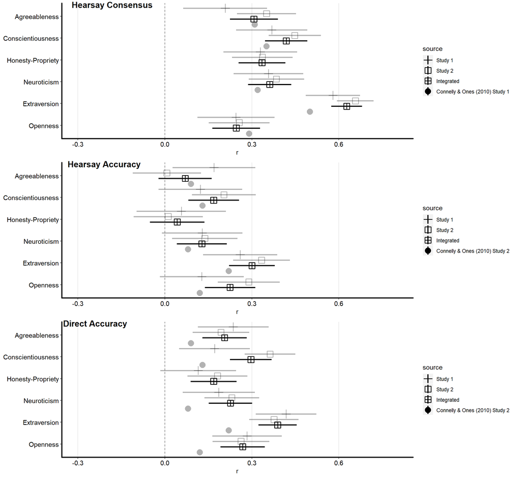

```r
plot_names <- plot_names[str_detect(plot_names, "^plot")]
cowplot::plot_grid(get(plot_names[1]), get(plot_names[2]),
                   get(plot_names[3]), nrow = 3,
                   labels = c("Hearsay Consensus",
                              "Hearsay Accuracy",
                              "Direct Accuracy"),
                   label_y = 1.01,
                   label_x = .06)
```

## Study 2 & Integrated Distinctive Hearsay Accuracy

### Agreeableness

The models and results for distinctive hearsay accuracy of Agreeableness.

#### Check Justifiability of Pooling

```r
# specify the model
agreeableness_distinctive_hearsay_accuracy_uneq <-'
# distinctive hearsay accuracy and distinctive direct accuracy paths
C_C_agreeableness ~ c(DHA_s1, DHA_s2)*B_C_agreeableness + c(DDA_s1, DDA_s2)*A_C_agreeableness
A_A_agreeableness ~ c(DHA_s1, DHA_s2)*D_A_agreeableness + c(DDA_s1, DDA_s2)*C_A_agreeableness

# hearsay consensus
B_C_agreeableness ~~ c(HC_s1, HC_s2)*A_C_agreeableness
D_A_agreeableness ~~ c(HC_s1, HC_s2)*C_A_agreeableness

# variances (pooled)
C_C_agreeableness ~~ c(v_s_s1, v_s_s2)*C_C_agreeableness
A_A_agreeableness ~~ c(v_s_s1, v_s_s2)*A_A_agreeableness
A_C_agreeableness ~~ c(v_p1_s1, v_p1_s2)*A_C_agreeableness
C_A_agreeableness ~~ c(v_p1_s1, v_p1_s2)*C_A_agreeableness
B_C_agreeableness ~~ c(v_p2_s1, v_p2_s2)*B_C_agreeableness
D_A_agreeableness ~~ c(v_p2_s1, v_p2_s2)*D_A_agreeableness

# intercepts (pooled)
C_C_agreeableness ~ c(int_s_s1, int_s_s2)*1
A_A_agreeableness ~ c(int_s_s1, int_s_s2)*1
B_C_agreeableness ~ c(int_p1_s1, int_p1_s2)*1
D_A_agreeableness ~ c(int_p1_s1, int_p1_s2)*1
A_C_agreeableness ~ c(int_p2_s1, int_p2_s2)*1
C_A_agreeableness ~ c(int_p2_s1, int_p2_s2)*1
'
# fit the model
fit_agreeableness_distinctive_hearsay_accuracy_uneq <-
  sem(agreeableness_distinctive_hearsay_accuracy_uneq,
      data = integrated,
      group = "study",
      # missing = FIML critical due to planned missingness
      missing="FIML")
```

```r
# specify the model
agreeableness_distinctive_hearsay_accuracy_eq <-'
# distinctive hearsay accuracy and distinctive direct accuracy paths
C_C_agreeableness ~ c(DHA, DHA)*B_C_agreeableness + c(DDA, DDA)*A_C_agreeableness
A_A_agreeableness ~ c(DHA, DHA)*D_A_agreeableness + c(DDA, DDA)*C_A_agreeableness

# hearsay consensus
B_C_agreeableness ~~ c(HC, HC)*A_C_agreeableness
D_A_agreeableness ~~ c(HC, HC)*C_A_agreeableness

# variances (pooled)
C_C_agreeableness ~~ c(v_s, v_s)*C_C_agreeableness
A_A_agreeableness ~~ c(v_s, v_s)*A_A_agreeableness
A_C_agreeableness ~~ c(v_p1, v_p1)*A_C_agreeableness
C_A_agreeableness ~~ c(v_p1, v_p1)*C_A_agreeableness
B_C_agreeableness ~~ c(v_p2, v_p2)*B_C_agreeableness
D_A_agreeableness ~~ c(v_p2, v_p2)*D_A_agreeableness

# intercepts (pooled)
C_C_agreeableness ~ c(int_s, int_s)*1
A_A_agreeableness ~ c(int_s, int_s)*1
B_C_agreeableness ~ c(int_p1, int_p1)*1
D_A_agreeableness ~ c(int_p1, int_p1)*1
A_C_agreeableness ~ c(int_p2, int_p2)*1
C_A_agreeableness ~ c(int_p2, int_p2)*1
'
# fit the model
fit_agreeableness_distinctive_hearsay_accuracy_eq <-
  sem(agreeableness_distinctive_hearsay_accuracy_eq,
      data = integrated,
      group = "study",
      # missing = FIML critical due to planned missingness
      missing = "FIML")
```

##### Compare Models

```r
agree_dha_model_comp <- anova(fit_agreeableness_distinctive_hearsay_accuracy_uneq,
      fit_agreeableness_distinctive_hearsay_accuracy_eq)

agree_dha_model_comp
```

|  | Df | AIC | BIC | Chisq | Chisq diff | Df diff | Pr(>Chisq) |
| --- | --- | --- | --- | --- | --- | --- | --- |
| fit_agreeableness_distinctive_hearsay_accuracy_uneq | 34 | 2713.920 | 2788.716 | 101.6442 | NA | NA | NA |
| fit_agreeableness_distinctive_hearsay_accuracy_eq | 43 | 2710.558 | 2751.695 | 116.2817 | 14.63752 | 9 | 0.101386 |

AIC and BIC are better for the model pooling across studies. and $\chi^2$ is not significant. All signs point to pooling across studies.

#### Full Model Results

```r
summary(fit_agreeableness_distinctive_hearsay_accuracy_eq,
        standardized = TRUE)
```

```
## lavaan 0.6-4 ended normally after 36 iterations
##
##   Optimization method                           NLMINB
##   Number of free parameters                         38
##   Number of equality constraints                    27
##   Row rank of the constraints matrix                27
##
##                                                   Used       Total
##   Number of observations per group
##   study 1                                          122         124
##   study 2                                          189         195
##   Number of missing patterns per group
##   study 1                                            7
##   study 2                                            3
##
##   Estimator                                         ML
##   Model Fit Test Statistic                     116.282
##   Degrees of freedom                                43
##   P-value (Chi-square)                           0.000
##
## Chi-square for each group:
##
##   study 1                                       54.577
##   study 2                                       61.704
##
## Parameter Estimates:
##
##   Information                                 Observed
##   Observed information based on                Hessian
##   Standard Errors                             Standard
##
##
## Group 1 [study 1]:
##
## Regressions:
##                       Estimate  Std.Err  z-value  P(>|z|)   Std.lv
##   C_C_agreeableness ~
##     B_C_grbl (DHA)       0.005    0.048    0.107    0.915    0.005
##     A_C_grbl (DDA)       0.245    0.044    5.601    0.000    0.245
##   A_A_agreeableness ~
```

[output cut: 81 more lines]

```
##    .C_C_grb (int_)    2.902    0.197   14.695    0.000    2.902    5.270
##    .A_A_grb (int_)    2.902    0.197   14.695    0.000    2.902    5.270
##     B_C_grb (in_1)    3.717    0.025  149.723    0.000    3.717    6.830
##     D_A_grb (in_1)    3.717    0.025  149.723    0.000    3.717    6.830
##     A_C_grb (in_2)    3.914    0.022  178.318    0.000    3.914    7.160
##     C_A_grb (in_2)    3.914    0.022  178.318    0.000    3.914    7.160
##
## Variances:
##                    Estimate  Std.Err  z-value  P(>|z|)   Std.lv  Std.all
##    .C_C_grb  (v_s)    0.285    0.017   17.102    0.000    0.285    0.940
##    .A_A_grb  (v_s)    0.285    0.017   17.102    0.000    0.285    0.940
##     A_C_grb (v_p1)    0.299    0.017   17.614    0.000    0.299    1.000
##     C_A_grb (v_p1)    0.299    0.017   17.614    0.000    0.299    1.000
##     B_C_grb (v_p2)    0.296    0.019   15.313    0.000    0.296    1.000
##     D_A_grb (v_p2)    0.296    0.019   15.313    0.000    0.296    1.000
```

Looks like the path from P2(T) -> T(T) is not significant, suggesting that P2s do not achieve distinctive hearsay accuracy for Agreeableness.

#### Table of Results

Now get a table of the three main results we want:

- Distinctive Hearsay Accuracy
- Distinctive Direct Accuracy
- Hearsay Consensus

```r
agree_dha_uneq_results <-
  fit_agreeableness_distinctive_hearsay_accuracy_uneq@ParTable %>%
  as.data.frame() %>%
  select(label, lhs, op, rhs, group) %>%
  left_join(standardizedsolution(fit_agreeableness_distinctive_hearsay_accuracy_uneq)) %>%
  separate(label, c("label", "study"), sep = -3) %>%
  mutate(study = str_remove(study, "_"),
         study = case_when(study == "s1" ~ "Study 1",
                           study == "s2" ~ "Study 2"))  %>%
  select(study, label, est.std, ci.lower, ci.upper, pvalue)

agree_dha_eq_results <-
  fit_agreeableness_distinctive_hearsay_accuracy_eq@ParTable %>%
  as.data.frame() %>%
  select(label, lhs, op, rhs) %>%
  left_join(standardizedsolution(fit_agreeableness_distinctive_hearsay_accuracy_eq)) %>%
  mutate(study = "Integrated") %>%
  select(study, label, est.std, ci.lower, ci.upper, pvalue)

agree_dha_table <- agree_dha_uneq_results %>%
  full_join(agree_dha_eq_results) %>%
  filter(label == "DHA" |
         label == "DDA" |
         label == "HC") %>%
  distinct(label, study, .keep_all = TRUE) %>%
  mutate(label = str_replace_all(label, "DHA", "Distinctive Hearsay Accuracy"),
         label = str_replace_all(label, "DDA", "Distinctive Direct Accuracy"),
         label = str_replace_all(label, "HC", "Hearsay Consensus")) %>%
  select(study, label, est.std, ci.lower, ci.upper, pvalue)
```

### Conscientiousness

The model and results for distinctive hearsay accuracy of Conscientiousness.

#### Check Justifiability of Pooling

```r
# specify the model
conscientiousness_distinctive_hearsay_accuracy_uneq <-'
# distinctive hearsay accuracy and distinctive direct accuracy paths
C_C_conscientiousness ~ c(DHA_s1, DHA_s2)*B_C_conscientiousness + c(DDA_s1, DDA_s2)*A_C_conscientiousness
A_A_conscientiousness ~ c(DHA_s1, DHA_s2)*D_A_conscientiousness + c(DDA_s1, DDA_s2)*C_A_conscientiousness

# hearsay consensus
B_C_conscientiousness ~~ c(HC_s1, HC_s2)*A_C_conscientiousness
D_A_conscientiousness ~~ c(HC_s1, HC_s2)*C_A_conscientiousness

# variances (pooled)
C_C_conscientiousness ~~ c(v_s_s1, v_s_s2)*C_C_conscientiousness
A_A_conscientiousness ~~ c(v_s_s1, v_s_s2)*A_A_conscientiousness
A_C_conscientiousness ~~ c(v_p1_s1, v_p1_s2)*A_C_conscientiousness
C_A_conscientiousness ~~ c(v_p1_s1, v_p1_s2)*C_A_conscientiousness
B_C_conscientiousness ~~ c(v_p2_s1, v_p2_s2)*B_C_conscientiousness
D_A_conscientiousness ~~ c(v_p2_s1, v_p2_s2)*D_A_conscientiousness

# intercepts (pooled)
C_C_conscientiousness ~ c(int_s_s1, int_s_s2)*1
A_A_conscientiousness ~ c(int_s_s1, int_s_s2)*1
B_C_conscientiousness ~ c(int_p1_s1, int_p1_s2)*1
D_A_conscientiousness ~ c(int_p1_s1, int_p1_s2)*1
A_C_conscientiousness ~ c(int_p2_s1, int_p2_s2)*1
C_A_conscientiousness ~ c(int_p2_s1, int_p2_s2)*1
'
# fit the model
fit_conscientiousness_distinctive_hearsay_accuracy_uneq <-
  sem(conscientiousness_distinctive_hearsay_accuracy_uneq,
      data = integrated,
      group = "study",
      # missing = FIML critical due to planned missingness
      missing="FIML")
```

```r
# specify the model
conscientiousness_distinctive_hearsay_accuracy_eq <-'
# distinctive hearsay accuracy and distinctive direct accuracy paths
C_C_conscientiousness ~ c(DHA, DHA)*B_C_conscientiousness + c(DDA, DDA)*A_C_conscientiousness
A_A_conscientiousness ~ c(DHA, DHA)*D_A_conscientiousness + c(DDA, DDA)*C_A_conscientiousness

# hearsay consensus
B_C_conscientiousness ~~ c(HC, HC)*A_C_conscientiousness
D_A_conscientiousness ~~ c(HC, HC)*C_A_conscientiousness

# variances (pooled)
C_C_conscientiousness ~~ c(v_s, v_s)*C_C_conscientiousness
A_A_conscientiousness ~~ c(v_s, v_s)*A_A_conscientiousness
A_C_conscientiousness ~~ c(v_p1, v_p1)*A_C_conscientiousness
C_A_conscientiousness ~~ c(v_p1, v_p1)*C_A_conscientiousness
B_C_conscientiousness ~~ c(v_p2, v_p2)*B_C_conscientiousness
D_A_conscientiousness ~~ c(v_p2, v_p2)*D_A_conscientiousness

# intercepts (pooled)
C_C_conscientiousness ~ c(int_s, int_s)*1
A_A_conscientiousness ~ c(int_s, int_s)*1
B_C_conscientiousness ~ c(int_p1, int_p1)*1
D_A_conscientiousness ~ c(int_p1, int_p1)*1
A_C_conscientiousness ~ c(int_p2, int_p2)*1
C_A_conscientiousness ~ c(int_p2, int_p2)*1
'
# fit the model
fit_conscientiousness_distinctive_hearsay_accuracy_eq <-
  sem(conscientiousness_distinctive_hearsay_accuracy_eq,
      data = integrated,
      group = "study",
      # missing = FIML critical due to planned missingness
      missing = "FIML")
```

##### Compare Models

```r
consc_dha_model_comp <- anova(fit_conscientiousness_distinctive_hearsay_accuracy_uneq,
      fit_conscientiousness_distinctive_hearsay_accuracy_eq)

consc_dha_model_comp
```

|  | Df | AIC | BIC | Chisq | Chisq diff | Df diff | Pr(>Chisq) |
| --- | --- | --- | --- | --- | --- | --- | --- |
| fit_conscientiousness_distinctive_hearsay_accuracy_uneq | 34 | 3091.966 | 3166.762 | 76.64885 | NA | NA | NA |
| fit_conscientiousness_distinctive_hearsay_accuracy_eq | 43 | 3096.462 | 3137.600 | 99.14488 | 22.49603 | 9 | 0.007433064 |

#### Full Model Results

```r
summary(fit_conscientiousness_distinctive_hearsay_accuracy_eq,
        standardized = TRUE)
```

```
## lavaan 0.6-4 ended normally after 32 iterations
##
##   Optimization method                           NLMINB
##   Number of free parameters                         38
##   Number of equality constraints                    27
##   Row rank of the constraints matrix                27
##
##                                                   Used       Total
##   Number of observations per group
##   study 1                                          122         124
##   study 2                                          189         195
##   Number of missing patterns per group
##   study 1                                            7
##   study 2                                            3
##
##   Estimator                                         ML
##   Model Fit Test Statistic                      99.145
##   Degrees of freedom                                43
##   P-value (Chi-square)                           0.000
##
## Chi-square for each group:
##
##   study 1                                       52.099
##   study 2                                       47.046
##
## Parameter Estimates:
##
##   Information                                 Observed
##   Observed information based on                Hessian
##   Standard Errors                             Standard
##
##
## Group 1 [study 1]:
##
## Regressions:
##                           Estimate  Std.Err  z-value  P(>|z|)   Std.lv
##   C_C_conscientiousness ~
##     B_C_cnsc (DHA)           0.059    0.049    1.218    0.223    0.059
##     A_C_cnsc (DDA)           0.285    0.045    6.309    0.000    0.285
##   A_A_conscientiousness ~
```

[output cut: 81 more lines]

```
##    .C_C_cns (int_)    2.276    0.180   12.647    0.000    2.276    3.628
##    .A_A_cns (int_)    2.276    0.180   12.647    0.000    2.276    3.628
##     B_C_cns (in_1)    3.663    0.029  127.538    0.000    3.663    5.759
##     D_A_cns (in_1)    3.663    0.029  127.538    0.000    3.663    5.759
##     A_C_cns (in_2)    3.701    0.024  151.301    0.000    3.701    6.074
##     C_A_cns (in_2)    3.701    0.024  151.301    0.000    3.701    6.074
##
## Variances:
##                    Estimate  Std.Err  z-value  P(>|z|)   Std.lv  Std.all
##    .C_C_cns  (v_s)    0.356    0.020   17.450    0.000    0.356    0.906
##    .A_A_cns  (v_s)    0.356    0.020   17.450    0.000    0.356    0.906
##     A_C_cns (v_p1)    0.371    0.021   17.612    0.000    0.371    1.000
##     C_A_cns (v_p1)    0.371    0.021   17.612    0.000    0.371    1.000
##     B_C_cns (v_p2)    0.404    0.026   15.474    0.000    0.404    1.000
##     D_A_cns (v_p2)    0.404    0.026   15.474    0.000    0.404    1.000
```

Looks like the path from P2(T) -> T(T) is not significant, suggesting that P2s do not achieve distinctive hearsay accuracy for Conscientiousness.

#### Table of Results

Now get a table of the three main results we want:

- Distinctive Hearsay Accuracy
- Distinctive Direct Accuracy
- Hearsay Consensus

```r
consc_dha_uneq_results <-
  fit_conscientiousness_distinctive_hearsay_accuracy_uneq@ParTable %>%
  as.data.frame() %>%
  select(label, lhs, op, rhs, group) %>%
  left_join(standardizedsolution(fit_conscientiousness_distinctive_hearsay_accuracy_uneq)) %>%
  separate(label, c("label", "study"), sep = -3) %>%
  mutate(study = str_remove(study, "_"),
         study = case_when(study == "s1" ~ "Study 1",
                           study == "s2" ~ "Study 2"))  %>%
  select(study, label, est.std, ci.lower, ci.upper, pvalue)

consc_dha_eq_results <-
  fit_conscientiousness_distinctive_hearsay_accuracy_eq@ParTable %>%
  as.data.frame() %>%
  select(label, lhs, op, rhs) %>%
  left_join(standardizedsolution(fit_conscientiousness_distinctive_hearsay_accuracy_eq)) %>%
  mutate(study = "Integrated") %>%
  select(study, label, est.std, ci.lower, ci.upper, pvalue)

consc_dha_table <- consc_dha_uneq_results %>%
  full_join(consc_dha_eq_results) %>%
  filter(label == "DHA" |
         label == "DDA" |
         label == "HC") %>%
  distinct(label, study, .keep_all = TRUE) %>%
  mutate(label = str_replace_all(label, "DHA", "Distinctive Hearsay Accuracy"),
         label = str_replace_all(label, "DDA", "Distinctive Direct Accuracy"),
         label = str_replace_all(label, "HC", "Hearsay Consensus")) %>%
  select(study, label, est.std, ci.lower, ci.upper, pvalue)
```

### Honesty-Propriety

The model and results for distinctive hearsay accuracy of Honesty-Propriety.

#### Check Justifiability of Pooling

```r
# specify the model
hp_distinctive_hearsay_accuracy_uneq <-'
# distinctive hearsay accuracy and distinctive direct accuracy paths
C_C_hp ~ c(DHA_s1, DHA_s2)*B_C_hp + c(DDA_s1, DDA_s2)*A_C_hp
A_A_hp ~ c(DHA_s1, DHA_s2)*D_A_hp + c(DDA_s1, DDA_s2)*C_A_hp

# hearsay consensus
B_C_hp ~~ c(HC_s1, HC_s2)*A_C_hp
D_A_hp ~~ c(HC_s1, HC_s2)*C_A_hp

# variances (pooled)
C_C_hp ~~ c(v_s_s1, v_s_s2)*C_C_hp
A_A_hp ~~ c(v_s_s1, v_s_s2)*A_A_hp
A_C_hp ~~ c(v_p1_s1, v_p1_s2)*A_C_hp
C_A_hp ~~ c(v_p1_s1, v_p1_s2)*C_A_hp
B_C_hp ~~ c(v_p2_s1, v_p2_s2)*B_C_hp
D_A_hp ~~ c(v_p2_s1, v_p2_s2)*D_A_hp

# intercepts (pooled)
C_C_hp ~ c(int_s_s1, int_s_s2)*1
A_A_hp ~ c(int_s_s1, int_s_s2)*1
B_C_hp ~ c(int_p1_s1, int_p1_s2)*1
D_A_hp ~ c(int_p1_s1, int_p1_s2)*1
A_C_hp ~ c(int_p2_s1, int_p2_s2)*1
C_A_hp ~ c(int_p2_s1, int_p2_s2)*1
'
# fit the model
fit_hp_distinctive_hearsay_accuracy_uneq <-
  sem(hp_distinctive_hearsay_accuracy_uneq,
      data = integrated,
      group = "study",
      # missing = FIML critical due to planned missingness
      missing="FIML")
```

```r
# specify the model
hp_distinctive_hearsay_accuracy_eq <-'
# distinctive hearsay accuracy and distinctive direct accuracy paths
C_C_hp ~ c(DHA, DHA)*B_C_hp + c(DDA, DDA)*A_C_hp
A_A_hp ~ c(DHA, DHA)*D_A_hp + c(DDA, DDA)*C_A_hp

# hearsay consensus
B_C_hp ~~ c(HC, HC)*A_C_hp
D_A_hp ~~ c(HC, HC)*C_A_hp

# variances (pooled)
C_C_hp ~~ c(v_s, v_s)*C_C_hp
A_A_hp ~~ c(v_s, v_s)*A_A_hp
A_C_hp ~~ c(v_p1, v_p1)*A_C_hp
C_A_hp ~~ c(v_p1, v_p1)*C_A_hp
B_C_hp ~~ c(v_p2, v_p2)*B_C_hp
D_A_hp ~~ c(v_p2, v_p2)*D_A_hp

# intercepts (pooled)
C_C_hp ~ c(int_s, int_s)*1
A_A_hp ~ c(int_s, int_s)*1
B_C_hp ~ c(int_p1, int_p1)*1
D_A_hp ~ c(int_p1, int_p1)*1
A_C_hp ~ c(int_p2, int_p2)*1
C_A_hp ~ c(int_p2, int_p2)*1
'
# fit the model
fit_hp_distinctive_hearsay_accuracy_eq <-
  sem(hp_distinctive_hearsay_accuracy_eq,
      data = integrated,
      group = "study",
      # missing = FIML critical due to planned missingness
      missing = "FIML")
```

##### Compare Models

```r
hp_dha_model_comp <- anova(fit_hp_distinctive_hearsay_accuracy_uneq,
      fit_hp_distinctive_hearsay_accuracy_eq)

hp_dha_model_comp
```

|  | Df | AIC | BIC | Chisq | Chisq diff | Df diff | Pr(>Chisq) |
| --- | --- | --- | --- | --- | --- | --- | --- |
| fit_hp_distinctive_hearsay_accuracy_uneq | 34 | 2797.551 | 2872.347 | 83.33914 | NA | NA | NA |
| fit_hp_distinctive_hearsay_accuracy_eq | 43 | 2797.528 | 2838.666 | 101.31630 | 17.97716 | 9 | 0.03543947 |

#### Full Model Results

```r
summary(fit_hp_distinctive_hearsay_accuracy_eq,
        standardized = TRUE)
```

```
## lavaan 0.6-4 ended normally after 34 iterations
##
##   Optimization method                           NLMINB
##   Number of free parameters                         38
##   Number of equality constraints                    27
##   Row rank of the constraints matrix                27
##
##                                                   Used       Total
##   Number of observations per group
##   study 1                                          122         124
##   study 2                                          189         195
##   Number of missing patterns per group
##   study 1                                            7
##   study 2                                            3
##
##   Estimator                                         ML
##   Model Fit Test Statistic                     101.316
##   Degrees of freedom                                43
##   P-value (Chi-square)                           0.000
##
## Chi-square for each group:
##
##   study 1                                       35.685
##   study 2                                       65.631
##
## Parameter Estimates:
##
##   Information                                 Observed
##   Observed information based on                Hessian
##   Standard Errors                             Standard
##
##
## Group 1 [study 1]:
##
## Regressions:
##                    Estimate  Std.Err  z-value  P(>|z|)   Std.lv  Std.all
##   C_C_hp ~
##     B_C_hp   (DHA)    0.003    0.050    0.067    0.946    0.003    0.003
##     A_C_hp   (DDA)    0.168    0.045    3.705    0.000    0.168    0.165
##   A_A_hp ~
```

[output cut: 53 more lines]

```
##    .C_C_hp  (int_)    3.074    0.198   15.517    0.000    3.074    5.467
##    .A_A_hp  (int_)    3.074    0.198   15.517    0.000    3.074    5.467
##     B_C_hp  (in_1)    3.498    0.025  137.295    0.000    3.498    6.256
##     D_A_hp  (in_1)    3.498    0.025  137.295    0.000    3.498    6.256
##     A_C_hp  (in_2)    3.752    0.022  169.111    0.000    3.752    6.790
##     C_A_hp  (in_2)    3.752    0.022  169.111    0.000    3.752    6.790
##
## Variances:
##                    Estimate  Std.Err  z-value  P(>|z|)   Std.lv  Std.all
##    .C_C_hp   (v_s)    0.307    0.018   17.428    0.000    0.307    0.972
##    .A_A_hp   (v_s)    0.307    0.018   17.428    0.000    0.307    0.972
##     A_C_hp  (v_p1)    0.305    0.017   17.613    0.000    0.305    1.000
##     C_A_hp  (v_p1)    0.305    0.017   17.613    0.000    0.305    1.000
##     B_C_hp  (v_p2)    0.313    0.020   15.319    0.000    0.313    1.000
##     D_A_hp  (v_p2)    0.313    0.020   15.319    0.000    0.313    1.000
```

Looks like the path from P2(T) -> T(T) is not significant, suggesting that P2s do not achieve distinctive hearsay accuracy for Honesty-Propriety.

#### Table of Results

Now get a table of the three main results we want:

- Distinctive Hearsay Accuracy
- Distinctive Direct Accuracy
- Hearsay Consensus

```r
hp_dha_uneq_results <-
  fit_hp_distinctive_hearsay_accuracy_uneq@ParTable %>%
  as.data.frame() %>%
  select(label, lhs, op, rhs, group) %>%
  left_join(standardizedsolution(fit_hp_distinctive_hearsay_accuracy_uneq)) %>%
  separate(label, c("label", "study"), sep = -3) %>%
  mutate(study = str_remove(study, "_"),
         study = case_when(study == "s1" ~ "Study 1",
                           study == "s2" ~ "Study 2"))  %>%
  select(study, label, est.std, ci.lower, ci.upper, pvalue)

hp_dha_eq_results <-
  fit_hp_distinctive_hearsay_accuracy_eq@ParTable %>%
  as.data.frame() %>%
  select(label, lhs, op, rhs) %>%
  left_join(standardizedsolution(fit_hp_distinctive_hearsay_accuracy_eq)) %>%
  mutate(study = "Integrated") %>%
  select(study, label, est.std, ci.lower, ci.upper, pvalue)

hp_dha_table <- hp_dha_uneq_results %>%
  full_join(hp_dha_eq_results) %>%
  filter(label == "DHA" |
         label == "DDA" |
         label == "HC") %>%
  distinct(label, study, .keep_all = TRUE) %>%
  mutate(label = str_replace_all(label, "DHA", "Distinctive Hearsay Accuracy"),
         label = str_replace_all(label, "DDA", "Distinctive Direct Accuracy"),
         label = str_replace_all(label, "HC", "Hearsay Consensus")) %>%
  select(study, label, est.std, ci.lower, ci.upper, pvalue)
```

### Neuroticism

The model and results for distinctive hearsay accuracy of Neuroticism.

#### Check Justifiability of Pooling

```r
# specify the model
neuroticism_distinctive_hearsay_accuracy_uneq <-'
# distinctive hearsay accuracy and distinctive direct accuracy paths
C_C_neuroticism ~ c(DHA_s1, DHA_s2)*B_C_neuroticism + c(DDA_s1, DDA_s2)*A_C_neuroticism
A_A_neuroticism ~ c(DHA_s1, DHA_s2)*D_A_neuroticism + c(DDA_s1, DDA_s2)*C_A_neuroticism

# hearsay consensus
B_C_neuroticism ~~ c(HC_s1, HC_s2)*A_C_neuroticism
D_A_neuroticism ~~ c(HC_s1, HC_s2)*C_A_neuroticism

# variances (pooled)
C_C_neuroticism ~~ c(v_s_s1, v_s_s2)*C_C_neuroticism
A_A_neuroticism ~~ c(v_s_s1, v_s_s2)*A_A_neuroticism
A_C_neuroticism ~~ c(v_p1_s1, v_p1_s2)*A_C_neuroticism
C_A_neuroticism ~~ c(v_p1_s1, v_p1_s2)*C_A_neuroticism
B_C_neuroticism ~~ c(v_p2_s1, v_p2_s2)*B_C_neuroticism
D_A_neuroticism ~~ c(v_p2_s1, v_p2_s2)*D_A_neuroticism

# intercepts (pooled)
C_C_neuroticism ~ c(int_s_s1, int_s_s2)*1
A_A_neuroticism ~ c(int_s_s1, int_s_s2)*1
B_C_neuroticism ~ c(int_p1_s1, int_p1_s2)*1
D_A_neuroticism ~ c(int_p1_s1, int_p1_s2)*1
A_C_neuroticism ~ c(int_p2_s1, int_p2_s2)*1
C_A_neuroticism ~ c(int_p2_s1, int_p2_s2)*1
'
# fit the model
fit_neuroticism_distinctive_hearsay_accuracy_uneq <-
  sem(neuroticism_distinctive_hearsay_accuracy_uneq,
      data = integrated,
      group = "study",
      # missing = FIML critical due to planned missingness
      missing="FIML")
```

```r
# specify the model
neuroticism_distinctive_hearsay_accuracy_eq <-'
# distinctive hearsay accuracy and distinctive direct accuracy paths
C_C_neuroticism ~ c(DHA, DHA)*B_C_neuroticism + c(DDA, DDA)*A_C_neuroticism
A_A_neuroticism ~ c(DHA, DHA)*D_A_neuroticism + c(DDA, DDA)*C_A_neuroticism

# hearsay consensus
B_C_neuroticism ~~ c(HC, HC)*A_C_neuroticism
D_A_neuroticism ~~ c(HC, HC)*C_A_neuroticism

# variances (pooled)
C_C_neuroticism ~~ c(v_s, v_s)*C_C_neuroticism
A_A_neuroticism ~~ c(v_s, v_s)*A_A_neuroticism
A_C_neuroticism ~~ c(v_p1, v_p1)*A_C_neuroticism
C_A_neuroticism ~~ c(v_p1, v_p1)*C_A_neuroticism
B_C_neuroticism ~~ c(v_p2, v_p2)*B_C_neuroticism
D_A_neuroticism ~~ c(v_p2, v_p2)*D_A_neuroticism

# intercepts (pooled)
C_C_neuroticism ~ c(int_s, int_s)*1
A_A_neuroticism ~ c(int_s, int_s)*1
B_C_neuroticism ~ c(int_p1, int_p1)*1
D_A_neuroticism ~ c(int_p1, int_p1)*1
A_C_neuroticism ~ c(int_p2, int_p2)*1
C_A_neuroticism ~ c(int_p2, int_p2)*1
'
# fit the model
fit_neuroticism_distinctive_hearsay_accuracy_eq <-
  sem(neuroticism_distinctive_hearsay_accuracy_eq,
      data = integrated,
      group = "study",
      # missing = FIML critical due to planned missingness
      missing = "FIML")
```

##### Compare Models

```r
neuro_dha_model_comp <- anova(fit_neuroticism_distinctive_hearsay_accuracy_uneq,
      fit_neuroticism_distinctive_hearsay_accuracy_eq)

neuro_dha_model_comp
```

|  | Df | AIC | BIC | Chisq | Chisq diff | Df diff | Pr(>Chisq) |
| --- | --- | --- | --- | --- | --- | --- | --- |
| fit_neuroticism_distinctive_hearsay_accuracy_uneq | 34 | 3214.032 | 3288.828 | 100.9065 | NA | NA | NA |
| fit_neuroticism_distinctive_hearsay_accuracy_eq | 43 | 3224.373 | 3265.511 | 129.2473 | 28.34076 | 9 | 0.0008364839 |

#### Full Model Results

```r
summary(fit_neuroticism_distinctive_hearsay_accuracy_eq,
        standardized = TRUE)
```

```
## lavaan 0.6-4 ended normally after 26 iterations
##
##   Optimization method                           NLMINB
##   Number of free parameters                         38
##   Number of equality constraints                    27
##   Row rank of the constraints matrix                27
##
##                                                   Used       Total
##   Number of observations per group
##   study 1                                          122         124
##   study 2                                          189         195
##   Number of missing patterns per group
##   study 1                                            7
##   study 2                                            3
##
##   Estimator                                         ML
##   Model Fit Test Statistic                     129.247
##   Degrees of freedom                                43
##   P-value (Chi-square)                           0.000
##
## Chi-square for each group:
##
##   study 1                                       56.763
##   study 2                                       72.484
##
## Parameter Estimates:
##
##   Information                                 Observed
##   Observed information based on                Hessian
##   Standard Errors                             Standard
##
##
## Group 1 [study 1]:
##
## Regressions:
##                     Estimate  Std.Err  z-value  P(>|z|)   Std.lv  Std.all
##   C_C_neuroticism ~
##     B_C_nrtc (DHA)     0.113    0.070    1.606    0.108    0.113    0.078
##     A_C_nrtc (DDA)     0.257    0.062    4.149    0.000    0.257    0.179
##   A_A_neuroticism ~
```

[output cut: 53 more lines]

```
##    .C_C_nrt (int_)    1.927    0.193    9.973    0.000    1.927    2.397
##    .A_A_nrt (int_)    1.927    0.193    9.973    0.000    1.927    2.397
##     B_C_nrt (in_1)    2.688    0.025  106.476    0.000    2.688    4.831
##     D_A_nrt (in_1)    2.688    0.025  106.476    0.000    2.688    4.831
##     A_C_nrt (in_2)    2.569    0.022  114.328    0.000    2.569    4.590
##     C_A_nrt (in_2)    2.569    0.022  114.328    0.000    2.569    4.590
##
## Variances:
##                    Estimate  Std.Err  z-value  P(>|z|)   Std.lv  Std.all
##    .C_C_nrt  (v_s)    0.615    0.035   17.326    0.000    0.615    0.952
##    .A_A_nrt  (v_s)    0.615    0.035   17.326    0.000    0.615    0.952
##     A_C_nrt (v_p1)    0.313    0.018   17.615    0.000    0.313    1.000
##     C_A_nrt (v_p1)    0.313    0.018   17.615    0.000    0.313    1.000
##     B_C_nrt (v_p2)    0.310    0.020   15.545    0.000    0.310    1.000
##     D_A_nrt (v_p2)    0.310    0.020   15.545    0.000    0.310    1.000
```

Looks like the path from P2(T) -> T(T) is not significant, suggesting that P2s do not achieve distinctive hearsay accuracy for Neuroticism.

#### Table of Results

Now get a table of the three main results we want:

- Distinctive Hearsay Accuracy
- Distinctive Direct Accuracy
- Hearsay Consensus

```r
neuro_dha_uneq_results <-
  fit_neuroticism_distinctive_hearsay_accuracy_uneq@ParTable %>%
  as.data.frame() %>%
  select(label, lhs, op, rhs, group) %>%
  left_join(standardizedsolution(fit_neuroticism_distinctive_hearsay_accuracy_uneq)) %>%
  separate(label, c("label", "study"), sep = -3) %>%
  mutate(study = str_remove(study, "_"),
         study = case_when(study == "s1" ~ "Study 1",
                           study == "s2" ~ "Study 2"))  %>%
  select(study, label, est.std, ci.lower, ci.upper, pvalue)

neuro_dha_eq_results <-
  fit_neuroticism_distinctive_hearsay_accuracy_eq@ParTable %>%
  as.data.frame() %>%
  select(label, lhs, op, rhs) %>%
  left_join(standardizedsolution(fit_neuroticism_distinctive_hearsay_accuracy_eq)) %>%
  mutate(study = "Integrated") %>%
  select(study, label, est.std, ci.lower, ci.upper, pvalue)

neuro_dha_table <- neuro_dha_uneq_results %>%
  full_join(neuro_dha_eq_results) %>%
  filter(label == "DHA" |
         label == "DDA" |
         label == "HC") %>%
  distinct(label, study, .keep_all = TRUE) %>%
  mutate(label = str_replace_all(label, "DHA", "Distinctive Hearsay Accuracy"),
         label = str_replace_all(label, "DDA", "Distinctive Direct Accuracy"),
         label = str_replace_all(label, "HC", "Hearsay Consensus")) %>%
  select(study, label, est.std, ci.lower, ci.upper, pvalue)
```

### Extraversion

The model and results for distinctive hearsay accuracy of Extraversion.

#### Check Justifiability of Pooling

```r
# specify the model
extraversion_distinctive_hearsay_accuracy_uneq <-'
# distinctive hearsay accuracy and distinctive direct accuracy paths
C_C_extraversion ~ c(DHA_s1, DHA_s2)*B_C_extraversion + c(DDA_s1, DDA_s2)*A_C_extraversion
A_A_extraversion ~ c(DHA_s1, DHA_s2)*D_A_extraversion + c(DDA_s1, DDA_s2)*C_A_extraversion

# hearsay consensus
B_C_extraversion ~~ c(HC_s1, HC_s2)*A_C_extraversion
D_A_extraversion ~~ c(HC_s1, HC_s2)*C_A_extraversion

# variances (pooled)
C_C_extraversion ~~ c(v_s_s1, v_s_s2)*C_C_extraversion
A_A_extraversion ~~ c(v_s_s1, v_s_s2)*A_A_extraversion
A_C_extraversion ~~ c(v_p1_s1, v_p1_s2)*A_C_extraversion
C_A_extraversion ~~ c(v_p1_s1, v_p1_s2)*C_A_extraversion
B_C_extraversion ~~ c(v_p2_s1, v_p2_s2)*B_C_extraversion
D_A_extraversion ~~ c(v_p2_s1, v_p2_s2)*D_A_extraversion

# intercepts (pooled)
C_C_extraversion ~ c(int_s_s1, int_s_s2)*1
A_A_extraversion ~ c(int_s_s1, int_s_s2)*1
B_C_extraversion ~ c(int_p1_s1, int_p1_s2)*1
D_A_extraversion ~ c(int_p1_s1, int_p1_s2)*1
A_C_extraversion ~ c(int_p2_s1, int_p2_s2)*1
C_A_extraversion ~ c(int_p2_s1, int_p2_s2)*1
'
# fit the model
fit_extraversion_distinctive_hearsay_accuracy_uneq <-
  sem(extraversion_distinctive_hearsay_accuracy_uneq,
      data = integrated,
      group = "study",
      # missing = FIML critical due to planned missingness
      missing="FIML")
```

```r
# specify the model
extraversion_distinctive_hearsay_accuracy_eq <-'
# distinctive hearsay accuracy and distinctive direct accuracy paths
C_C_extraversion ~ c(DHA, DHA)*B_C_extraversion + c(DDA, DDA)*A_C_extraversion
A_A_extraversion ~ c(DHA, DHA)*D_A_extraversion + c(DDA, DDA)*C_A_extraversion

# hearsay consensus
B_C_extraversion ~~ c(HC, HC)*A_C_extraversion
D_A_extraversion ~~ c(HC, HC)*C_A_extraversion

# variances (pooled)
C_C_extraversion ~~ c(v_s, v_s)*C_C_extraversion
A_A_extraversion ~~ c(v_s, v_s)*A_A_extraversion
A_C_extraversion ~~ c(v_p1, v_p1)*A_C_extraversion
C_A_extraversion ~~ c(v_p1, v_p1)*C_A_extraversion
B_C_extraversion ~~ c(v_p2, v_p2)*B_C_extraversion
D_A_extraversion ~~ c(v_p2, v_p2)*D_A_extraversion

# intercepts (pooled)
C_C_extraversion ~ c(int_s, int_s)*1
A_A_extraversion ~ c(int_s, int_s)*1
B_C_extraversion ~ c(int_p1, int_p1)*1
D_A_extraversion ~ c(int_p1, int_p1)*1
A_C_extraversion ~ c(int_p2, int_p2)*1
C_A_extraversion ~ c(int_p2, int_p2)*1
'
# fit the model
fit_extraversion_distinctive_hearsay_accuracy_eq <-
  sem(extraversion_distinctive_hearsay_accuracy_eq,
      data = integrated,
      group = "study",
      # missing = FIML critical due to planned missingness
      missing = "FIML")
```

##### Compare Models

```r
extra_dha_model_comp <- anova(fit_extraversion_distinctive_hearsay_accuracy_uneq,
      fit_extraversion_distinctive_hearsay_accuracy_eq)

extra_dha_model_comp
```

|  | Df | AIC | BIC | Chisq | Chisq diff | Df diff | Pr(>Chisq) |
| --- | --- | --- | --- | --- | --- | --- | --- |
| fit_extraversion_distinctive_hearsay_accuracy_uneq | 34 | 3512.171 | 3586.967 | 75.43032 | NA | NA | NA |
| fit_extraversion_distinctive_hearsay_accuracy_eq | 43 | 3500.927 | 3542.065 | 82.18611 | 6.755784 | 9 | 0.6625287 |

AIC and BIC are better for the model pooling across studies. and $\chi^2$ is not significant. All signs point to pooling across studies.

#### Full Model Results

```r
summary(fit_extraversion_distinctive_hearsay_accuracy_eq,
        standardized = TRUE)
```

```
## lavaan 0.6-4 ended normally after 24 iterations
##
##   Optimization method                           NLMINB
##   Number of free parameters                         38
##   Number of equality constraints                    27
##   Row rank of the constraints matrix                27
##
##                                                   Used       Total
##   Number of observations per group
##   study 1                                          122         124
##   study 2                                          189         195
##   Number of missing patterns per group
##   study 1                                            7
##   study 2                                            3
##
##   Estimator                                         ML
##   Model Fit Test Statistic                      82.186
##   Degrees of freedom                                43
##   P-value (Chi-square)                           0.000
##
## Chi-square for each group:
##
##   study 1                                       36.147
##   study 2                                       46.039
##
## Parameter Estimates:
##
##   Information                                 Observed
##   Observed information based on                Hessian
##   Standard Errors                             Standard
##
##
## Group 1 [study 1]:
##
## Regressions:
##                      Estimate  Std.Err  z-value  P(>|z|)   Std.lv  Std.all
##   C_C_extraversion ~
##     B_C_xtrv (DHA)      0.100    0.052    1.930    0.054    0.100    0.106
##     A_C_xtrv (DDA)      0.321    0.054    5.948    0.000    0.321    0.310
##   A_A_extraversion ~
```

[output cut: 67 more lines]

```
##    .C_C_xtr (int_)    2.023    0.136   14.915    0.000    2.023    2.739
##    .A_A_xtr (int_)    2.023    0.136   14.915    0.000    2.023    2.739
##     B_C_xtr (in_1)    3.237    0.034   94.003    0.000    3.237    4.119
##     D_A_xtr (in_1)    3.237    0.034   94.003    0.000    3.237    4.119
##     A_C_xtr (in_2)    3.212    0.029  112.291    0.000    3.212    4.507
##     C_A_xtr (in_2)    3.212    0.029  112.291    0.000    3.212    4.507
##
## Variances:
##                    Estimate  Std.Err  z-value  P(>|z|)   Std.lv  Std.all
##    .C_C_xtr  (v_s)    0.465    0.027   17.190    0.000    0.465    0.851
##    .A_A_xtr  (v_s)    0.465    0.027   17.190    0.000    0.465    0.851
##     A_C_xtr (v_p1)    0.508    0.029   17.603    0.000    0.508    1.000
##     C_A_xtr (v_p1)    0.508    0.029   17.603    0.000    0.508    1.000
##     B_C_xtr (v_p2)    0.618    0.039   15.803    0.000    0.618    1.000
##     D_A_xtr (v_p2)    0.618    0.039   15.803    0.000    0.618    1.000
```

Looks like the path from P2(T) -> T(T) is not significant, suggesting that P2s do not achieve distinctive hearsay accuracy for Extraversion.

#### Table of Results

Now get a table of the three main results we want:

- Distinctive Hearsay Accuracy
- Distinctive Direct Accuracy
- Hearsay Consensus

```r
extra_dha_uneq_results <-
  fit_extraversion_distinctive_hearsay_accuracy_uneq@ParTable %>%
  as.data.frame() %>%
  select(label, lhs, op, rhs, group) %>%
  left_join(standardizedsolution(fit_extraversion_distinctive_hearsay_accuracy_uneq)) %>%
  separate(label, c("label", "study"), sep = -3) %>%
  mutate(study = str_remove(study, "_"),
         study = case_when(study == "s1" ~ "Study 1",
                           study == "s2" ~ "Study 2"))  %>%
  select(study, label, est.std, ci.lower, ci.upper, pvalue)

extra_dha_eq_results <-
  fit_extraversion_distinctive_hearsay_accuracy_eq@ParTable %>%
  as.data.frame() %>%
  select(label, lhs, op, rhs) %>%
  left_join(standardizedsolution(fit_extraversion_distinctive_hearsay_accuracy_eq)) %>%
  mutate(study = "Integrated") %>%
  select(study, label, est.std, ci.lower, ci.upper, pvalue)

extra_dha_table <- extra_dha_uneq_results %>%
  full_join(extra_dha_eq_results) %>%
  filter(label == "DHA" |
         label == "DDA" |
         label == "HC") %>%
  distinct(label, study, .keep_all = TRUE) %>%
  mutate(label = str_replace_all(label, "DHA", "Distinctive Hearsay Accuracy"),
         label = str_replace_all(label, "DDA", "Distinctive Direct Accuracy"),
         label = str_replace_all(label, "HC", "Hearsay Consensus")) %>%
  select(study, label, est.std, ci.lower, ci.upper, pvalue)
```

### Openness

The model and results for distinctive hearsay accuracy of Openness.

#### Full Model

```r
# specify the model
openness_distinctive_hearsay_accuracy_uneq <-'
# distinctive hearsay accuracy and distinctive direct accuracy paths
C_C_openness ~ c(DHA_s1, DHA_s2)*B_C_openness + c(DDA_s1, DDA_s2)*A_C_openness
A_A_openness ~ c(DHA_s1, DHA_s2)*D_A_openness + c(DDA_s1, DDA_s2)*C_A_openness

# hearsay consensus
B_C_openness ~~ c(HC_s1, HC_s2)*A_C_openness
D_A_openness ~~ c(HC_s1, HC_s2)*C_A_openness

# variances (pooled)
C_C_openness ~~ c(v_s_s1, v_s_s2)*C_C_openness
A_A_openness ~~ c(v_s_s1, v_s_s2)*A_A_openness
A_C_openness ~~ c(v_p1_s1, v_p1_s2)*A_C_openness
C_A_openness ~~ c(v_p1_s1, v_p1_s2)*C_A_openness
B_C_openness ~~ c(v_p2_s1, v_p2_s2)*B_C_openness
D_A_openness ~~ c(v_p2_s1, v_p2_s2)*D_A_openness

# intercepts (pooled)
C_C_openness ~ c(int_s_s1, int_s_s2)*1
A_A_openness ~ c(int_s_s1, int_s_s2)*1
B_C_openness ~ c(int_p1_s1, int_p1_s2)*1
D_A_openness ~ c(int_p1_s1, int_p1_s2)*1
A_C_openness ~ c(int_p2_s1, int_p2_s2)*1
C_A_openness ~ c(int_p2_s1, int_p2_s2)*1
'
# fit the model
fit_openness_distinctive_hearsay_accuracy_uneq <-
  sem(openness_distinctive_hearsay_accuracy_uneq,
      data = integrated,
      group = "study",
      # missing = FIML critical due to planned missingness
      missing="FIML")
```

```r
# specify the model
openness_distinctive_hearsay_accuracy_eq <-'
# distinctive hearsay accuracy and distinctive direct accuracy paths
C_C_openness ~ c(DHA, DHA)*B_C_openness + c(DDA, DDA)*A_C_openness
A_A_openness ~ c(DHA, DHA)*D_A_openness + c(DDA, DDA)*C_A_openness

# hearsay consensus
B_C_openness ~~ c(HC, HC)*A_C_openness
D_A_openness ~~ c(HC, HC)*C_A_openness

# variances (pooled)
C_C_openness ~~ c(v_s, v_s)*C_C_openness
A_A_openness ~~ c(v_s, v_s)*A_A_openness
A_C_openness ~~ c(v_p1, v_p1)*A_C_openness
C_A_openness ~~ c(v_p1, v_p1)*C_A_openness
B_C_openness ~~ c(v_p2, v_p2)*B_C_openness
D_A_openness ~~ c(v_p2, v_p2)*D_A_openness

# intercepts (pooled)
C_C_openness ~ c(int_s, int_s)*1
A_A_openness ~ c(int_s, int_s)*1
B_C_openness ~ c(int_p1, int_p1)*1
D_A_openness ~ c(int_p1, int_p1)*1
A_C_openness ~ c(int_p2, int_p2)*1
C_A_openness ~ c(int_p2, int_p2)*1
'
# fit the model
fit_openness_distinctive_hearsay_accuracy_eq <-
  sem(openness_distinctive_hearsay_accuracy_eq,
      data = integrated,
      group = "study",
      # missing = FIML critical due to planned missingness
      missing = "FIML")
```

##### Compare Models

```r
open_dha_model_comp <- anova(fit_openness_distinctive_hearsay_accuracy_uneq,
      fit_openness_distinctive_hearsay_accuracy_eq)
open_dha_model_comp
```

|  | Df | AIC | BIC | Chisq | Chisq diff | Df diff | Pr(>Chisq) |
| --- | --- | --- | --- | --- | --- | --- | --- |
| fit_openness_distinctive_hearsay_accuracy_uneq | 34 | 2512.618 | 2587.414 | 104.8349 | NA | NA | NA |
| fit_openness_distinctive_hearsay_accuracy_eq | 43 | 2521.209 | 2562.347 | 131.4265 | 26.59163 | 9 | 0.001633604 |

#### Full Model Results

```r
summary(fit_openness_distinctive_hearsay_accuracy_eq,
        standardized = TRUE)
```

```
## lavaan 0.6-4 ended normally after 39 iterations
##
##   Optimization method                           NLMINB
##   Number of free parameters                         38
##   Number of equality constraints                    27
##   Row rank of the constraints matrix                27
##
##                                                   Used       Total
##   Number of observations per group
##   study 1                                          122         124
##   study 2                                          189         195
##   Number of missing patterns per group
##   study 1                                            7
##   study 2                                            3
##
##   Estimator                                         ML
##   Model Fit Test Statistic                     131.427
##   Degrees of freedom                                43
##   P-value (Chi-square)                           0.000
##
## Chi-square for each group:
##
##   study 1                                       68.543
##   study 2                                       62.884
##
## Parameter Estimates:
##
##   Information                                 Observed
##   Observed information based on                Hessian
##   Standard Errors                             Standard
##
##
## Group 1 [study 1]:
##
## Regressions:
##                    Estimate  Std.Err  z-value  P(>|z|)   Std.lv  Std.all
##   C_C_openness ~
##     B_C_pnns (DHA)    0.208    0.057    3.635    0.000    0.208    0.166
##     A_C_pnns (DDA)    0.234    0.044    5.267    0.000    0.234    0.223
##   A_A_openness ~
```

[output cut: 53 more lines]

```
##    .C_C_pnn (int_)    2.303    0.210   10.961    0.000    2.303    4.119
##    .A_A_pnn (int_)    2.303    0.210   10.961    0.000    2.303    4.119
##     B_C_pnn (in_1)    3.328    0.020  163.493    0.000    3.328    7.466
##     D_A_pnn (in_1)    3.328    0.020  163.493    0.000    3.328    7.466
##     A_C_pnn (in_2)    3.448    0.021  161.058    0.000    3.448    6.467
##     C_A_pnn (in_2)    3.448    0.021  161.058    0.000    3.448    6.467
##
## Variances:
##                    Estimate  Std.Err  z-value  P(>|z|)   Std.lv  Std.all
##    .C_C_pnn  (v_s)    0.283    0.016   17.315    0.000    0.283    0.904
##    .A_A_pnn  (v_s)    0.283    0.016   17.315    0.000    0.283    0.904
##     A_C_pnn (v_p1)    0.284    0.016   17.601    0.000    0.284    1.000
##     C_A_pnn (v_p1)    0.284    0.016   17.601    0.000    0.284    1.000
##     B_C_pnn (v_p2)    0.199    0.013   15.341    0.000    0.199    1.000
##     D_A_pnn (v_p2)    0.199    0.013   15.341    0.000    0.199    1.000
```

Looks like the path from P2(T) -> T(T) is significant. This suggests that P2s achieve some degree of distinctive hearsay accuracy for Openness (distinct from the accuracy they share with P1).

#### Table of Results

Now get a table of the three main results we want:

- Distinctive Hearsay Accuracy
- Distinctive Direct Accuracy
- Hearsay Consensus

```r
open_dha_uneq_results <-
  fit_openness_distinctive_hearsay_accuracy_uneq@ParTable %>%
  as.data.frame() %>%
  select(label, lhs, op, rhs, group) %>%
  left_join(standardizedsolution(fit_openness_distinctive_hearsay_accuracy_uneq)) %>%
  separate(label, c("label", "study"), sep = -3) %>%
  mutate(study = str_remove(study, "_"),
         study = case_when(study == "s1" ~ "Study 1",
                           study == "s2" ~ "Study 2"))  %>%
  select(study, label, est.std, ci.lower, ci.upper, pvalue)

open_dha_eq_results <-
  fit_openness_distinctive_hearsay_accuracy_eq@ParTable %>%
  as.data.frame() %>%
  select(label, lhs, op, rhs) %>%
  left_join(standardizedsolution(fit_openness_distinctive_hearsay_accuracy_eq)) %>%
  mutate(study = "Integrated") %>%
  select(study, label, est.std, ci.lower, ci.upper, pvalue)

open_dha_table <- open_dha_uneq_results %>%
  full_join(open_dha_eq_results) %>%
  filter(label == "DHA" |
         label == "DDA" |
         label == "HC") %>%
  distinct(label, study, .keep_all = TRUE) %>%
  mutate(label = str_replace_all(label, "DHA", "Distinctive Hearsay Accuracy"),
         label = str_replace_all(label, "DDA", "Distinctive Direct Accuracy"),
         label = str_replace_all(label, "HC", "Hearsay Consensus")) %>%
  select(study, label, est.std, ci.lower, ci.upper, pvalue)
```

### Table of Integrated & Study 2 Distinctive Hearsay Accuracy Results

And finally a table of all of the results together. This is akin to Table 4 in the manuscript, but is organized a bit differently.

```r
agree_dha_table$domain = "Agreeableness"
consc_dha_table$domain = "Conscientiousness"
hp_dha_table$domain = "Honesty-Propriety"
neuro_dha_table$domain = "Neuroticism"
extra_dha_table$domain = "Extraversion"
open_dha_table$domain = "Openness"

agree_dha_table %>%
  full_join(consc_dha_table) %>%
  full_join(hp_dha_table) %>%
  full_join(neuro_dha_table) %>%
  full_join(extra_dha_table) %>%
  full_join(open_dha_table) %>%
  filter(study != "Study 1") %>%
  mutate(parameter = fct_relevel(label,
                                 "Distinctive Hearsay Accuracy",
                                 "Distinctive Direct Accuracy",
                                 "Hearsay Consensus")) %>%
  arrange(study, parameter) %>%
  select(domain, parameter, est.std, ci.lower, ci.upper, pvalue) %>%
  knitr::kable(digits = c(NA, NA, 2, 2, 2, 3),
               caption = "Distinctive Hearsay Accuracy: All Big Six") %>%
  kable_styling("striped", full_width = F) %>%
  pack_rows("Integrated", 1, 18) %>%
  pack_rows("Study 2", 19, 36)
```

Distinctive Hearsay Accuracy: All Big Six

| domain | parameter | est.std | ci.lower | ci.upper | pvalue |
| --- | --- | --- | --- | --- | --- |
| **Integrated** |  |  |  |  |  |
| Agreeableness | Distinctive Hearsay Accuracy | 0.01 | -0.09 | 0.10 | 0.915 |
| Conscientiousness | Distinctive Hearsay Accuracy | 0.06 | -0.04 | 0.16 | 0.223 |
| Honesty-Propriety | Distinctive Hearsay Accuracy | 0.00 | -0.09 | 0.10 | 0.946 |
| Neuroticism | Distinctive Hearsay Accuracy | 0.08 | -0.02 | 0.17 | 0.108 |
| Extraversion | Distinctive Hearsay Accuracy | 0.11 | 0.00 | 0.21 | 0.054 |
| Openness | Distinctive Hearsay Accuracy | 0.17 | 0.08 | 0.26 | 0.000 |
| Agreeableness | Distinctive Direct Accuracy | 0.24 | 0.16 | 0.32 | 0.000 |
| Conscientiousness | Distinctive Direct Accuracy | 0.28 | 0.19 | 0.36 | 0.000 |
| Honesty-Propriety | Distinctive Direct Accuracy | 0.17 | 0.08 | 0.25 | 0.000 |
| Neuroticism | Distinctive Direct Accuracy | 0.18 | 0.10 | 0.26 | 0.000 |
| Extraversion | Distinctive Direct Accuracy | 0.31 | 0.21 | 0.41 | 0.000 |
| Openness | Distinctive Direct Accuracy | 0.22 | 0.14 | 0.30 | 0.000 |
| Agreeableness | Hearsay Consensus | 0.31 | 0.22 | 0.39 | 0.000 |
| Conscientiousness | Hearsay Consensus | 0.42 | 0.35 | 0.49 | 0.000 |
| Honesty-Propriety | Hearsay Consensus | 0.33 | 0.25 | 0.41 | 0.000 |
| Neuroticism | Hearsay Consensus | 0.37 | 0.29 | 0.44 | 0.000 |
| Extraversion | Hearsay Consensus | 0.63 | 0.58 | 0.68 | 0.000 |
| Openness | Hearsay Consensus | 0.25 | 0.16 | 0.33 | 0.000 |
| **Study 2** |  |  |  |  |  |
| Agreeableness | Distinctive Hearsay Accuracy | -0.07 | -0.19 | 0.05 | 0.251 |
| Conscientiousness | Distinctive Hearsay Accuracy | 0.04 | -0.08 | 0.17 | 0.483 |
| Honesty-Propriety | Distinctive Hearsay Accuracy | -0.03 | -0.15 | 0.10 | 0.680 |
| Neuroticism | Distinctive Hearsay Accuracy | 0.08 | -0.04 | 0.21 | 0.190 |
| Extraversion | Distinctive Hearsay Accuracy | 0.16 | 0.02 | 0.31 | 0.024 |
| Openness | Distinctive Hearsay Accuracy | 0.24 | 0.13 | 0.35 | 0.000 |
| Agreeableness | Distinctive Direct Accuracy | 0.27 | 0.17 | 0.37 | 0.000 |
| Conscientiousness | Distinctive Direct Accuracy | 0.34 | 0.24 | 0.45 | 0.000 |
| Honesty-Propriety | Distinctive Direct Accuracy | 0.20 | 0.09 | 0.31 | 0.000 |
| Neuroticism | Distinctive Direct Accuracy | 0.20 | 0.09 | 0.30 | 0.000 |
| Extraversion | Distinctive Direct Accuracy | 0.25 | 0.11 | 0.38 | 0.000 |
| Openness | Distinctive Direct Accuracy | 0.19 | 0.09 | 0.29 | 0.000 |
| Agreeableness | Hearsay Consensus | 0.35 | 0.25 | 0.45 | 0.000 |
| Conscientiousness | Hearsay Consensus | 0.44 | 0.35 | 0.53 | 0.000 |
| Honesty-Propriety | Hearsay Consensus | 0.33 | 0.23 | 0.44 | 0.000 |
| Neuroticism | Hearsay Consensus | 0.40 | 0.31 | 0.49 | 0.000 |
| Extraversion | Hearsay Consensus | 0.66 | 0.60 | 0.72 | 0.000 |
| Openness | Hearsay Consensus | 0.26 | 0.15 | 0.36 | 0.000 |

### Table of Model Comparisons for Pooling Studies for Distinctive Hearsay Accuracy (like Supplemental Table S11).

```r
ls()[str_detect(ls(), "[:alpha:]*_dha_model_comp")] %>%
  lapply(FUN = get) %>%
  map(mutate, delt_aic = AIC - lag(AIC) ,
         delt_bic = BIC - lag(BIC) ) %>%
  map_df(slice, -1) %>%
  rename(pvalue = `Pr(>Chisq)`) %>%
  mutate(pvalue = ifelse(pvalue >= .001,
                         str_pad(str_replace(round(pvalue, 3), "0.", "."), 4, side = "right", pad ="0"),
                         "< .001"),
         domain = model_comp_domains,
         domain = case_when(domain == "agree" ~ "Agreeableness",
                            domain == "consc" ~ "Conscientiousness",
                            domain == "hp" ~ "Honesty-Propriety",
                            domain == "neuro" ~ "Neuroticism",
                            domain == "extra" ~ "Extraversion",
                            domain == "open" ~ "Openness")) %>%
  select(domain, `Df diff`, `Chisq diff`, pvalue, delt_aic, delt_bic) %>%
  knitr::kable(caption = "Model Comparison Results for Integrating across Studies for Distinctive Hearsay Accuracy (S11)",
               digits = c(NA, 0, 2, 3, 2, 2),
               format = "html", escape = FALSE) %>%
  kable_styling("striped", full_width = F)
```

Model Comparison Results for Integrating across Studies for Distinctive Hearsay Accuracy (S11)

| domain | Df diff | Chisq diff | pvalue | delt_aic | delt_bic |
| --- | --- | --- | --- | --- | --- |
| Agreeableness | 9 | 14.64 | .101 | -3.36 | -37.02 |
| Conscientiousness | 9 | 22.50 | .007 | 4.50 | -29.16 |
| Extraversion | 9 | 6.76 | .663 | -11.24 | -44.90 |
| Honesty-Propriety | 9 | 17.98 | .035 | -0.02 | -33.68 |
| Neuroticism | 9 | 28.34 | < .001 | 10.34 | -23.32 |
| Openness | 9 | 26.59 | .002 | 8.59 | -25.07 |

## Study 2 & Integrated: Extraversion Moderating Hearsay Consensus

I’ll start with Extraversion moderating hearsay consensus, which predicts P1 reports from P2 reports, (Target, P1, and P2 ) self-reported Extraversion, and their interaction.

### Study 2 & Integrated:Target Extraversion

Starting with targets’ self-reported Extraversion moderating hearsay consensus for each of the Big Six.

#### Agreeableness

##### Model Comparison

```r
agree_Textmod_hc_int_noeq <- rep_consensus_group_id_mods(integrated,
                      p1_reports = c("A_C_agreeableness",
                                     "C_A_agreeableness"),
                      p2_reports = c("B_C_agreeableness_cent",
                                     "D_A_agreeableness_cent"),
                      id_mod_variable = c("C_C_extraversion_cent",
                                          "A_A_extraversion_cent"),
                      interaction_term = c("extraXagree_CB",
                                           "extraXagree_AD"),
                      group_mod = "study",
                      groups_eql = "none",
                      params_eql = "all")

agree_Textmod_hc_int_alleq <- rep_consensus_group_id_mods(integrated,
                      p1_reports = c("A_C_agreeableness",
                                     "C_A_agreeableness"),
                      p2_reports = c("B_C_agreeableness_cent",
                                     "D_A_agreeableness_cent"),
                      id_mod_variable = c("C_C_extraversion_cent",
                                          "A_A_extraversion_cent"),
                      interaction_term = c("extraXagree_CB",
                                           "extraXagree_AD"),
                      group_mod = "study",
                      groups_eql = "all",
                      params_eql = "all")

model_comp_agree_Textmod_hc <- anova(agree_Textmod_hc_int_noeq,
      agree_Textmod_hc_int_alleq)
model_comp_agree_Textmod_hc
```

|  | Df | AIC | BIC | Chisq | Chisq diff | Df diff | Pr(>Chisq) |
| --- | --- | --- | --- | --- | --- | --- | --- |
| agree_Textmod_hc_int_noeq | 64 | 3564.637 | 3654.392 | 124.0484 | NA | NA | NA |
| agree_Textmod_hc_int_alleq | 75 | 3555.038 | 3603.655 | 136.4493 | 12.40088 | 11 | 0.3342764 |

```r
summary(agree_Textmod_hc_int_alleq,
        standardized = TRUE)
```

```
## lavaan 0.6-4 ended normally after 25 iterations
##
##   Optimization method                           NLMINB
##   Number of free parameters                         46
##   Number of equality constraints                    33
##   Row rank of the constraints matrix                33
##
##                                                   Used       Total
##   Number of observations per group
##   study 1                                          122         124
##   study 2                                          189         195
##   Number of missing patterns per group
##   study 1                                            7
##   study 2                                            3
##
##   Estimator                                         ML
##   Model Fit Test Statistic                     136.449
##   Degrees of freedom                                75
##   P-value (Chi-square)                           0.000
##
## Chi-square for each group:
##
##   study 1                                       69.133
##   study 2                                       67.316
##
## Parameter Estimates:
##
##   Information                                 Observed
##   Observed information based on                Hessian
##   Standard Errors                             Standard
##
##
## Group 1 [study 1]:
##
## Regressions:
##                       Estimate  Std.Err  z-value  P(>|z|)   Std.lv
##   A_C_agreeableness ~
##     B_C_gr_ (hc_m)       0.283    0.043    6.567    0.000    0.283
##     C_C_xt_ (md_m)      -0.085    0.028   -3.032    0.002   -0.085
##     extX_CB (intr)       0.244    0.060    4.055    0.000    0.244
```

[output cut: 81 more lines]

```
##    .C_A_gr  (in_1)    3.922    0.022  175.325    0.000    3.922    7.205
##     D_A_g_  (in_2)   -0.004    0.025   -0.154    0.877   -0.004   -0.007
##     A_A_x_ (int_m)    0.000    0.030    0.004    0.997    0.000    0.000
##     exX_AD (int_n)   -0.026    0.018   -1.459    0.145   -0.026   -0.067
##
## Variances:
##                    Estimate  Std.Err  z-value  P(>|z|)   Std.lv  Std.all
##    .A_C_grb (v_p1)    0.260    0.015   16.802    0.000    0.260    0.876
##     B_C_gr_ (v_p2)    0.296    0.019   15.302    0.000    0.296    1.000
##     C_C_xt_ (v_md)    0.547    0.031   17.579    0.000    0.547    1.000
##     extX_CB (v_nt)    0.154    0.010   15.251    0.000    0.154    1.000
##    .C_A_grb (v_p1)    0.260    0.015   16.802    0.000    0.260    0.876
##     D_A_gr_ (v_p2)    0.296    0.019   15.302    0.000    0.296    1.000
##     A_A_xt_ (v_md)    0.547    0.031   17.579    0.000    0.547    1.000
##     extX_AD (v_nt)    0.154    0.010   15.251    0.000    0.154    1.000
```

#### Conscientiousness

##### Model Comparison

```r
consc_Textmod_hc_int_noeq <- rep_consensus_group_id_mods(integrated,
                      p1_reports = c("A_C_conscientiousness",
                                     "C_A_conscientiousness"),
                      p2_reports = c("B_C_conscientiousness_cent",
                                     "D_A_conscientiousness_cent"),
                      id_mod_variable = c("C_C_extraversion_cent",
                                          "A_A_extraversion_cent"),
                      interaction_term = c("extraXconsc_CB",
                                           "extraXconsc_AD"),
                      group_mod = "study",
                      groups_eql = "none",
                      params_eql = "all")

consc_Textmod_hc_int_alleq <- rep_consensus_group_id_mods(integrated,
                      p1_reports = c("A_C_conscientiousness",
                                     "C_A_conscientiousness"),
                      p2_reports = c("B_C_conscientiousness_cent",
                                     "D_A_conscientiousness_cent"),
                      id_mod_variable = c("C_C_extraversion_cent",
                                          "A_A_extraversion_cent"),
                      interaction_term = c("extraXconsc_CB",
                                           "extraXconsc_AD"),
                      group_mod = "study",
                      groups_eql = "all",
                      params_eql = "all")

model_comp_consc_Textmod_hc <- anova(consc_Textmod_hc_int_noeq,
                                     consc_Textmod_hc_int_alleq)
model_comp_consc_Textmod_hc
```

|  | Df | AIC | BIC | Chisq | Chisq diff | Df diff | Pr(>Chisq) |
| --- | --- | --- | --- | --- | --- | --- | --- |
| consc_Textmod_hc_int_noeq | 64 | 3994.620 | 4084.375 | 141.0166 | NA | NA | NA |
| consc_Textmod_hc_int_alleq | 75 | 3995.151 | 4043.768 | 163.5474 | 22.53073 | 11 | 0.02056934 |

```r
summary(consc_Textmod_hc_int_alleq,
        standardized = TRUE)
```

```
## lavaan 0.6-4 ended normally after 25 iterations
##
##   Optimization method                           NLMINB
##   Number of free parameters                         46
##   Number of equality constraints                    33
##   Row rank of the constraints matrix                33
##
##                                                   Used       Total
##   Number of observations per group
##   study 1                                          122         124
##   study 2                                          189         195
##   Number of missing patterns per group
##   study 1                                            7
##   study 2                                            3
##
##   Estimator                                         ML
##   Model Fit Test Statistic                     163.547
##   Degrees of freedom                                75
##   P-value (Chi-square)                           0.000
##
## Chi-square for each group:
##
##   study 1                                       75.973
##   study 2                                       87.575
##
## Parameter Estimates:
##
##   Information                                 Observed
##   Observed information based on                Hessian
##   Standard Errors                             Standard
##
##
## Group 1 [study 1]:
##
## Regressions:
##                           Estimate  Std.Err  z-value  P(>|z|)   Std.lv
##   A_C_conscientiousness ~
##     B_C_cn_ (hc_m)           0.412    0.039   10.706    0.000    0.412
##     C_C_xt_ (md_m)           0.049    0.032    1.514    0.130    0.049
##     extX_CB (intr)           0.031    0.051    0.597    0.550    0.031
```

[output cut: 81 more lines]

```
##    .C_A_cn  (in_1)    3.708    0.022  166.004    0.000    3.708    6.065
##     D_A_c_  (in_2)   -0.014    0.028   -0.489    0.625   -0.014   -0.022
##     A_A_x_ (int_m)    0.000    0.030    0.004    0.997    0.000    0.000
##     exX_AD (int_n)    0.008    0.022    0.378    0.706    0.008    0.018
##
## Variances:
##                    Estimate  Std.Err  z-value  P(>|z|)   Std.lv  Std.all
##    .A_C_cns (v_p1)    0.305    0.018   16.659    0.000    0.305    0.817
##     B_C_cn_ (v_p2)    0.393    0.025   15.473    0.000    0.393    1.000
##     C_C_xt_ (v_md)    0.547    0.031   17.579    0.000    0.547    1.000
##     extX_CB (v_nt)    0.235    0.015   15.265    0.000    0.235    1.000
##    .C_A_cns (v_p1)    0.305    0.018   16.659    0.000    0.305    0.817
##     D_A_cn_ (v_p2)    0.393    0.025   15.473    0.000    0.393    1.000
##     A_A_xt_ (v_md)    0.547    0.031   17.579    0.000    0.547    1.000
##     extX_AD (v_nt)    0.235    0.015   15.265    0.000    0.235    1.000
```

#### Honesty-Propriety

##### Model Comparison

```r
hp_Textmod_hc_int_noeq <- rep_consensus_group_id_mods(integrated,
                      p1_reports = c("A_C_hp",
                                     "C_A_hp"),
                      p2_reports = c("B_C_hp_cent",
                                     "D_A_hp_cent"),
                      id_mod_variable = c("C_C_extraversion_cent",
                                          "A_A_extraversion_cent"),
                      interaction_term = c("extraXhp_CB",
                                           "extraXhp_AD"),
                      group_mod = "study",
                      groups_eql = "none",
                      params_eql = "all")

hp_Textmod_hc_int_alleq <- rep_consensus_group_id_mods(integrated,
                      p1_reports = c("A_C_hp",
                                     "C_A_hp"),
                      p2_reports = c("B_C_hp_cent",
                                     "D_A_hp_cent"),
                      id_mod_variable = c("C_C_extraversion_cent",
                                          "A_A_extraversion_cent"),
                      interaction_term = c("extraXhp_CB",
                                           "extraXhp_AD"),
                      group_mod = "study",
                      groups_eql = "all",
                      params_eql = "all")

model_comp_hp_Textmod_hc <- anova(hp_Textmod_hc_int_noeq,
                                  hp_Textmod_hc_int_alleq)
model_comp_hp_Textmod_hc
```

|  | Df | AIC | BIC | Chisq | Chisq diff | Df diff | Pr(>Chisq) |
| --- | --- | --- | --- | --- | --- | --- | --- |
| hp_Textmod_hc_int_noeq | 64 | 3570.609 | 3660.364 | 111.5970 | NA | NA | NA |
| hp_Textmod_hc_int_alleq | 75 | 3564.232 | 3612.850 | 127.2203 | 15.62322 | 11 | 0.155705 |

```r
summary(hp_Textmod_hc_int_alleq,
        standardized = TRUE)
```

```
## lavaan 0.6-4 ended normally after 29 iterations
##
##   Optimization method                           NLMINB
##   Number of free parameters                         46
##   Number of equality constraints                    33
##   Row rank of the constraints matrix                33
##
##                                                   Used       Total
##   Number of observations per group
##   study 1                                          122         124
##   study 2                                          189         195
##   Number of missing patterns per group
##   study 1                                            7
##   study 2                                            3
##
##   Estimator                                         ML
##   Model Fit Test Statistic                     127.220
##   Degrees of freedom                                75
##   P-value (Chi-square)                           0.000
##
## Chi-square for each group:
##
##   study 1                                       68.174
##   study 2                                       59.046
##
## Parameter Estimates:
##
##   Information                                 Observed
##   Observed information based on                Hessian
##   Standard Errors                             Standard
##
##
## Group 1 [study 1]:
##
## Regressions:
##                    Estimate  Std.Err  z-value  P(>|z|)   Std.lv  Std.all
##   A_C_hp ~
##     B_C_hp_ (hc_m)    0.325    0.042    7.649    0.000    0.325    0.327
##     C_C_xt_ (md_m)   -0.117    0.029   -4.068    0.000   -0.117   -0.157
##     extX_CB (intr)    0.142    0.062    2.283    0.022    0.142    0.100
```

[output cut: 57 more lines]

```
##    .C_A_hp  (in_1)    3.763    0.022  173.440    0.000    3.763    6.838
##     D_A_h_  (in_2)   -0.012    0.025   -0.476    0.634   -0.012   -0.022
##     A_A_x_ (int_m)    0.001    0.030    0.021    0.983    0.001    0.001
##     exX_AD (int_n)   -0.049    0.018   -2.750    0.006   -0.049   -0.128
##
## Variances:
##                    Estimate  Std.Err  z-value  P(>|z|)   Std.lv  Std.all
##    .A_C_hp  (v_p1)    0.260    0.015   16.892    0.000    0.260    0.859
##     B_C_hp_ (v_p2)    0.306    0.020   15.315    0.000    0.306    1.000
##     C_C_xt_ (v_md)    0.547    0.031   17.572    0.000    0.547    1.000
##     extX_CB (v_nt)    0.150    0.010   15.257    0.000    0.150    1.000
##    .C_A_hp  (v_p1)    0.260    0.015   16.892    0.000    0.260    0.859
##     D_A_hp_ (v_p2)    0.306    0.020   15.315    0.000    0.306    1.000
##     A_A_xt_ (v_md)    0.547    0.031   17.572    0.000    0.547    1.000
##     extX_AD (v_nt)    0.150    0.010   15.257    0.000    0.150    1.000
```

#### Neuroticism

##### Model Comparison

```r
neuro_Textmod_hc_int_noeq <- rep_consensus_group_id_mods(integrated,
                      p1_reports = c("A_C_neuroticism",
                                     "C_A_neuroticism"),
                      p2_reports = c("B_C_neuroticism_cent",
                                     "D_A_neuroticism_cent"),
                      id_mod_variable = c("C_C_extraversion_cent",
                                          "A_A_extraversion_cent"),
                      interaction_term = c("extraXneuro_CB",
                                           "extraXneuro_AD"),
                      group_mod = "study",
                      groups_eql = "none",
                      params_eql = "all")

neuro_Textmod_hc_int_alleq <- rep_consensus_group_id_mods(integrated,
                      p1_reports = c("A_C_neuroticism",
                                     "C_A_neuroticism"),
                      p2_reports = c("B_C_neuroticism_cent",
                                     "D_A_neuroticism_cent"),
                      id_mod_variable = c("C_C_extraversion_cent",
                                          "A_A_extraversion_cent"),
                      interaction_term = c("extraXneuro_CB",
                                           "extraXneuro_AD"),
                      group_mod = "study",
                      groups_eql = "all",
                      params_eql = "all")

model_comp_neuro_Textmod_hc <- anova(neuro_Textmod_hc_int_noeq,
                                     neuro_Textmod_hc_int_alleq)
model_comp_neuro_Textmod_hc
```

|  | Df | AIC | BIC | Chisq | Chisq diff | Df diff | Pr(>Chisq) |
| --- | --- | --- | --- | --- | --- | --- | --- |
| neuro_Textmod_hc_int_noeq | 64 | 3626.738 | 3716.493 | 154.1646 | NA | NA | NA |
| neuro_Textmod_hc_int_alleq | 75 | 3631.859 | 3680.476 | 181.2852 | 27.12057 | 11 | 0.004406361 |

```r
summary(neuro_Textmod_hc_int_alleq,
        standardized = TRUE)
```

```
## lavaan 0.6-4 ended normally after 27 iterations
##
##   Optimization method                           NLMINB
##   Number of free parameters                         46
##   Number of equality constraints                    33
##   Row rank of the constraints matrix                33
##
##                                                   Used       Total
##   Number of observations per group
##   study 1                                          122         124
##   study 2                                          189         195
##   Number of missing patterns per group
##   study 1                                            7
##   study 2                                            3
##
##   Estimator                                         ML
##   Model Fit Test Statistic                     181.285
##   Degrees of freedom                                75
##   P-value (Chi-square)                           0.000
##
## Chi-square for each group:
##
##   study 1                                       80.743
##   study 2                                      100.543
##
## Parameter Estimates:
##
##   Information                                 Observed
##   Observed information based on                Hessian
##   Standard Errors                             Standard
##
##
## Group 1 [study 1]:
##
## Regressions:
##                     Estimate  Std.Err  z-value  P(>|z|)   Std.lv  Std.all
##   A_C_neuroticism ~
##     B_C_nr_ (hc_m)     0.401    0.041    9.705    0.000    0.401    0.393
##     C_C_xt_ (md_m)    -0.031    0.029   -1.071    0.284   -0.031   -0.041
##     extX_CB (intr)     0.077    0.056    1.377    0.168    0.077    0.056
```

[output cut: 57 more lines]

```
##    .C_A_nr  (in_1)    2.570    0.020  127.992    0.000    2.570    4.557
##     D_A_n_  (in_2)   -0.007    0.025   -0.298    0.766   -0.007   -0.013
##     A_A_x_ (int_m)   -0.000    0.030   -0.005    0.996   -0.000   -0.000
##     exX_AD (int_n)   -0.010    0.019   -0.517    0.605   -0.010   -0.024
##
## Variances:
##                    Estimate  Std.Err  z-value  P(>|z|)   Std.lv  Std.all
##    .A_C_nrt (v_p1)    0.267    0.016   16.903    0.000    0.267    0.841
##     B_C_nr_ (v_p2)    0.305    0.020   15.580    0.000    0.305    1.000
##     C_C_xt_ (v_md)    0.547    0.031   17.578    0.000    0.547    1.000
##     extX_CB (v_nt)    0.167    0.011   15.269    0.000    0.167    1.000
##    .C_A_nrt (v_p1)    0.267    0.016   16.903    0.000    0.267    0.841
##     D_A_nr_ (v_p2)    0.305    0.020   15.580    0.000    0.305    1.000
##     A_A_xt_ (v_md)    0.547    0.031   17.578    0.000    0.547    1.000
##     extX_AD (v_nt)    0.167    0.011   15.269    0.000    0.167    1.000
```

#### Extraversion

##### Model Comparison

```r
extra_Textmod_hc_int_noeq <- rep_consensus_group_id_mods(integrated,
                      p1_reports = c("A_C_extraversion",
                                     "C_A_extraversion"),
                      p2_reports = c("B_C_extraversion_cent",
                                     "D_A_extraversion_cent"),
                      id_mod_variable = c("C_C_extraversion_cent",
                                          "A_A_extraversion_cent"),
                      interaction_term = c("extraXextra_CB",
                                           "extraXextra_AD"),
                      group_mod = "study",
                      groups_eql = "none",
                      params_eql = "all")

extra_Textmod_hc_int_alleq <- rep_consensus_group_id_mods(integrated,
                      p1_reports = c("A_C_extraversion",
                                     "C_A_extraversion"),
                      p2_reports = c("B_C_extraversion_cent",
                                     "D_A_extraversion_cent"),
                      id_mod_variable = c("C_C_extraversion_cent",
                                          "A_A_extraversion_cent"),
                      interaction_term = c("extraXextra_CB",
                                           "extraXextra_AD"),
                      group_mod = "study",
                      groups_eql = "all",
                      params_eql = "all")

model_comp_extra_Textmod_hc <- anova(extra_Textmod_hc_int_noeq,
                                     extra_Textmod_hc_int_alleq)
model_comp_extra_Textmod_hc
```

|  | Df | AIC | BIC | Chisq | Chisq diff | Df diff | Pr(>Chisq) |
| --- | --- | --- | --- | --- | --- | --- | --- |
| extra_Textmod_hc_int_noeq | 64 | 4389.364 | 4479.119 | 185.8208 | NA | NA | NA |
| extra_Textmod_hc_int_alleq | 75 | 4375.596 | 4424.214 | 194.0535 | 8.232728 | 11 | 0.6923172 |

```r
summary(extra_Textmod_hc_int_alleq,
        standardized = TRUE)
```

```
## lavaan 0.6-4 ended normally after 23 iterations
##
##   Optimization method                           NLMINB
##   Number of free parameters                         46
##   Number of equality constraints                    33
##   Row rank of the constraints matrix                33
##
##                                                   Used       Total
##   Number of observations per group
##   study 1                                          122         124
##   study 2                                          189         195
##   Number of missing patterns per group
##   study 1                                            7
##   study 2                                            3
##
##   Estimator                                         ML
##   Model Fit Test Statistic                     194.054
##   Degrees of freedom                                75
##   P-value (Chi-square)                           0.000
##
## Chi-square for each group:
##
##   study 1                                       72.266
##   study 2                                      121.787
##
## Parameter Estimates:
##
##   Information                                 Observed
##   Observed information based on                Hessian
##   Standard Errors                             Standard
##
##
## Group 1 [study 1]:
##
## Regressions:
##                      Estimate  Std.Err  z-value  P(>|z|)   Std.lv  Std.all
##   A_C_extraversion ~
##     B_C_xt_ (hc_m)      0.489    0.031   15.722    0.000    0.489    0.556
##     C_C_xt_ (md_m)      0.248    0.033    7.613    0.000    0.248    0.267
##     extX_CB (intr)      0.002    0.043    0.045    0.964    0.002    0.002
```

[output cut: 63 more lines]

```
##    .C_A_xt  (in_1)    3.207    0.023  141.233    0.000    3.207    4.661
##     D_A_x_  (in_2)    0.011    0.035    0.323    0.747    0.011    0.014
##     A_A_x_ (int_m)   -0.001    0.030   -0.020    0.984   -0.001   -0.001
##     exX_AD (int_n)    0.170    0.027    6.363    0.000    0.170    0.295
##
## Variances:
##                    Estimate  Std.Err  z-value  P(>|z|)   Std.lv  Std.all
##    .A_C_xtr (v_p1)    0.293    0.018   16.276    0.000    0.293    0.620
##     B_C_xt_ (v_p2)    0.612    0.039   15.768    0.000    0.612    1.000
##     C_C_xt_ (v_md)    0.547    0.031   17.572    0.000    0.547    1.000
##     extX_CB (v_nt)    0.333    0.022   15.264    0.000    0.333    1.000
##    .C_A_xtr (v_p1)    0.293    0.018   16.276    0.000    0.293    0.620
##     D_A_xt_ (v_p2)    0.612    0.039   15.768    0.000    0.612    1.000
##     A_A_xt_ (v_md)    0.547    0.031   17.572    0.000    0.547    1.000
##     extX_AD (v_nt)    0.333    0.022   15.264    0.000    0.333    1.000
```

#### Openness

##### Model Comparison

```r
open_Textmod_hc_int_noeq <- rep_consensus_group_id_mods(integrated,
                      p1_reports = c("A_C_openness",
                                     "C_A_openness"),
                      p2_reports = c("B_C_openness_cent",
                                     "D_A_openness_cent"),
                      id_mod_variable = c("C_C_extraversion_cent",
                                          "A_A_extraversion_cent"),
                      interaction_term = c("extraXopen_CB",
                                           "extraXopen_AD"),
                      group_mod = "study",
                      groups_eql = "none",
                      params_eql = "all")

open_Textmod_hc_int_alleq <- rep_consensus_group_id_mods(integrated,
                      p1_reports = c("A_C_openness",
                                     "C_A_openness"),
                      p2_reports = c("B_C_openness_cent",
                                     "D_A_openness_cent"),
                      id_mod_variable = c("C_C_extraversion_cent",
                                          "A_A_extraversion_cent"),
                      interaction_term = c("extraXopen_CB",
                                           "extraXopen_AD"),
                      group_mod = "study",
                      groups_eql = "all",
                      params_eql = "all")

model_comp_open_Textmod_hc <- anova(open_Textmod_hc_int_noeq,
                                    open_Textmod_hc_int_alleq)
model_comp_open_Textmod_hc
```

|  | Df | AIC | BIC | Chisq | Chisq diff | Df diff | Pr(>Chisq) |
| --- | --- | --- | --- | --- | --- | --- | --- |
| open_Textmod_hc_int_noeq | 64 | 3177.946 | 3267.701 | 173.4663 | NA | NA | NA |
| open_Textmod_hc_int_alleq | 75 | 3176.494 | 3225.112 | 194.0145 | 20.54819 | 11 | 0.03836568 |

```r
summary(open_Textmod_hc_int_alleq,
        standardized = TRUE)
```

```
## lavaan 0.6-4 ended normally after 31 iterations
##
##   Optimization method                           NLMINB
##   Number of free parameters                         46
##   Number of equality constraints                    33
##   Row rank of the constraints matrix                33
##
##                                                   Used       Total
##   Number of observations per group
##   study 1                                          122         124
##   study 2                                          189         195
##   Number of missing patterns per group
##   study 1                                            7
##   study 2                                            3
##
##   Estimator                                         ML
##   Model Fit Test Statistic                     194.014
##   Degrees of freedom                                75
##   P-value (Chi-square)                           0.000
##
## Chi-square for each group:
##
##   study 1                                      101.930
##   study 2                                       92.084
##
## Parameter Estimates:
##
##   Information                                 Observed
##   Observed information based on                Hessian
##   Standard Errors                             Standard
##
##
## Group 1 [study 1]:
##
## Regressions:
##                    Estimate  Std.Err  z-value  P(>|z|)   Std.lv  Std.all
##   A_C_openness ~
##     B_C_pn_ (hc_m)    0.305    0.052    5.818    0.000    0.305    0.253
##     C_C_xt_ (md_m)   -0.022    0.029   -0.740    0.459   -0.022   -0.030
##     extX_CB (intr)    0.148    0.074    1.999    0.046    0.148    0.088
```

[output cut: 57 more lines]

```
##    .C_A_pn  (in_1)    3.447    0.022  158.387    0.000    3.447    6.441
##     D_A_p_  (in_2)    0.003    0.020    0.138    0.891    0.003    0.006
##     A_A_x_ (int_m)   -0.000    0.030   -0.004    0.997   -0.000   -0.000
##     exX_AD (int_n)   -0.002    0.015   -0.103    0.918   -0.002   -0.005
##
## Variances:
##                    Estimate  Std.Err  z-value  P(>|z|)   Std.lv  Std.all
##    .A_C_pnn (v_p1)    0.266    0.016   17.069    0.000    0.266    0.927
##     B_C_pn_ (v_p2)    0.197    0.013   15.377    0.000    0.197    1.000
##     C_C_xt_ (v_md)    0.547    0.031   17.578    0.000    0.547    1.000
##     extX_CB (v_nt)    0.101    0.007   15.270    0.000    0.101    1.000
##    .C_A_pnn (v_p1)    0.266    0.016   17.069    0.000    0.266    0.927
##     D_A_pn_ (v_p2)    0.197    0.013   15.377    0.000    0.197    1.000
##     A_A_xt_ (v_md)    0.547    0.031   17.578    0.000    0.547    1.000
##     extX_AD (v_nt)    0.101    0.007   15.270    0.000    0.101    1.000
```

### Study 2 & Integrated: P1 Extraversion

Next, P1s’ self-reported Extraversion moderating hearsay consensus for each of the Big Six.

#### Agreeableness

##### Model Comparison

```r
agree_P1extmod_hc_int_noeq <- rep_consensus_group_id_mods(integrated,
                      p1_reports = c("A_C_agreeableness",
                                     "C_A_agreeableness"),
                      p2_reports = c("B_C_agreeableness_cent",
                                     "D_A_agreeableness_cent"),
                      id_mod_variable = c("A_A_extraversion_cent",
                                          "C_C_extraversion_cent"),
                      interaction_term = c("extraXagree_AB",
                                           "extraXagree_CD"),
                      group_mod = "study",
                      groups_eql = "none",
                      params_eql = "all")

agree_P1extmod_hc_int_alleq <- rep_consensus_group_id_mods(integrated,
                      p1_reports = c("A_C_agreeableness",
                                     "C_A_agreeableness"),
                      p2_reports = c("B_C_agreeableness_cent",
                                     "D_A_agreeableness_cent"),
                      id_mod_variable = c("A_A_extraversion_cent",
                                          "C_C_extraversion_cent"),
                      interaction_term = c("extraXagree_AB",
                                           "extraXagree_CD"),
                      group_mod = "study",
                      groups_eql = "all",
                      params_eql = "all")

model_comp_agree_P1extmod_hc <- anova(agree_P1extmod_hc_int_noeq,
                                      agree_P1extmod_hc_int_alleq)
model_comp_agree_P1extmod_hc
```

|  | Df | AIC | BIC | Chisq | Chisq diff | Df diff | Pr(>Chisq) |
| --- | --- | --- | --- | --- | --- | --- | --- |
| agree_P1extmod_hc_int_noeq | 64 | 3623.930 | 3713.685 | 106.6560 | NA | NA | NA |
| agree_P1extmod_hc_int_alleq | 75 | 3615.156 | 3663.774 | 119.8829 | 13.22686 | 11 | 0.2787569 |

```r
summary(agree_P1extmod_hc_int_alleq,
        standardized = TRUE)
```

```
## lavaan 0.6-4 ended normally after 28 iterations
##
##   Optimization method                           NLMINB
##   Number of free parameters                         46
##   Number of equality constraints                    33
##   Row rank of the constraints matrix                33
##
##                                                   Used       Total
##   Number of observations per group
##   study 1                                          122         124
##   study 2                                          189         195
##   Number of missing patterns per group
##   study 1                                            7
##   study 2                                            3
##
##   Estimator                                         ML
##   Model Fit Test Statistic                     119.883
##   Degrees of freedom                                75
##   P-value (Chi-square)                           0.001
##
## Chi-square for each group:
##
##   study 1                                       56.173
##   study 2                                       63.709
##
## Parameter Estimates:
##
##   Information                                 Observed
##   Observed information based on                Hessian
##   Standard Errors                             Standard
##
##
## Group 1 [study 1]:
##
## Regressions:
##                       Estimate  Std.Err  z-value  P(>|z|)   Std.lv
##   A_C_agreeableness ~
##     B_C_gr_ (hc_m)       0.298    0.043    6.889    0.000    0.298
##     A_A_xt_ (md_m)       0.102    0.028    3.672    0.000    0.102
##     extX_AB (intr)      -0.016    0.058   -0.278    0.781   -0.016
```

[output cut: 81 more lines]

```
##    .C_A_gr  (in_1)    3.916    0.023  173.830    0.000    3.916    7.176
##     D_A_g_  (in_2)   -0.003    0.025   -0.137    0.891   -0.003   -0.006
##     C_C_x_ (int_m)   -0.000    0.030   -0.008    0.994   -0.000   -0.000
##     exX_CD (int_n)    0.026    0.019    1.333    0.183    0.026    0.062
##
## Variances:
##                    Estimate  Std.Err  z-value  P(>|z|)   Std.lv  Std.all
##    .A_C_grb (v_p1)    0.266    0.016   16.914    0.000    0.266    0.892
##     B_C_gr_ (v_p2)    0.296    0.019   15.300    0.000    0.296    1.000
##     A_A_xt_ (v_md)    0.547    0.031   17.579    0.000    0.547    1.000
##     extX_AB (v_nt)    0.172    0.011   15.264    0.000    0.172    1.000
##    .C_A_grb (v_p1)    0.266    0.016   16.914    0.000    0.266    0.892
##     D_A_gr_ (v_p2)    0.296    0.019   15.300    0.000    0.296    1.000
##     C_C_xt_ (v_md)    0.547    0.031   17.579    0.000    0.547    1.000
##     extX_CD (v_nt)    0.172    0.011   15.264    0.000    0.172    1.000
```

#### Conscientiousness

##### Model Comparison

```r
consc_P1extmod_hc_int_noeq <- rep_consensus_group_id_mods(integrated,
                      p1_reports = c("A_C_conscientiousness",
                                     "C_A_conscientiousness"),
                      p2_reports = c("B_C_conscientiousness_cent",
                                     "D_A_conscientiousness_cent"),
                      id_mod_variable = c("A_A_extraversion_cent",
                                          "C_C_extraversion_cent"),
                      interaction_term = c("extraXconsc_AB",
                                           "extraXconsc_CD"),
                      group_mod = "study",
                      groups_eql = "none",
                      params_eql = "all")

consc_P1extmod_hc_int_alleq <- rep_consensus_group_id_mods(integrated,
                      p1_reports = c("A_C_conscientiousness",
                                     "C_A_conscientiousness"),
                      p2_reports = c("B_C_conscientiousness_cent",
                                     "D_A_conscientiousness_cent"),
                      id_mod_variable = c("A_A_extraversion_cent",
                                          "C_C_extraversion_cent"),
                      interaction_term = c("extraXconsc_AB",
                                           "extraXconsc_CD"),
                      group_mod = "study",
                      groups_eql = "all",
                      params_eql = "all")

model_comp_consc_P1extmod_hc <- anova(consc_P1extmod_hc_int_noeq,
      consc_P1extmod_hc_int_alleq)

model_comp_consc_P1extmod_hc
```

|  | Df | AIC | BIC | Chisq | Chisq diff | Df diff | Pr(>Chisq) |
| --- | --- | --- | --- | --- | --- | --- | --- |
| consc_P1extmod_hc_int_noeq | 64 | 3947.498 | 4037.253 | 124.5594 | NA | NA | NA |
| consc_P1extmod_hc_int_alleq | 75 | 3942.413 | 3991.031 | 141.4751 | 16.91568 | 11 | 0.1103945 |

```r
summary(consc_P1extmod_hc_int_alleq,
        standardized = TRUE)
```

```
## lavaan 0.6-4 ended normally after 26 iterations
##
##   Optimization method                           NLMINB
##   Number of free parameters                         46
##   Number of equality constraints                    33
##   Row rank of the constraints matrix                33
##
##                                                   Used       Total
##   Number of observations per group
##   study 1                                          122         124
##   study 2                                          189         195
##   Number of missing patterns per group
##   study 1                                            7
##   study 2                                            3
##
##   Estimator                                         ML
##   Model Fit Test Statistic                     141.475
##   Degrees of freedom                                75
##   P-value (Chi-square)                           0.000
##
## Chi-square for each group:
##
##   study 1                                       56.889
##   study 2                                       84.586
##
## Parameter Estimates:
##
##   Information                                 Observed
##   Observed information based on                Hessian
##   Standard Errors                             Standard
##
##
## Group 1 [study 1]:
##
## Regressions:
##                           Estimate  Std.Err  z-value  P(>|z|)   Std.lv
##   A_C_conscientiousness ~
##     B_C_cn_ (hc_m)           0.405    0.038   10.704    0.000    0.405
##     A_A_xt_ (md_m)           0.137    0.030    4.548    0.000    0.137
##     extX_AB (intr)           0.128    0.052    2.463    0.014    0.128
```

[output cut: 81 more lines]

```
##    .C_A_cn  (in_1)    3.708    0.022  170.991    0.000    3.708    6.088
##     D_A_c_  (in_2)   -0.013    0.028   -0.471    0.638   -0.013   -0.021
##     C_C_x_ (int_m)   -0.000    0.030   -0.003    0.997   -0.000   -0.000
##     exX_CD (int_n)    0.005    0.022    0.244    0.807    0.005    0.011
##
## Variances:
##                    Estimate  Std.Err  z-value  P(>|z|)   Std.lv  Std.all
##    .A_C_cns (v_p1)    0.292    0.018   16.575    0.000    0.292    0.788
##     B_C_cn_ (v_p2)    0.394    0.026   15.438    0.000    0.394    1.000
##     A_A_xt_ (v_md)    0.547    0.031   17.580    0.000    0.547    1.000
##     extX_AB (v_nt)    0.221    0.014   15.268    0.000    0.221    1.000
##    .C_A_cns (v_p1)    0.292    0.018   16.575    0.000    0.292    0.788
##     D_A_cn_ (v_p2)    0.394    0.026   15.438    0.000    0.394    1.000
##     C_C_xt_ (v_md)    0.547    0.031   17.580    0.000    0.547    1.000
##     extX_CD (v_nt)    0.221    0.014   15.268    0.000    0.221    1.000
```

#### Honesty-Propriety

##### Model Comparison

```r
hp_P1extmod_hc_int_noeq <- rep_consensus_group_id_mods(integrated,
                      p1_reports = c("A_C_hp",
                                     "C_A_hp"),
                      p2_reports = c("B_C_hp_cent",
                                     "D_A_hp_cent"),
                      id_mod_variable = c("A_A_extraversion_cent",
                                          "C_C_extraversion_cent"),
                      interaction_term = c("extraXhp_AB",
                                           "extraXhp_CD"),
                      group_mod = "study",
                      groups_eql = "none",
                      params_eql = "all")

hp_P1extmod_hc_int_alleq <- rep_consensus_group_id_mods(integrated,
                      p1_reports = c("A_C_hp",
                                     "C_A_hp"),
                      p2_reports = c("B_C_hp_cent",
                                     "D_A_hp_cent"),
                      id_mod_variable = c("A_A_extraversion_cent",
                                          "C_C_extraversion_cent"),
                      interaction_term = c("extraXhp_AB",
                                           "extraXhp_CD"),
                      group_mod = "study",
                      groups_eql = "all",
                      params_eql = "all")

model_comp_hp_P1extmod_hc <- anova(hp_P1extmod_hc_int_noeq,
                                   hp_P1extmod_hc_int_alleq)
model_comp_hp_P1extmod_hc
```

|  | Df | AIC | BIC | Chisq | Chisq diff | Df diff | Pr(>Chisq) |
| --- | --- | --- | --- | --- | --- | --- | --- |
| hp_P1extmod_hc_int_noeq | 64 | 3636.920 | 3726.675 | 142.0398 | NA | NA | NA |
| hp_P1extmod_hc_int_alleq | 75 | 3631.823 | 3680.440 | 158.9427 | 16.90293 | 11 | 0.1107798 |

```r
summary(hp_P1extmod_hc_int_alleq,
        standardized = TRUE)
```

```
## lavaan 0.6-4 ended normally after 27 iterations
##
##   Optimization method                           NLMINB
##   Number of free parameters                         46
##   Number of equality constraints                    33
##   Row rank of the constraints matrix                33
##
##                                                   Used       Total
##   Number of observations per group
##   study 1                                          122         124
##   study 2                                          189         195
##   Number of missing patterns per group
##   study 1                                            7
##   study 2                                            3
##
##   Estimator                                         ML
##   Model Fit Test Statistic                     158.943
##   Degrees of freedom                                75
##   P-value (Chi-square)                           0.000
##
## Chi-square for each group:
##
##   study 1                                       88.625
##   study 2                                       70.318
##
## Parameter Estimates:
##
##   Information                                 Observed
##   Observed information based on                Hessian
##   Standard Errors                             Standard
##
##
## Group 1 [study 1]:
##
## Regressions:
##                    Estimate  Std.Err  z-value  P(>|z|)   Std.lv  Std.all
##   A_C_hp ~
##     B_C_hp_ (hc_m)    0.329    0.043    7.632    0.000    0.329    0.330
##     A_A_xt_ (md_m)    0.105    0.029    3.680    0.000    0.105    0.141
##     extX_AB (intr)   -0.065    0.059   -1.104    0.270   -0.065   -0.049
```

[output cut: 57 more lines]

```
##    .C_A_hp  (in_1)    3.759    0.022  171.620    0.000    3.759    6.823
##     D_A_h_  (in_2)   -0.011    0.025   -0.442    0.658   -0.011   -0.020
##     C_C_x_ (int_m)   -0.000    0.030   -0.014    0.989   -0.000   -0.001
##     exX_CD (int_n)    0.046    0.019    2.385    0.017    0.046    0.111
##
## Variances:
##                    Estimate  Std.Err  z-value  P(>|z|)   Std.lv  Std.all
##    .A_C_hp  (v_p1)    0.264    0.016   16.922    0.000    0.264    0.869
##     B_C_hp_ (v_p2)    0.306    0.020   15.315    0.000    0.306    1.000
##     A_A_xt_ (v_md)    0.547    0.031   17.578    0.000    0.547    1.000
##     extX_AB (v_nt)    0.170    0.011   15.263    0.000    0.170    1.000
##    .C_A_hp  (v_p1)    0.264    0.016   16.922    0.000    0.264    0.869
##     D_A_hp_ (v_p2)    0.306    0.020   15.315    0.000    0.306    1.000
##     C_C_xt_ (v_md)    0.547    0.031   17.578    0.000    0.547    1.000
##     extX_CD (v_nt)    0.170    0.011   15.263    0.000    0.170    1.000
```

#### Neuroticism

##### Model Comparison

```r
neuro_P1extmod_hc_int_noeq <- rep_consensus_group_id_mods(integrated,
                      p1_reports = c("A_C_neuroticism",
                                     "C_A_neuroticism"),
                      p2_reports = c("B_C_neuroticism_cent",
                                     "D_A_neuroticism_cent"),
                      id_mod_variable = c("A_A_extraversion_cent",
                                          "C_C_extraversion_cent"),
                      interaction_term = c("extraXneuro_AB",
                                           "extraXneuro_CD"),
                      group_mod = "study",
                      groups_eql = "none",
                      params_eql = "all")

neuro_P1extmod_hc_int_alleq <- rep_consensus_group_id_mods(integrated,
                      p1_reports = c("A_C_neuroticism",
                                     "C_A_neuroticism"),
                      p2_reports = c("B_C_neuroticism_cent",
                                     "D_A_neuroticism_cent"),
                      id_mod_variable = c("A_A_extraversion_cent",
                                          "C_C_extraversion_cent"),
                      interaction_term = c("extraXneuro_AB",
                                           "extraXneuro_CD"),
                      group_mod = "study",
                      groups_eql = "all",
                      params_eql = "all")

model_comp_neuro_P1extmod_hc <- anova(neuro_P1extmod_hc_int_noeq,
                                      neuro_P1extmod_hc_int_alleq)
model_comp_neuro_P1extmod_hc
```

|  | Df | AIC | BIC | Chisq | Chisq diff | Df diff | Pr(>Chisq) |
| --- | --- | --- | --- | --- | --- | --- | --- |
| neuro_P1extmod_hc_int_noeq | 64 | 3679.177 | 3768.932 | 185.6392 | NA | NA | NA |
| neuro_P1extmod_hc_int_alleq | 75 | 3690.895 | 3739.513 | 219.3579 | 33.71868 | 11 | 0.0004020507 |

```r
summary(neuro_P1extmod_hc_int_alleq,
        standardized = TRUE)
```

```
## lavaan 0.6-4 ended normally after 26 iterations
##
##   Optimization method                           NLMINB
##   Number of free parameters                         46
##   Number of equality constraints                    33
##   Row rank of the constraints matrix                33
##
##                                                   Used       Total
##   Number of observations per group
##   study 1                                          122         124
##   study 2                                          189         195
##   Number of missing patterns per group
##   study 1                                            7
##   study 2                                            3
##
##   Estimator                                         ML
##   Model Fit Test Statistic                     219.358
##   Degrees of freedom                                75
##   P-value (Chi-square)                           0.000
##
## Chi-square for each group:
##
##   study 1                                       89.783
##   study 2                                      129.575
##
## Parameter Estimates:
##
##   Information                                 Observed
##   Observed information based on                Hessian
##   Standard Errors                             Standard
##
##
## Group 1 [study 1]:
##
## Regressions:
##                     Estimate  Std.Err  z-value  P(>|z|)   Std.lv  Std.all
##   A_C_neuroticism ~
##     B_C_nr_ (hc_m)     0.408    0.042    9.818    0.000    0.408    0.399
##     A_A_xt_ (md_m)    -0.016    0.029   -0.549    0.583   -0.016   -0.021
##     extX_AB (intr)     0.076    0.053    1.442    0.149    0.076    0.058
```

[output cut: 57 more lines]

```
##    .C_A_nr  (in_1)    2.566    0.020  127.399    0.000    2.566    4.538
##     D_A_n_  (in_2)   -0.007    0.025   -0.292    0.771   -0.007   -0.013
##     C_C_x_ (int_m)   -0.000    0.030   -0.002    0.999   -0.000   -0.000
##     exX_CD (int_n)    0.043    0.020    2.156    0.031    0.043    0.100
##
## Variances:
##                    Estimate  Std.Err  z-value  P(>|z|)   Std.lv  Std.all
##    .A_C_nrt (v_p1)    0.268    0.016   16.879    0.000    0.268    0.837
##     B_C_nr_ (v_p2)    0.305    0.020   15.594    0.000    0.305    1.000
##     A_A_xt_ (v_md)    0.547    0.031   17.578    0.000    0.547    1.000
##     extX_AB (v_nt)    0.189    0.012   15.270    0.000    0.189    1.000
##    .C_A_nrt (v_p1)    0.268    0.016   16.879    0.000    0.268    0.837
##     D_A_nr_ (v_p2)    0.305    0.020   15.594    0.000    0.305    1.000
##     C_C_xt_ (v_md)    0.547    0.031   17.578    0.000    0.547    1.000
##     extX_CD (v_nt)    0.189    0.012   15.270    0.000    0.189    1.000
```

#### Extraversion

##### Model Comparison

```r
extra_P1extmod_hc_int_noeq <- rep_consensus_group_id_mods(integrated,
                      p1_reports = c("A_C_extraversion",
                                     "C_A_extraversion"),
                      p2_reports = c("B_C_extraversion_cent",
                                     "D_A_extraversion_cent"),
                      id_mod_variable = c("A_A_extraversion_cent",
                                          "C_C_extraversion_cent"),
                      interaction_term = c("extraXextra_AB",
                                           "extraXextra_CD"),
                      group_mod = "study",
                      groups_eql = "none",
                      params_eql = "all")

extra_P1extmod_hc_int_alleq <- rep_consensus_group_id_mods(integrated,
                      p1_reports = c("A_C_extraversion",
                                     "C_A_extraversion"),
                      p2_reports = c("B_C_extraversion_cent",
                                     "D_A_extraversion_cent"),
                      id_mod_variable = c("A_A_extraversion_cent",
                                          "C_C_extraversion_cent"),
                      interaction_term = c("extraXextra_AB",
                                           "extraXextra_CD"),
                      group_mod = "study",
                      groups_eql = "all",
                      params_eql = "all")

model_comp_extra_P1extmod_hc <- anova(extra_P1extmod_hc_int_noeq,
                                      extra_P1extmod_hc_int_alleq)
model_comp_extra_P1extmod_hc
```

|  | Df | AIC | BIC | Chisq | Chisq diff | Df diff | Pr(>Chisq) |
| --- | --- | --- | --- | --- | --- | --- | --- |
| extra_P1extmod_hc_int_noeq | 64 | 4487.954 | 4577.709 | 236.9005 | NA | NA | NA |
| extra_P1extmod_hc_int_alleq | 75 | 4475.791 | 4524.408 | 246.7372 | 9.83671 | 11 | 0.5451324 |

```r
summary(extra_P1extmod_hc_int_alleq,
        standardized = TRUE)
```

```
## lavaan 0.6-4 ended normally after 21 iterations
##
##   Optimization method                           NLMINB
##   Number of free parameters                         46
##   Number of equality constraints                    33
##   Row rank of the constraints matrix                33
##
##                                                   Used       Total
##   Number of observations per group
##   study 1                                          122         124
##   study 2                                          189         195
##   Number of missing patterns per group
##   study 1                                            7
##   study 2                                            3
##
##   Estimator                                         ML
##   Model Fit Test Statistic                     246.737
##   Degrees of freedom                                75
##   P-value (Chi-square)                           0.000
##
## Chi-square for each group:
##
##   study 1                                      107.287
##   study 2                                      139.450
##
## Parameter Estimates:
##
##   Information                                 Observed
##   Observed information based on                Hessian
##   Standard Errors                             Standard
##
##
## Group 1 [study 1]:
##
## Regressions:
##                      Estimate  Std.Err  z-value  P(>|z|)   Std.lv  Std.all
##   A_C_extraversion ~
##     B_C_xt_ (hc_m)      0.552    0.031   17.829    0.000    0.552    0.609
##     A_A_xt_ (md_m)     -0.066    0.034   -1.932    0.053   -0.066   -0.068
##     extX_AB (intr)      0.108    0.041    2.626    0.009    0.108    0.093
```

[output cut: 63 more lines]

```
##    .C_A_xt  (in_1)    3.210    0.023  142.043    0.000    3.210    4.533
##     D_A_x_  (in_2)    0.007    0.034    0.218    0.828    0.007    0.010
##     C_C_x_ (int_m)   -0.000    0.030   -0.002    0.998   -0.000   -0.000
##     exX_CD (int_n)   -0.026    0.028   -0.929    0.353   -0.026   -0.043
##
## Variances:
##                    Estimate  Std.Err  z-value  P(>|z|)   Std.lv  Std.all
##    .A_C_xtr (v_p1)    0.309    0.019   16.168    0.000    0.309    0.615
##     B_C_xt_ (v_p2)    0.612    0.039   15.807    0.000    0.612    1.000
##     A_A_xt_ (v_md)    0.547    0.031   17.579    0.000    0.547    1.000
##     extX_AB (v_nt)    0.375    0.025   15.273    0.000    0.375    1.000
##    .C_A_xtr (v_p1)    0.309    0.019   16.168    0.000    0.309    0.615
##     D_A_xt_ (v_p2)    0.612    0.039   15.807    0.000    0.612    1.000
##     C_C_xt_ (v_md)    0.547    0.031   17.579    0.000    0.547    1.000
##     extX_CD (v_nt)    0.375    0.025   15.273    0.000    0.375    1.000
```

#### Openness

##### Model Comparison

```r
open_P1extmod_hc_int_noeq <- rep_consensus_group_id_mods(integrated,
                      p1_reports = c("A_C_openness",
                                     "C_A_openness"),
                      p2_reports = c("B_C_openness_cent",
                                     "D_A_openness_cent"),
                      id_mod_variable = c("A_A_extraversion_cent",
                                          "C_C_extraversion_cent"),
                      interaction_term = c("extraXopen_AB",
                                           "extraXopen_CD"),
                      group_mod = "study",
                      groups_eql = "none",
                      params_eql = "all")

open_P1extmod_hc_int_alleq <- rep_consensus_group_id_mods(integrated,
                      p1_reports = c("A_C_openness",
                                     "C_A_openness"),
                      p2_reports = c("B_C_openness_cent",
                                     "D_A_openness_cent"),
                      id_mod_variable = c("A_A_extraversion_cent",
                                          "C_C_extraversion_cent"),
                      interaction_term = c("extraXopen_AB",
                                           "extraXopen_CD"),
                      group_mod = "study",
                      groups_eql = "all",
                      params_eql = "all")

model_comp_open_P1extmod_hc <- anova(open_P1extmod_hc_int_noeq,
                                     open_P1extmod_hc_int_alleq)
model_comp_open_P1extmod_hc
```

|  | Df | AIC | BIC | Chisq | Chisq diff | Df diff | Pr(>Chisq) |
| --- | --- | --- | --- | --- | --- | --- | --- |
| open_P1extmod_hc_int_noeq | 64 | 3181.671 | 3271.426 | 129.7477 | NA | NA | NA |
| open_P1extmod_hc_int_alleq | 75 | 3180.499 | 3229.116 | 150.5755 | 20.82774 | 11 | 0.03520023 |

```r
summary(open_P1extmod_hc_int_alleq,
        standardized = TRUE)
```

```
## lavaan 0.6-4 ended normally after 25 iterations
##
##   Optimization method                           NLMINB
##   Number of free parameters                         46
##   Number of equality constraints                    33
##   Row rank of the constraints matrix                33
##
##                                                   Used       Total
##   Number of observations per group
##   study 1                                          122         124
##   study 2                                          189         195
##   Number of missing patterns per group
##   study 1                                            7
##   study 2                                            3
##
##   Estimator                                         ML
##   Model Fit Test Statistic                     150.575
##   Degrees of freedom                                75
##   P-value (Chi-square)                           0.000
##
## Chi-square for each group:
##
##   study 1                                       89.817
##   study 2                                       60.758
##
## Parameter Estimates:
##
##   Information                                 Observed
##   Observed information based on                Hessian
##   Standard Errors                             Standard
##
##
## Group 1 [study 1]:
##
## Regressions:
##                    Estimate  Std.Err  z-value  P(>|z|)   Std.lv  Std.all
##   A_C_openness ~
##     B_C_pn_ (hc_m)    0.274    0.051    5.384    0.000    0.274    0.229
##     A_A_xt_ (md_m)    0.150    0.028    5.412    0.000    0.150    0.209
##     extX_AB (intr)   -0.026    0.070   -0.374    0.708   -0.026   -0.016
```

[output cut: 57 more lines]

```
##    .C_A_pn  (in_1)    3.448    0.021  163.111    0.000    3.448    6.482
##     D_A_p_  (in_2)    0.003    0.020    0.136    0.892    0.003    0.006
##     C_C_x_ (int_m)    0.000    0.030    0.005    0.996    0.000    0.000
##     exX_CD (int_n)    0.020    0.015    1.285    0.199    0.020    0.060
##
## Variances:
##                    Estimate  Std.Err  z-value  P(>|z|)   Std.lv  Std.all
##    .A_C_pnn (v_p1)    0.256    0.015   17.259    0.000    0.256    0.904
##     B_C_pn_ (v_p2)    0.197    0.013   15.376    0.000    0.197    1.000
##     A_A_xt_ (v_md)    0.546    0.031   17.581    0.000    0.546    1.000
##     extX_AB (v_nt)    0.108    0.007   15.265    0.000    0.108    1.000
##    .C_A_pnn (v_p1)    0.256    0.015   17.259    0.000    0.256    0.904
##     D_A_pn_ (v_p2)    0.197    0.013   15.376    0.000    0.197    1.000
##     C_C_xt_ (v_md)    0.546    0.031   17.581    0.000    0.546    1.000
##     extX_CD (v_nt)    0.108    0.007   15.265    0.000    0.108    1.000
```

### Study 2 & Integrated: P2 Extraversion

Next, P2s’ self-reported Extraversion moderating hearsay consensus for each of the Big Six.

#### Agreeableness

##### Model Comparison

```r
agree_P2extmod_hc_int_noeq <- rep_consensus_group_id_mods(integrated,
                      p1_reports = c("A_C_agreeableness",
                                     "C_A_agreeableness"),
                      p2_reports = c("B_C_agreeableness_cent",
                                     "D_A_agreeableness_cent"),
                      id_mod_variable = c("B_B_extraversion_cent",
                                          "D_D_extraversion_cent"),
                      interaction_term = c("extraXagree_BB",
                                           "extraXagree_DD"),
                      group_mod = "study",
                      groups_eql = "none",
                      params_eql = "all")

agree_P2extmod_hc_int_alleq <- rep_consensus_group_id_mods(integrated,
                      p1_reports = c("A_C_agreeableness",
                                     "C_A_agreeableness"),
                      p2_reports = c("B_C_agreeableness_cent",
                                     "D_A_agreeableness_cent"),
                      id_mod_variable = c("B_B_extraversion_cent",
                                          "D_D_extraversion_cent"),
                      interaction_term = c("extraXagree_BB",
                                           "extraXagree_DD"),
                      group_mod = "study",
                      groups_eql = "all",
                      params_eql = "all")

model_comp_agree_P2extmod_hc <- anova(agree_P2extmod_hc_int_noeq,
                                      agree_P2extmod_hc_int_alleq)
model_comp_agree_P2extmod_hc
```

|  | Df | AIC | BIC | Chisq | Chisq diff | Df diff | Pr(>Chisq) |
| --- | --- | --- | --- | --- | --- | --- | --- |
| agree_P2extmod_hc_int_noeq | 64 | 3283.814 | 3373.569 | 93.75285 | NA | NA | NA |
| agree_P2extmod_hc_int_alleq | 75 | 3278.816 | 3327.433 | 110.75426 | 17.00141 | 11 | 0.1078339 |

```r
summary(agree_P2extmod_hc_int_alleq,
        standardized = TRUE)
```

```
## lavaan 0.6-4 ended normally after 29 iterations
##
##   Optimization method                           NLMINB
##   Number of free parameters                         46
##   Number of equality constraints                    33
##   Row rank of the constraints matrix                33
##
##                                                   Used       Total
##   Number of observations per group
##   study 1                                          122         124
##   study 2                                          189         195
##   Number of missing patterns per group
##   study 1                                            7
##   study 2                                            4
##
##   Estimator                                         ML
##   Model Fit Test Statistic                     110.754
##   Degrees of freedom                                75
##   P-value (Chi-square)                           0.005
##
## Chi-square for each group:
##
##   study 1                                       50.719
##   study 2                                       60.036
##
## Parameter Estimates:
##
##   Information                                 Observed
##   Observed information based on                Hessian
##   Standard Errors                             Standard
##
##
## Group 1 [study 1]:
##
## Regressions:
##                       Estimate  Std.Err  z-value  P(>|z|)   Std.lv
##   A_C_agreeableness ~
##     B_C_gr_ (hc_m)       0.294    0.044    6.762    0.000    0.294
##     B_B_xt_ (md_m)      -0.022    0.033   -0.659    0.510   -0.022
##     extX_BB (intr)      -0.173    0.058   -2.959    0.003   -0.173
```

[output cut: 81 more lines]

```
##    .C_A_gr  (in_1)    3.910    0.023  173.637    0.000    3.910    7.177
##     D_A_g_  (in_2)   -0.004    0.025   -0.147    0.883   -0.004   -0.007
##     D_D_x_ (int_m)    0.001    0.034    0.017    0.987    0.001    0.001
##     exX_DD (int_n)   -0.034    0.019   -1.757    0.079   -0.034   -0.081
##
## Variances:
##                    Estimate  Std.Err  z-value  P(>|z|)   Std.lv  Std.all
##    .A_C_grb (v_p1)    0.266    0.016   16.885    0.000    0.266    0.895
##     B_C_gr_ (v_p2)    0.296    0.019   15.298    0.000    0.296    1.000
##     B_B_xt_ (v_md)    0.549    0.036   15.248    0.000    0.549    1.000
##     extX_BB (v_nt)    0.172    0.011   15.242    0.000    0.172    1.000
##    .C_A_grb (v_p1)    0.266    0.016   16.885    0.000    0.266    0.895
##     D_A_gr_ (v_p2)    0.296    0.019   15.298    0.000    0.296    1.000
##     D_D_xt_ (v_md)    0.549    0.036   15.248    0.000    0.549    1.000
##     extX_DD (v_nt)    0.172    0.011   15.242    0.000    0.172    1.000
```

#### Conscientiousness

##### Model Comparison

```r
consc_P2extmod_hc_int_noeq <- rep_consensus_group_id_mods(integrated,
                      p1_reports = c("A_C_conscientiousness",
                                     "C_A_conscientiousness"),
                      p2_reports = c("B_C_conscientiousness_cent",
                                     "D_A_conscientiousness_cent"),
                      id_mod_variable = c("B_B_extraversion_cent",
                                          "D_D_extraversion_cent"),
                      interaction_term = c("extraXconsc_BB",
                                           "extraXconsc_DD"),
                      group_mod = "study",
                      groups_eql = "none",
                      params_eql = "all")

consc_P2extmod_hc_int_alleq <- rep_consensus_group_id_mods(integrated,
                      p1_reports = c("A_C_conscientiousness",
                                     "C_A_conscientiousness"),
                      p2_reports = c("B_C_conscientiousness_cent",
                                     "D_A_conscientiousness_cent"),
                      id_mod_variable = c("B_B_extraversion_cent",
                                          "D_D_extraversion_cent"),
                      interaction_term = c("extraXconsc_BB",
                                           "extraXconsc_DD"),
                      group_mod = "study",
                      groups_eql = "all",
                      params_eql = "all")

model_comp_consc_P2extmod_hc <- anova(consc_P2extmod_hc_int_noeq,
                                      consc_P2extmod_hc_int_alleq)
model_comp_consc_P2extmod_hc
```

|  | Df | AIC | BIC | Chisq | Chisq diff | Df diff | Pr(>Chisq) |
| --- | --- | --- | --- | --- | --- | --- | --- |
| consc_P2extmod_hc_int_noeq | 64 | 3622.544 | 3712.299 | 99.73656 | NA | NA | NA |
| consc_P2extmod_hc_int_alleq | 75 | 3621.042 | 3669.659 | 120.23442 | 20.49786 | 11 | 0.03896255 |

```r
summary(consc_P2extmod_hc_int_alleq,
        standardized = TRUE)
```

```
## lavaan 0.6-4 ended normally after 25 iterations
##
##   Optimization method                           NLMINB
##   Number of free parameters                         46
##   Number of equality constraints                    33
##   Row rank of the constraints matrix                33
##
##                                                   Used       Total
##   Number of observations per group
##   study 1                                          122         124
##   study 2                                          189         195
##   Number of missing patterns per group
##   study 1                                            7
##   study 2                                            4
##
##   Estimator                                         ML
##   Model Fit Test Statistic                     120.234
##   Degrees of freedom                                75
##   P-value (Chi-square)                           0.001
##
## Chi-square for each group:
##
##   study 1                                       77.660
##   study 2                                       42.574
##
## Parameter Estimates:
##
##   Information                                 Observed
##   Observed information based on                Hessian
##   Standard Errors                             Standard
##
##
## Group 1 [study 1]:
##
## Regressions:
##                           Estimate  Std.Err  z-value  P(>|z|)   Std.lv
##   A_C_conscientiousness ~
##     B_C_cn_ (hc_m)           0.403    0.038   10.518    0.000    0.403
##     B_B_xt_ (md_m)          -0.088    0.034   -2.612    0.009   -0.088
##     extX_BB (intr)          -0.156    0.054   -2.909    0.004   -0.156
```

[output cut: 81 more lines]

```
##    .C_A_cn  (in_1)    3.707    0.022  169.111    0.000    3.707    6.096
##     D_A_c_  (in_2)   -0.014    0.028   -0.480    0.631   -0.014   -0.022
##     D_D_x_ (int_m)    0.003    0.034    0.091    0.928    0.003    0.004
##     exX_DD (int_n)   -0.005    0.022   -0.213    0.831   -0.005   -0.010
##
## Variances:
##                    Estimate  Std.Err  z-value  P(>|z|)   Std.lv  Std.all
##    .A_C_cns (v_p1)    0.296    0.018   16.617    0.000    0.296    0.801
##     B_C_cn_ (v_p2)    0.393    0.025   15.449    0.000    0.393    1.000
##     B_B_xt_ (v_md)    0.549    0.036   15.252    0.000    0.549    1.000
##     extX_BB (v_nt)    0.225    0.015   15.253    0.000    0.225    1.000
##    .C_A_cns (v_p1)    0.296    0.018   16.617    0.000    0.296    0.801
##     D_A_cn_ (v_p2)    0.393    0.025   15.449    0.000    0.393    1.000
##     D_D_xt_ (v_md)    0.549    0.036   15.252    0.000    0.549    1.000
##     extX_DD (v_nt)    0.225    0.015   15.253    0.000    0.225    1.000
```

#### Honesty-Propriety

##### Model Comparison

```r
hp_P2extmod_hc_int_noeq <- rep_consensus_group_id_mods(integrated,
                      p1_reports = c("A_C_hp",
                                     "C_A_hp"),
                      p2_reports = c("B_C_hp_cent",
                                     "D_A_hp_cent"),
                      id_mod_variable = c("B_B_extraversion_cent",
                                          "D_D_extraversion_cent"),
                      interaction_term = c("extraXhp_BB",
                                           "extraXhp_DD"),
                      group_mod = "study",
                      groups_eql = "none",
                      params_eql = "all")

hp_P2extmod_hc_int_alleq <- rep_consensus_group_id_mods(integrated,
                      p1_reports = c("A_C_hp",
                                     "C_A_hp"),
                      p2_reports = c("B_C_hp_cent",
                                     "D_A_hp_cent"),
                      id_mod_variable = c("B_B_extraversion_cent",
                                          "D_D_extraversion_cent"),
                      interaction_term = c("extraXhp_BB",
                                           "extraXhp_DD"),
                      group_mod = "study",
                      groups_eql = "all",
                      params_eql = "all")

model_comp_hp_P2extmod_hc <- anova(hp_P2extmod_hc_int_noeq,
                                   hp_P2extmod_hc_int_alleq)
model_comp_hp_P2extmod_hc
```

|  | Df | AIC | BIC | Chisq | Chisq diff | Df diff | Pr(>Chisq) |
| --- | --- | --- | --- | --- | --- | --- | --- |
| hp_P2extmod_hc_int_noeq | 64 | 3371.459 | 3461.214 | 114.7501 | NA | NA | NA |
| hp_P2extmod_hc_int_alleq | 75 | 3359.961 | 3408.578 | 125.2516 | 10.5015 | 11 | 0.4859189 |

```r
summary(hp_P2extmod_hc_int_alleq,
        standardized = TRUE)
```

```
## lavaan 0.6-4 ended normally after 26 iterations
##
##   Optimization method                           NLMINB
##   Number of free parameters                         46
##   Number of equality constraints                    33
##   Row rank of the constraints matrix                33
##
##                                                   Used       Total
##   Number of observations per group
##   study 1                                          122         124
##   study 2                                          189         195
##   Number of missing patterns per group
##   study 1                                            7
##   study 2                                            4
##
##   Estimator                                         ML
##   Model Fit Test Statistic                     125.252
##   Degrees of freedom                                75
##   P-value (Chi-square)                           0.000
##
## Chi-square for each group:
##
##   study 1                                       76.113
##   study 2                                       49.138
##
## Parameter Estimates:
##
##   Information                                 Observed
##   Observed information based on                Hessian
##   Standard Errors                             Standard
##
##
## Group 1 [study 1]:
##
## Regressions:
##                    Estimate  Std.Err  z-value  P(>|z|)   Std.lv  Std.all
##   A_C_hp ~
##     B_C_hp_ (hc_m)    0.330    0.044    7.508    0.000    0.330    0.331
##     B_B_xt_ (md_m)    0.013    0.033    0.390    0.697    0.013    0.017
##     extX_BB (intr)   -0.069    0.057   -1.223    0.221   -0.069   -0.055
```

[output cut: 57 more lines]

```
##    .C_A_hp  (in_1)    3.755    0.021  175.403    0.000    3.755    6.817
##     D_A_h_  (in_2)   -0.011    0.025   -0.431    0.666   -0.011   -0.020
##     D_D_x_ (int_m)   -0.001    0.034   -0.021    0.983   -0.001   -0.001
##     exX_DD (int_n)   -0.021    0.020   -1.018    0.309   -0.021   -0.047
##
## Variances:
##                    Estimate  Std.Err  z-value  P(>|z|)   Std.lv  Std.all
##    .A_C_hp  (v_p1)    0.269    0.016   16.946    0.000    0.269    0.887
##     B_C_hp_ (v_p2)    0.306    0.020   15.317    0.000    0.306    1.000
##     B_B_xt_ (v_md)    0.549    0.036   15.248    0.000    0.549    1.000
##     extX_BB (v_nt)    0.192    0.013   15.247    0.000    0.192    1.000
##    .C_A_hp  (v_p1)    0.269    0.016   16.946    0.000    0.269    0.887
##     D_A_hp_ (v_p2)    0.306    0.020   15.317    0.000    0.306    1.000
##     D_D_xt_ (v_md)    0.549    0.036   15.248    0.000    0.549    1.000
##     extX_DD (v_nt)    0.192    0.013   15.247    0.000    0.192    1.000
```

#### Neuroticism

##### Model Comparison

```r
neuro_P2extmod_hc_int_noeq <- rep_consensus_group_id_mods(integrated,
                      p1_reports = c("A_C_neuroticism",
                                     "C_A_neuroticism"),
                      p2_reports = c("B_C_neuroticism_cent",
                                     "D_A_neuroticism_cent"),
                      id_mod_variable = c("B_B_extraversion_cent",
                                          "D_D_extraversion_cent"),
                      interaction_term = c("extraXneuro_BB",
                                           "extraXneuro_DD"),
                      group_mod = "study",
                      groups_eql = "none",
                      params_eql = "all")

neuro_P2extmod_hc_int_alleq <- rep_consensus_group_id_mods(integrated,
                      p1_reports = c("A_C_neuroticism",
                                     "C_A_neuroticism"),
                      p2_reports = c("B_C_neuroticism_cent",
                                     "D_A_neuroticism_cent"),
                      id_mod_variable = c("B_B_extraversion_cent",
                                          "D_D_extraversion_cent"),
                      interaction_term = c("extraXneuro_BB",
                                           "extraXneuro_DD"),
                      group_mod = "study",
                      groups_eql = "all",
                      params_eql = "all")

model_comp_neuro_P2extmod_hc <- anova(neuro_P2extmod_hc_int_noeq,
                                     neuro_P2extmod_hc_int_alleq)
model_comp_neuro_P2extmod_hc
```

|  | Df | AIC | BIC | Chisq | Chisq diff | Df diff | Pr(>Chisq) |
| --- | --- | --- | --- | --- | --- | --- | --- |
| neuro_P2extmod_hc_int_noeq | 64 | 3224.050 | 3313.805 | 168.1603 | NA | NA | NA |
| neuro_P2extmod_hc_int_alleq | 75 | 3243.021 | 3291.638 | 209.1317 | 40.97147 | 11 | 2.437437e-05 |

```r
summary(neuro_P2extmod_hc_int_alleq,
        standardized = TRUE)
```

```
## lavaan 0.6-4 ended normally after 25 iterations
##
##   Optimization method                           NLMINB
##   Number of free parameters                         46
##   Number of equality constraints                    33
##   Row rank of the constraints matrix                33
##
##                                                   Used       Total
##   Number of observations per group
##   study 1                                          122         124
##   study 2                                          189         195
##   Number of missing patterns per group
##   study 1                                            7
##   study 2                                            4
##
##   Estimator                                         ML
##   Model Fit Test Statistic                     209.132
##   Degrees of freedom                                75
##   P-value (Chi-square)                           0.000
##
## Chi-square for each group:
##
##   study 1                                       85.760
##   study 2                                      123.372
##
## Parameter Estimates:
##
##   Information                                 Observed
##   Observed information based on                Hessian
##   Standard Errors                             Standard
##
##
## Group 1 [study 1]:
##
## Regressions:
##                     Estimate  Std.Err  z-value  P(>|z|)   Std.lv  Std.all
##   A_C_neuroticism ~
##     B_C_nr_ (hc_m)     0.397    0.041    9.583    0.000    0.397    0.390
##     B_B_xt_ (md_m)     0.033    0.031    1.050    0.294    0.033    0.043
##     extX_BB (intr)     0.085    0.060    1.432    0.152    0.085    0.059
```

[output cut: 57 more lines]

```
##    .C_A_nr  (in_1)    2.566    0.020  126.854    0.000    2.566    4.556
##     D_A_n_  (in_2)   -0.007    0.025   -0.285    0.776   -0.007   -0.013
##     D_D_x_ (int_m)   -0.001    0.034   -0.038    0.970   -0.001   -0.002
##     exX_DD (int_n)    0.042    0.018    2.320    0.020    0.042    0.108
##
## Variances:
##                    Estimate  Std.Err  z-value  P(>|z|)   Std.lv  Std.all
##    .A_C_nrt (v_p1)    0.267    0.016   16.918    0.000    0.267    0.843
##     B_C_nr_ (v_p2)    0.305    0.020   15.580    0.000    0.305    1.000
##     B_B_xt_ (v_md)    0.549    0.036   15.251    0.000    0.549    1.000
##     extX_BB (v_nt)    0.150    0.010   15.254    0.000    0.150    1.000
##    .C_A_nrt (v_p1)    0.267    0.016   16.918    0.000    0.267    0.843
##     D_A_nr_ (v_p2)    0.305    0.020   15.580    0.000    0.305    1.000
##     D_D_xt_ (v_md)    0.549    0.036   15.251    0.000    0.549    1.000
##     extX_DD (v_nt)    0.150    0.010   15.254    0.000    0.150    1.000
```

#### Extraversion

##### Model Comparison

```r
extra_P2extmod_hc_int_noeq <- rep_consensus_group_id_mods(integrated,
                      p1_reports = c("A_C_extraversion",
                                     "C_A_extraversion"),
                      p2_reports = c("B_C_extraversion_cent",
                                     "D_A_extraversion_cent"),
                      id_mod_variable = c("B_B_extraversion_cent",
                                          "D_D_extraversion_cent"),
                      interaction_term = c("extraXextra_BB",
                                           "extraXextra_DD"),
                      group_mod = "study",
                      groups_eql = "none",
                      params_eql = "all")

extra_P2extmod_hc_int_alleq <- rep_consensus_group_id_mods(integrated,
                      p1_reports = c("A_C_extraversion",
                                     "C_A_extraversion"),
                      p2_reports = c("B_C_extraversion_cent",
                                     "D_A_extraversion_cent"),
                      id_mod_variable = c("B_B_extraversion_cent",
                                          "D_D_extraversion_cent"),
                      interaction_term = c("extraXextra_BB",
                                           "extraXextra_DD"),
                      group_mod = "study",
                      groups_eql = "all",
                      params_eql = "all")

model_comp_extra_P2extmod_hc <- anova(extra_P2extmod_hc_int_noeq,
                                     extra_P2extmod_hc_int_alleq)
model_comp_extra_P2extmod_hc
```

|  | Df | AIC | BIC | Chisq | Chisq diff | Df diff | Pr(>Chisq) |
| --- | --- | --- | --- | --- | --- | --- | --- |
| extra_P2extmod_hc_int_noeq | 64 | 4203.991 | 4293.746 | 153.8339 | NA | NA | NA |
| extra_P2extmod_hc_int_alleq | 75 | 4196.042 | 4244.659 | 167.8852 | 14.05128 | 11 | 0.2301689 |

```r
summary(extra_P2extmod_hc_int_alleq,
        standardized = TRUE)
```

```
## lavaan 0.6-4 ended normally after 22 iterations
##
##   Optimization method                           NLMINB
##   Number of free parameters                         46
##   Number of equality constraints                    33
##   Row rank of the constraints matrix                33
##
##                                                   Used       Total
##   Number of observations per group
##   study 1                                          122         124
##   study 2                                          189         195
##   Number of missing patterns per group
##   study 1                                            7
##   study 2                                            4
##
##   Estimator                                         ML
##   Model Fit Test Statistic                     167.885
##   Degrees of freedom                                75
##   P-value (Chi-square)                           0.000
##
## Chi-square for each group:
##
##   study 1                                       73.350
##   study 2                                       94.535
##
## Parameter Estimates:
##
##   Information                                 Observed
##   Observed information based on                Hessian
##   Standard Errors                             Standard
##
##
## Group 1 [study 1]:
##
## Regressions:
##                      Estimate  Std.Err  z-value  P(>|z|)   Std.lv  Std.all
##   A_C_extraversion ~
##     B_C_xt_ (hc_m)      0.559    0.032   17.676    0.000    0.559    0.614
##     B_B_xt_ (md_m)     -0.015    0.035   -0.442    0.658   -0.015   -0.016
##     extX_BB (intr)     -0.040    0.039   -1.023    0.306   -0.040   -0.037
```

[output cut: 63 more lines]

```
##    .C_A_xt  (in_1)    3.205    0.023  142.056    0.000    3.205    4.501
##     D_A_x_  (in_2)    0.007    0.034    0.202    0.840    0.007    0.009
##     D_D_x_ (int_m)   -0.000    0.034   -0.005    0.996   -0.000   -0.000
##     exX_DD (int_n)   -0.082    0.030   -2.733    0.006   -0.082   -0.127
##
## Variances:
##                    Estimate  Std.Err  z-value  P(>|z|)   Std.lv  Std.all
##    .A_C_xtr (v_p1)    0.315    0.020   16.115    0.000    0.315    0.622
##     B_C_xt_ (v_p2)    0.611    0.039   15.834    0.000    0.611    1.000
##     B_B_xt_ (v_md)    0.549    0.036   15.248    0.000    0.549    1.000
##     extX_BB (v_nt)    0.421    0.028   15.249    0.000    0.421    1.000
##    .C_A_xtr (v_p1)    0.315    0.020   16.115    0.000    0.315    0.622
##     D_A_xt_ (v_p2)    0.611    0.039   15.834    0.000    0.611    1.000
##     D_D_xt_ (v_md)    0.549    0.036   15.248    0.000    0.549    1.000
##     extX_DD (v_nt)    0.421    0.028   15.249    0.000    0.421    1.000
```

#### Openness

##### Model Comparison

```r
open_P2extmod_hc_int_noeq <- rep_consensus_group_id_mods(integrated,
                      p1_reports = c("A_C_openness",
                                     "C_A_openness"),
                      p2_reports = c("B_C_openness_cent",
                                     "D_A_openness_cent"),
                      id_mod_variable = c("B_B_extraversion_cent",
                                          "D_D_extraversion_cent"),
                      interaction_term = c("extraXopen_BB",
                                           "extraXopen_DD"),
                      group_mod = "study",
                      groups_eql = "none",
                      params_eql = "all")

open_P2extmod_hc_int_alleq <- rep_consensus_group_id_mods(integrated,
                      p1_reports = c("A_C_openness",
                                     "C_A_openness"),
                      p2_reports = c("B_C_openness_cent",
                                     "D_A_openness_cent"),
                      id_mod_variable = c("B_B_extraversion_cent",
                                          "D_D_extraversion_cent"),
                      interaction_term = c("extraXopen_BB",
                                           "extraXopen_DD"),
                      group_mod = "study",
                      groups_eql = "all",
                      params_eql = "all")

model_comp_open_P2extmod_hc <- anova(open_P2extmod_hc_int_noeq,
                                     open_P2extmod_hc_int_alleq)
model_comp_open_P2extmod_hc
```

|  | Df | AIC | BIC | Chisq | Chisq diff | Df diff | Pr(>Chisq) |
| --- | --- | --- | --- | --- | --- | --- | --- |
| open_P2extmod_hc_int_noeq | 64 | 2970.758 | 3060.513 | 234.8970 | NA | NA | NA |
| open_P2extmod_hc_int_alleq | 75 | 3010.343 | 3058.961 | 296.4829 | 61.58588 | 11 | 4.69876e-09 |

```r
summary(open_P2extmod_hc_int_alleq,
        standardized = TRUE)
```

```
## lavaan 0.6-4 ended normally after 28 iterations
##
##   Optimization method                           NLMINB
##   Number of free parameters                         46
##   Number of equality constraints                    33
##   Row rank of the constraints matrix                33
##
##                                                   Used       Total
##   Number of observations per group
##   study 1                                          122         124
##   study 2                                          189         195
##   Number of missing patterns per group
##   study 1                                            7
##   study 2                                            4
##
##   Estimator                                         ML
##   Model Fit Test Statistic                     296.483
##   Degrees of freedom                                75
##   P-value (Chi-square)                           0.000
##
## Chi-square for each group:
##
##   study 1                                      186.627
##   study 2                                      109.856
##
## Parameter Estimates:
##
##   Information                                 Observed
##   Observed information based on                Hessian
##   Standard Errors                             Standard
##
##
## Group 1 [study 1]:
##
## Regressions:
##                    Estimate  Std.Err  z-value  P(>|z|)   Std.lv  Std.all
##   A_C_openness ~
##     B_C_pn_ (hc_m)    0.272    0.054    5.027    0.000    0.272    0.226
##     B_B_xt_ (md_m)   -0.050    0.032   -1.565    0.118   -0.050   -0.070
##     extX_BB (intr)   -0.057    0.063   -0.902    0.367   -0.057   -0.041
```

[output cut: 57 more lines]

```
##    .C_A_pn  (in_1)    3.446    0.022  158.319    0.000    3.446    6.476
##     D_A_p_  (in_2)    0.002    0.020    0.121    0.903    0.002    0.006
##     D_D_x_ (int_m)   -0.002    0.034   -0.045    0.964   -0.002   -0.002
##     exX_DD (int_n)   -0.025    0.018   -1.396    0.163   -0.025   -0.065
##
## Variances:
##                    Estimate  Std.Err  z-value  P(>|z|)   Std.lv  Std.all
##    .A_C_pnn (v_p1)    0.267    0.016   17.180    0.000    0.267    0.942
##     B_C_pn_ (v_p2)    0.197    0.013   15.364    0.000    0.197    1.000
##     B_B_xt_ (v_md)    0.549    0.036   15.251    0.000    0.549    1.000
##     extX_BB (v_nt)    0.147    0.010   15.249    0.000    0.147    1.000
##    .C_A_pnn (v_p1)    0.267    0.016   17.180    0.000    0.267    0.942
##     D_A_pn_ (v_p2)    0.197    0.013   15.364    0.000    0.197    1.000
##     D_D_xt_ (v_md)    0.549    0.036   15.251    0.000    0.549    1.000
##     extX_DD (v_nt)    0.147    0.010   15.249    0.000    0.147    1.000
```

### Table of Model Comparison for Pooling Extraversion Moderator Analyses (Table S12)

```r
extra_mod_hc_modelcomps <- ls()[str_detect(ls(),
                                           "model_comp_[:alpha:]*_[:alnum:]*extmod")]

extra_mod_hc_modelcomps %>%
  lapply(FUN = get) %>%
  map(mutate, delt_aic = AIC - lag(AIC) ,
         delt_bic = BIC - lag(BIC) ) %>%
  map_df(slice, -1) %>%
  rename(pvalue = `Pr(>Chisq)`) %>%
  mutate(name = extra_mod_hc_modelcomps) %>%
  separate(name, c("temp1", "temp2", "domain", "mod", "temp3")) %>%
  select(-starts_with("temp")) %>%
  mutate(domain = case_when(domain == "agree" ~ "Agreeableness",
                            domain == "consc" ~ "Conscientiousness",
                            domain == "hp" ~ "Honesty-Propriety",
                            domain == "neuro" ~ "Neuroticism",
                            domain == "extra" ~ "Extraversion",
                            domain == "open" ~ "Openness"),
         domain = fct_relevel(domain,
                              "Agreeableness",
                              "Conscientiousness",
                              "Honesty-Propriety",
                              "Neuroticism",
                              "Extraversion",
                              "Openness"),
         moderator = str_remove_all(str_to_lower(mod), "extmod"),
         moderator = str_to_upper(moderator),
         moderator = paste(moderator, "Extraversion"),
         moderator = fct_relevel(moderator,
                                 "T Extraversion",
                                 "P1 Extraversion",
                                 "P2 Extraversion"),
         pvalue = ifelse(pvalue >= .001,
                         str_pad(str_replace(round(pvalue, 3), "0.", "."),
                                 4, side = "right", pad ="0"),
                         "< .001")) %>%
  arrange(moderator, domain) %>%
  select(moderator, domain, `Df diff`, `Chisq diff`,  pvalue, delt_aic, delt_bic) %>%
  knitr::kable(caption = "Model Comparison Results for Integrating across Studies for Extraversion moderator Hearsay Consensys (S12)",
               digits = c(NA, NA, 0, 2, 3, 2, 2),
               format = "html", escape = FALSE) %>%
  kable_styling("striped", full_width = F)
```

Model Comparison Results for Integrating across Studies for Extraversion moderator Hearsay Consensys (S12)

| moderator | domain | Df diff | Chisq diff | pvalue | delt_aic | delt_bic |
| --- | --- | --- | --- | --- | --- | --- |
| T Extraversion | Agreeableness | 11 | 12.40 | .334 | -9.60 | -50.74 |
| T Extraversion | Conscientiousness | 11 | 22.53 | .021 | 0.53 | -40.61 |
| T Extraversion | Honesty-Propriety | 11 | 15.62 | .156 | -6.38 | -47.51 |
| T Extraversion | Neuroticism | 11 | 27.12 | .004 | 5.12 | -36.02 |
| T Extraversion | Extraversion | 11 | 8.23 | .692 | -13.77 | -54.90 |
| T Extraversion | Openness | 11 | 20.55 | .038 | -1.45 | -42.59 |
| P1 Extraversion | Agreeableness | 11 | 13.23 | .279 | -8.77 | -49.91 |
| P1 Extraversion | Conscientiousness | 11 | 16.92 | .110 | -5.08 | -46.22 |
| P1 Extraversion | Honesty-Propriety | 11 | 16.90 | .111 | -5.10 | -46.23 |
| P1 Extraversion | Neuroticism | 11 | 33.72 | < .001 | 11.72 | -29.42 |
| P1 Extraversion | Extraversion | 11 | 9.84 | .545 | -12.16 | -53.30 |
| P1 Extraversion | Openness | 11 | 20.83 | .035 | -1.17 | -42.31 |
| P2 Extraversion | Agreeableness | 11 | 17.00 | .108 | -5.00 | -46.14 |
| P2 Extraversion | Conscientiousness | 11 | 20.50 | .039 | -1.50 | -42.64 |
| P2 Extraversion | Honesty-Propriety | 11 | 10.50 | .486 | -11.50 | -52.64 |
| P2 Extraversion | Neuroticism | 11 | 40.97 | < .001 | 18.97 | -22.17 |
| P2 Extraversion | Extraversion | 11 | 14.05 | .230 | -7.95 | -49.09 |
| P2 Extraversion | Openness | 11 | 61.59 | < .001 | 39.59 | -1.55 |

### Table of Extraversion Moderating Hearsay Consensus (Table S14 & S15)

First, search the environment for all of the objects ending in _hc_int, which is how all of the Extraversion moderating Heaesay Consensus models end.

```r
extra_mod_hc_int <- ls() %>%
  .[str_detect(., "_hc_int_[:alpha:]*$")]

extra_mod_hc_int %>%
  map(get) %>%
  map(ez_group_id_mod_table) %>%
  enframe() %>%
  mutate(name = extra_mod_hc_int) %>%
  unnest() %>%
  separate(name, c("domain", "mod", "temp")) %>%
  select(-temp) %>%
  mutate(domain = case_when(domain == "agree" ~ "Agreeableness",
                            domain == "consc" ~ "Conscientiousness",
                            domain == "hp" ~ "Honesty-Propriety",
                            domain == "neuro" ~ "Neuroticism",
                            domain == "extra" ~ "Extraversion",
                            domain == "open" ~ "Openness"),
         moderator = str_remove_all(str_to_lower(mod), "extmod"),
         moderator = str_to_upper(moderator),
         moderator = paste(moderator, "Extraversion"),
         moderator = fct_relevel(moderator,
                                 "T Extraversion",
                                 "P1 Extraversion",
                                 "P2 Extraversion"),
         study = case_when(is.na(group_label) ~ "Integrated",
           group_label == "grp1" ~ "Study 1",
           group_label == "grp2" ~ "Study 2"),
         domain = fct_relevel(domain,
                              "Agreeableness",
                              "Conscientiousness",
                              "Honesty-Propriety",
                              "Neuroticism",
                              "Extraversion",
                              "Openness"),
         study = fct_relevel(study,
                             "Study 1",
                             "Study 2",
                             "Integrated"),
         beta = round(beta, 2),
         beta = ifelse(str_detect(beta, "\\..$"), paste0(beta, "0"),
                    ifelse(str_detect(beta, "^0$"), paste0(beta, ".00"), beta)),
         beta = cell_spec(beta, "html",
                             bold = ifelse(pvalue == "< .001", TRUE,
                                    ifelse(as.numeric(pvalue) < .05, TRUE, FALSE))),
         ci_lower = round(ci_lower, 2),
         ci_lower = ifelse(str_detect(ci_lower, "\\..$"), paste0(ci_lower, "0"),
                    ifelse(str_detect(ci_lower, "^0$"), paste0(ci_lower, ".00"), ci_lower)),
         ci_lower = cell_spec(ci_lower, "html",
                             bold = ifelse(pvalue == "< .001", TRUE,
                                    ifelse(as.numeric(pvalue) < .05, TRUE, FALSE))),
         ci_upper = round(ci_upper, 2),
         ci_upper = ifelse(str_detect(ci_upper, "\\..$"), paste0(ci_upper, "0"),
                    ifelse(str_detect(ci_upper, "^0$"), paste0(ci_upper, ".00"), ci_upper)),
         ci_upper = cell_spec(ci_upper, "html",
                             bold = ifelse(pvalue == "< .001", TRUE,
                                    ifelse(as.numeric(pvalue) < .05, TRUE, FALSE))),
         pvalue = ifelse(pvalue >= .001,
                         str_pad(str_replace(round(pvalue, 3), "0.", "."), 4, side = "right", pad ="0"),
                         "< .001")) %>%
  arrange(desc(study), moderator, domain) %>%
  filter(parameter == "interaction effect" &
           study != "Study 1") %>%
  select(moderator, study, everything(),
         -group_label, -mod, -parameter, - study) %>%
  knitr::kable(caption = "Study 2 & Integrated Extraversion Moderating Hearsay Consensus",
              format = "html", escape = F) %>%
  kable_styling("striped", full_width = F) %>%
  pack_rows("Integrated", 1, 18) %>%
  pack_rows("Study 2", 19, 36)
```

Study 2 & Integrated Extraversion Moderating Hearsay Consensus

| moderator | domain | beta | ci_lower | ci_upper | pvalue |
| --- | --- | --- | --- | --- | --- |
| **Integrated** |  |  |  |  |  |
| T Extraversion | Agreeableness | 0.18 | 0.09 | 0.26 | < .001 |
| T Extraversion | Conscientiousness | 0.02 | -0.06 | 0.10 | .550 |
| T Extraversion | Honesty-Propriety | 0.10 | 0.01 | 0.18 | .022 |
| T Extraversion | Neuroticism | 0.06 | -0.02 | 0.14 | .168 |
| T Extraversion | Extraversion | 0.00 | -0.07 | 0.07 | .964 |
| T Extraversion | Openness | 0.09 | 0.00 | 0.17 | .044 |
| P1 Extraversion | Agreeableness | -0.01 | -0.10 | 0.07 | .781 |
| P1 Extraversion | Conscientiousness | 0.10 | 0.02 | 0.18 | .014 |
| P1 Extraversion | Honesty-Propriety | -0.05 | -0.14 | 0.04 | .269 |
| P1 Extraversion | Neuroticism | 0.06 | -0.02 | 0.14 | .148 |
| P1 Extraversion | Extraversion | 0.09 | 0.02 | 0.16 | .009 |
| P1 Extraversion | Openness | -0.02 | -0.10 | 0.07 | .708 |
| P2 Extraversion | Agreeableness | -0.13 | -0.22 | -0.04 | .003 |
| P2 Extraversion | Conscientiousness | -0.12 | -0.20 | -0.04 | .004 |
| P2 Extraversion | Honesty-Propriety | -0.05 | -0.14 | 0.03 | .222 |
| P2 Extraversion | Neuroticism | 0.06 | -0.02 | 0.14 | .152 |
| P2 Extraversion | Extraversion | -0.04 | -0.11 | 0.03 | .305 |
| P2 Extraversion | Openness | -0.04 | -0.13 | 0.05 | .368 |
| **Study 2** |  |  |  |  |  |
| T Extraversion | Agreeableness | 0.18 | 0.08 | 0.28 | < .001 |
| T Extraversion | Conscientiousness | 0.05 | -0.05 | 0.15 | .367 |
| T Extraversion | Honesty-Propriety | 0.07 | -0.04 | 0.18 | .186 |
| T Extraversion | Neuroticism | 0.08 | -0.02 | 0.18 | .134 |
| T Extraversion | Extraversion | 0.04 | -0.04 | 0.13 | .320 |
| T Extraversion | Openness | 0.04 | -0.07 | 0.15 | .469 |
| P1 Extraversion | Agreeableness | -0.01 | -0.12 | 0.10 | .867 |
| P1 Extraversion | Conscientiousness | 0.08 | -0.02 | 0.18 | .098 |
| P1 Extraversion | Honesty-Propriety | -0.03 | -0.14 | 0.09 | .654 |
| P1 Extraversion | Neuroticism | 0.02 | -0.08 | 0.12 | .732 |
| P1 Extraversion | Extraversion | 0.07 | -0.02 | 0.15 | .135 |
| P1 Extraversion | Openness | -0.04 | -0.15 | 0.07 | .471 |
| P2 Extraversion | Agreeableness | -0.15 | -0.26 | -0.04 | .007 |
| P2 Extraversion | Conscientiousness | -0.15 | -0.25 | -0.05 | .004 |
| P2 Extraversion | Honesty-Propriety | -0.02 | -0.13 | 0.10 | .774 |
| P2 Extraversion | Neuroticism | 0.06 | -0.04 | 0.16 | .253 |
| P2 Extraversion | Extraversion | -0.04 | -0.13 | 0.05 | .363 |
| P2 Extraversion | Openness | -0.08 | -0.19 | 0.04 | .182 |

## Study 2 & Integrated: Extraversion Moderating Hearsay Accuracy

### Study 2 & Integrated: Target Extraversion Moderating Hearsay Accuracy

Starting with targets’ self-reported Extraversion moderating hearsay accuracy for each of the Big Six.

#### Agreeableness

##### Model Comparison

```r
agree_Textmod_ha_int_noeq <- rep_accuracy_group_id_mods(integrated,
                      target_self = c("C_C_agreeableness",
                                     "A_A_agreeableness"),
                      p2_reports = c("B_C_agreeableness_cent",
                                     "D_A_agreeableness_cent"),
                      id_mod_variable = c("C_C_extraversion_cent",
                                          "A_A_extraversion_cent"),
                      interaction_term = c("extraXagree_CB",
                                           "extraXagree_AD"),
                      group_mod = "study",
                      groups_eql = "none",
                      params_eql = "all")

agree_Textmod_ha_int_alleq <- rep_accuracy_group_id_mods(integrated,
                      target_self = c("C_C_agreeableness",
                                     "A_A_agreeableness"),
                      p2_reports = c("B_C_agreeableness_cent",
                                     "D_A_agreeableness_cent"),
                      id_mod_variable = c("C_C_extraversion_cent",
                                          "A_A_extraversion_cent"),
                      interaction_term = c("extraXagree_CB",
                                           "extraXagree_AD"),
                      group_mod = "study",
                      groups_eql = "all",
                      params_eql = "all")

model_comp_agree_Textmod_ha <- anova(agree_Textmod_ha_int_noeq,
      agree_Textmod_ha_int_alleq)
model_comp_agree_Textmod_ha
```

|  | Df | AIC | BIC | Chisq | Chisq diff | Df diff | Pr(>Chisq) |
| --- | --- | --- | --- | --- | --- | --- | --- |
| agree_Textmod_ha_int_noeq | 64 | 3597.868 | 3687.623 | 126.7250 | NA | NA | NA |
| agree_Textmod_ha_int_alleq | 75 | 3597.523 | 3646.140 | 148.3796 | 21.65464 | 11 | 0.02718954 |

```r
summary(agree_Textmod_ha_int_alleq,
        standardized = TRUE)
```

```
## lavaan 0.6-4 ended normally after 27 iterations
##
##   Optimization method                           NLMINB
##   Number of free parameters                         46
##   Number of equality constraints                    33
##   Row rank of the constraints matrix                33
##
##                                                   Used       Total
##   Number of observations per group
##   study 1                                          122         124
##   study 2                                          189         195
##   Number of missing patterns per group
##   study 1                                            6
##   study 2                                            3
##
##   Estimator                                         ML
##   Model Fit Test Statistic                     148.380
##   Degrees of freedom                                75
##   P-value (Chi-square)                           0.000
##
## Chi-square for each group:
##
##   study 1                                       58.422
##   study 2                                       89.958
##
## Parameter Estimates:
##
##   Information                                 Observed
##   Observed information based on                Hessian
##   Standard Errors                             Standard
##
##
## Group 1 [study 1]:
##
## Regressions:
##                       Estimate  Std.Err  z-value  P(>|z|)   Std.lv
##   C_C_agreeableness ~
##     B_C_gr_ (ha_m)       0.092    0.047    1.968    0.049    0.092
##     C_C_xt_ (md_m)       0.109    0.030    3.665    0.000    0.109
##     extX_CB (intr)      -0.064    0.065   -0.998    0.318   -0.064
```

[output cut: 81 more lines]

```
##    .A_A_gr (int_s)    3.875    0.021  181.440    0.000    3.875    7.132
##     D_A_g_  (in_2)   -0.001    0.025   -0.036    0.972   -0.001   -0.002
##     A_A_x_ (int_m)    0.000    0.030    0.000    1.000    0.000    0.000
##     exX_AD (int_n)   -0.024    0.018   -1.333    0.182   -0.024   -0.062
##
## Variances:
##                    Estimate  Std.Err  z-value  P(>|z|)   Std.lv  Std.all
##    .C_C_grb (v_sl)    0.286    0.016   17.456    0.000    0.286    0.967
##     B_C_gr_ (v_p2)    0.295    0.019   15.324    0.000    0.295    1.000
##     C_C_xt_ (v_md)    0.547    0.031   17.578    0.000    0.547    1.000
##     extX_CB (v_nt)    0.154    0.010   15.263    0.000    0.154    1.000
##    .A_A_grb (v_sl)    0.286    0.016   17.456    0.000    0.286    0.967
##     D_A_gr_ (v_p2)    0.295    0.019   15.324    0.000    0.295    1.000
##     A_A_xt_ (v_md)    0.547    0.031   17.578    0.000    0.547    1.000
##     extX_AD (v_nt)    0.154    0.010   15.263    0.000    0.154    1.000
```

#### Conscientiousness

##### Model Comparison

```r
consc_Textmod_ha_int_noeq <- rep_accuracy_group_id_mods(integrated,
                      target_self = c("C_C_conscientiousness",
                                     "A_A_conscientiousness"),
                      p2_reports = c("B_C_conscientiousness_cent",
                                     "D_A_conscientiousness_cent"),
                      id_mod_variable = c("C_C_extraversion_cent",
                                          "A_A_extraversion_cent"),
                      interaction_term = c("extraXconsc_CB",
                                           "extraXconsc_AD"),
                      group_mod = "study",
                      groups_eql = "none",
                      params_eql = "all")

consc_Textmod_ha_int_alleq <- rep_accuracy_group_id_mods(integrated,
                      target_self = c("C_C_conscientiousness",
                                     "A_A_conscientiousness"),
                      p2_reports = c("B_C_conscientiousness_cent",
                                     "D_A_conscientiousness_cent"),
                      id_mod_variable = c("C_C_extraversion_cent",
                                          "A_A_extraversion_cent"),
                      interaction_term = c("extraXconsc_CB",
                                           "extraXconsc_AD"),
                      group_mod = "study",
                      groups_eql = "all",
                      params_eql = "all")

model_comp_consc_Textmod_ha <- anova(consc_Textmod_ha_int_noeq,
                                     consc_Textmod_ha_int_alleq)
model_comp_consc_Textmod_ha
```

|  | Df | AIC | BIC | Chisq | Chisq diff | Df diff | Pr(>Chisq) |
| --- | --- | --- | --- | --- | --- | --- | --- |
| consc_Textmod_ha_int_noeq | 64 | 4058.801 | 4148.556 | 114.5665 | NA | NA | NA |
| consc_Textmod_ha_int_alleq | 75 | 4053.911 | 4102.529 | 131.6766 | 17.11013 | 11 | 0.1046599 |

```r
summary(consc_Textmod_ha_int_alleq,
        standardized = TRUE)
```

```
## lavaan 0.6-4 ended normally after 26 iterations
##
##   Optimization method                           NLMINB
##   Number of free parameters                         46
##   Number of equality constraints                    33
##   Row rank of the constraints matrix                33
##
##                                                   Used       Total
##   Number of observations per group
##   study 1                                          122         124
##   study 2                                          189         195
##   Number of missing patterns per group
##   study 1                                            6
##   study 2                                            3
##
##   Estimator                                         ML
##   Model Fit Test Statistic                     131.677
##   Degrees of freedom                                75
##   P-value (Chi-square)                           0.000
##
## Chi-square for each group:
##
##   study 1                                       58.903
##   study 2                                       72.773
##
## Parameter Estimates:
##
##   Information                                 Observed
##   Observed information based on                Hessian
##   Standard Errors                             Standard
##
##
## Group 1 [study 1]:
##
## Regressions:
##                           Estimate  Std.Err  z-value  P(>|z|)   Std.lv
##   C_C_conscientiousness ~
##     B_C_cn_ (ha_m)           0.161    0.043    3.708    0.000    0.161
##     C_C_xt_ (md_m)           0.245    0.032    7.546    0.000    0.245
##     extX_CB (intr)          -0.040    0.057   -0.695    0.487   -0.040
```

[output cut: 81 more lines]

```
##    .A_A_cn (int_s)    3.550    0.023  152.161    0.000    3.550    5.688
##     D_A_c_  (in_2)   -0.000    0.029   -0.009    0.993   -0.000   -0.000
##     A_A_x_ (int_m)    0.000    0.030    0.000    1.000    0.000    0.000
##     exX_AD (int_n)    0.009    0.022    0.405    0.685    0.009    0.019
##
## Variances:
##                    Estimate  Std.Err  z-value  P(>|z|)   Std.lv  Std.all
##    .C_C_cns (v_sl)    0.346    0.020   17.378    0.000    0.346    0.889
##     B_C_cn_ (v_p2)    0.396    0.026   15.321    0.000    0.396    1.000
##     C_C_xt_ (v_md)    0.547    0.031   17.578    0.000    0.547    1.000
##     extX_CB (v_nt)    0.235    0.015   15.264    0.000    0.235    1.000
##    .A_A_cns (v_sl)    0.346    0.020   17.378    0.000    0.346    0.889
##     D_A_cn_ (v_p2)    0.396    0.026   15.321    0.000    0.396    1.000
##     A_A_xt_ (v_md)    0.547    0.031   17.578    0.000    0.547    1.000
##     extX_AD (v_nt)    0.235    0.015   15.264    0.000    0.235    1.000
```

#### Honesty-Propriety

##### Model Comparison

```r
hp_Textmod_ha_int_noeq <- rep_accuracy_group_id_mods(integrated,
                      target_self = c("C_C_hp",
                                     "A_A_hp"),
                      p2_reports = c("B_C_hp_cent",
                                     "D_A_hp_cent"),
                      id_mod_variable = c("C_C_extraversion_cent",
                                          "A_A_extraversion_cent"),
                      interaction_term = c("extraXhp_CB",
                                           "extraXhp_AD"),
                      group_mod = "study",
                      groups_eql = "none",
                      params_eql = "all")

hp_Textmod_ha_int_alleq <- rep_accuracy_group_id_mods(integrated,
                      target_self = c("C_C_hp",
                                     "A_A_hp"),
                      p2_reports = c("B_C_hp_cent",
                                     "D_A_hp_cent"),
                      id_mod_variable = c("C_C_extraversion_cent",
                                          "A_A_extraversion_cent"),
                      interaction_term = c("extraXhp_CB",
                                           "extraXhp_AD"),
                      group_mod = "study",
                      groups_eql = "all",
                      params_eql = "all")

model_comp_hp_Textmod_ha <- anova(hp_Textmod_ha_int_noeq,
                                  hp_Textmod_ha_int_alleq)
model_comp_hp_Textmod_ha
```

|  | Df | AIC | BIC | Chisq | Chisq diff | Df diff | Pr(>Chisq) |
| --- | --- | --- | --- | --- | --- | --- | --- |
| hp_Textmod_ha_int_noeq | 64 | 3662.557 | 3752.312 | 127.6553 | NA | NA | NA |
| hp_Textmod_ha_int_alleq | 75 | 3652.847 | 3701.465 | 139.9460 | 12.29067 | 11 | 0.3421955 |

```r
summary(hp_Textmod_ha_int_alleq,
        standardized = TRUE)
```

```
## lavaan 0.6-4 ended normally after 25 iterations
##
##   Optimization method                           NLMINB
##   Number of free parameters                         46
##   Number of equality constraints                    33
##   Row rank of the constraints matrix                33
##
##                                                   Used       Total
##   Number of observations per group
##   study 1                                          122         124
##   study 2                                          189         195
##   Number of missing patterns per group
##   study 1                                            6
##   study 2                                            3
##
##   Estimator                                         ML
##   Model Fit Test Statistic                     139.946
##   Degrees of freedom                                75
##   P-value (Chi-square)                           0.000
##
## Chi-square for each group:
##
##   study 1                                       77.936
##   study 2                                       62.010
##
## Parameter Estimates:
##
##   Information                                 Observed
##   Observed information based on                Hessian
##   Standard Errors                             Standard
##
##
## Group 1 [study 1]:
##
## Regressions:
##                    Estimate  Std.Err  z-value  P(>|z|)   Std.lv  Std.all
##   C_C_hp ~
##     B_C_hp_ (ha_m)    0.045    0.049    0.904    0.366    0.045    0.044
##     C_C_xt_ (md_m)   -0.012    0.031   -0.399    0.690   -0.012   -0.016
##     extX_CB (intr)    0.070    0.070    1.010    0.313    0.070    0.049
```

[output cut: 57 more lines]

```
##    .A_A_hp (int_s)    3.721    0.022  169.233    0.000    3.721    6.645
##     D_A_h_  (in_2)   -0.000    0.025   -0.012    0.990   -0.000   -0.001
##     A_A_x_ (int_m)   -0.000    0.030   -0.000    1.000   -0.000   -0.000
##     exX_AD (int_n)   -0.047    0.018   -2.608    0.009   -0.047   -0.121
##
## Variances:
##                    Estimate  Std.Err  z-value  P(>|z|)   Std.lv  Std.all
##    .C_C_hp  (v_sl)    0.312    0.018   17.505    0.000    0.312    0.995
##     B_C_hp_ (v_p2)    0.305    0.020   15.327    0.000    0.305    1.000
##     C_C_xt_ (v_md)    0.547    0.031   17.578    0.000    0.547    1.000
##     extX_CB (v_nt)    0.149    0.010   15.261    0.000    0.149    1.000
##    .A_A_hp  (v_sl)    0.312    0.018   17.505    0.000    0.312    0.995
##     D_A_hp_ (v_p2)    0.305    0.020   15.327    0.000    0.305    1.000
##     A_A_xt_ (v_md)    0.547    0.031   17.578    0.000    0.547    1.000
##     extX_AD (v_nt)    0.149    0.010   15.261    0.000    0.149    1.000
```

#### Neuroticism

##### Model Comparison

```r
neuro_Textmod_ha_int_noeq <- rep_accuracy_group_id_mods(integrated,
                      target_self = c("C_C_neuroticism",
                                     "A_A_neuroticism"),
                      p2_reports = c("B_C_neuroticism_cent",
                                     "D_A_neuroticism_cent"),
                      id_mod_variable = c("C_C_extraversion_cent",
                                          "A_A_extraversion_cent"),
                      interaction_term = c("extraXneuro_CB",
                                           "extraXneuro_AD"),
                      group_mod = "study",
                      groups_eql = "none",
                      params_eql = "all")

neuro_Textmod_ha_int_alleq <- rep_accuracy_group_id_mods(integrated,
                      target_self = c("C_C_neuroticism",
                                     "A_A_neuroticism"),
                      p2_reports = c("B_C_neuroticism_cent",
                                     "D_A_neuroticism_cent"),
                      id_mod_variable = c("C_C_extraversion_cent",
                                          "A_A_extraversion_cent"),
                      interaction_term = c("extraXneuro_CB",
                                           "extraXneuro_AD"),
                      group_mod = "study",
                      groups_eql = "all",
                      params_eql = "all")

model_comp_neuro_Textmod_ha <- anova(neuro_Textmod_ha_int_noeq,
                                     neuro_Textmod_ha_int_alleq)
model_comp_neuro_Textmod_ha
```

|  | Df | AIC | BIC | Chisq | Chisq diff | Df diff | Pr(>Chisq) |
| --- | --- | --- | --- | --- | --- | --- | --- |
| neuro_Textmod_ha_int_noeq | 64 | 4022.307 | 4112.062 | 132.9856 | NA | NA | NA |
| neuro_Textmod_ha_int_alleq | 75 | 4014.740 | 4063.357 | 147.4184 | 14.43286 | 11 | 0.2099597 |

```r
summary(neuro_Textmod_ha_int_alleq,
        standardized = TRUE)
```

```
## lavaan 0.6-4 ended normally after 26 iterations
##
##   Optimization method                           NLMINB
##   Number of free parameters                         46
##   Number of equality constraints                    33
##   Row rank of the constraints matrix                33
##
##                                                   Used       Total
##   Number of observations per group
##   study 1                                          122         124
##   study 2                                          189         195
##   Number of missing patterns per group
##   study 1                                            6
##   study 2                                            3
##
##   Estimator                                         ML
##   Model Fit Test Statistic                     147.418
##   Degrees of freedom                                75
##   P-value (Chi-square)                           0.000
##
## Chi-square for each group:
##
##   study 1                                       49.851
##   study 2                                       97.568
##
## Parameter Estimates:
##
##   Information                                 Observed
##   Observed information based on                Hessian
##   Standard Errors                             Standard
##
##
## Group 1 [study 1]:
##
## Regressions:
##                     Estimate  Std.Err  z-value  P(>|z|)   Std.lv  Std.all
##   C_C_neuroticism ~
##     B_C_nr_ (ha_m)     0.211    0.058    3.636    0.000    0.211    0.146
##     C_C_xt_ (md_m)    -0.465    0.039  -11.909    0.000   -0.465   -0.428
##     extX_CB (intr)     0.147    0.078    1.889    0.059    0.147    0.075
```

[output cut: 57 more lines]

```
##    .A_A_nr (int_s)    2.892    0.028  102.392    0.000    2.892    3.604
##     D_A_n_  (in_2)   -0.001    0.026   -0.024    0.981   -0.001   -0.001
##     A_A_x_ (int_m)    0.000    0.030    0.000    1.000    0.000    0.000
##     exX_AD (int_n)   -0.009    0.019   -0.495    0.621   -0.009   -0.023
##
## Variances:
##                    Estimate  Std.Err  z-value  P(>|z|)   Std.lv  Std.all
##    .C_C_nrt (v_sl)    0.508    0.029   17.303    0.000    0.508    0.789
##     B_C_nr_ (v_p2)    0.310    0.020   15.350    0.000    0.310    1.000
##     C_C_xt_ (v_md)    0.547    0.031   17.578    0.000    0.547    1.000
##     extX_CB (v_nt)    0.167    0.011   15.269    0.000    0.167    1.000
##    .A_A_nrt (v_sl)    0.508    0.029   17.303    0.000    0.508    0.789
##     D_A_nr_ (v_p2)    0.310    0.020   15.350    0.000    0.310    1.000
##     A_A_xt_ (v_md)    0.547    0.031   17.578    0.000    0.547    1.000
##     extX_AD (v_nt)    0.167    0.011   15.269    0.000    0.167    1.000
```

#### Extraversion

Model not possible.

#### Openness

##### Model Comparison

```r
open_Textmod_ha_int_noeq <- rep_accuracy_group_id_mods(integrated,
                      target_self = c("C_C_openness",
                                     "A_A_openness"),
                      p2_reports = c("B_C_openness_cent",
                                     "D_A_openness_cent"),
                      id_mod_variable = c("C_C_extraversion_cent",
                                          "A_A_extraversion_cent"),
                      interaction_term = c("extraXopen_CB",
                                           "extraXopen_AD"),
                      group_mod = "study",
                      groups_eql = "none",
                      params_eql = "all")

open_Textmod_ha_int_alleq <- rep_accuracy_group_id_mods(integrated,
                      target_self = c("C_C_openness",
                                     "A_A_openness"),
                      p2_reports = c("B_C_openness_cent",
                                     "D_A_openness_cent"),
                      id_mod_variable = c("C_C_extraversion_cent",
                                          "A_A_extraversion_cent"),
                      interaction_term = c("extraXopen_CB",
                                           "extraXopen_AD"),
                      group_mod = "study",
                      groups_eql = "all",
                      params_eql = "all")

model_comp_open_Textmod_ha <- anova(open_Textmod_ha_int_noeq,
                                    open_Textmod_ha_int_alleq)
model_comp_open_Textmod_ha
```

|  | Df | AIC | BIC | Chisq | Chisq diff | Df diff | Pr(>Chisq) |
| --- | --- | --- | --- | --- | --- | --- | --- |
| open_Textmod_ha_int_noeq | 64 | 3219.639 | 3309.394 | 144.6981 | NA | NA | NA |
| open_Textmod_ha_int_alleq | 75 | 3214.041 | 3262.658 | 161.1003 | 16.40221 | 11 | 0.1268437 |

```r
summary(open_Textmod_ha_int_alleq,
        standardized = TRUE)
```

```
## lavaan 0.6-4 ended normally after 32 iterations
##
##   Optimization method                           NLMINB
##   Number of free parameters                         46
##   Number of equality constraints                    33
##   Row rank of the constraints matrix                33
##
##                                                   Used       Total
##   Number of observations per group
##   study 1                                          122         124
##   study 2                                          189         195
##   Number of missing patterns per group
##   study 1                                            6
##   study 2                                            3
##
##   Estimator                                         ML
##   Model Fit Test Statistic                     161.100
##   Degrees of freedom                                75
##   P-value (Chi-square)                           0.000
##
## Chi-square for each group:
##
##   study 1                                       88.035
##   study 2                                       73.065
##
## Parameter Estimates:
##
##   Information                                 Observed
##   Observed information based on                Hessian
##   Standard Errors                             Standard
##
##
## Group 1 [study 1]:
##
## Regressions:
##                    Estimate  Std.Err  z-value  P(>|z|)   Std.lv  Std.all
##   C_C_openness ~
##     B_C_pn_ (ha_m)    0.290    0.056    5.176    0.000    0.290    0.230
##     C_C_xt_ (md_m)    0.135    0.028    4.754    0.000    0.135    0.178
##     extX_CB (intr)    0.164    0.079    2.079    0.038    0.164    0.093
```

[output cut: 57 more lines]

```
##    .A_A_pn (int_s)    3.801    0.023  167.338    0.000    3.801    6.782
##     D_A_p_  (in_2)    0.005    0.020    0.225    0.822    0.005    0.010
##     A_A_x_ (int_m)    0.000    0.030    0.000    1.000    0.000    0.000
##     exX_AD (int_n)   -0.001    0.015   -0.074    0.941   -0.001   -0.003
##
## Variances:
##                    Estimate  Std.Err  z-value  P(>|z|)   Std.lv  Std.all
##    .C_C_pnn (v_sl)    0.285    0.017   16.921    0.000    0.285    0.907
##     B_C_pn_ (v_p2)    0.198    0.013   15.305    0.000    0.198    1.000
##     C_C_xt_ (v_md)    0.547    0.031   17.578    0.000    0.547    1.000
##     extX_CB (v_nt)    0.101    0.007   15.259    0.000    0.101    1.000
##    .A_A_pnn (v_sl)    0.285    0.017   16.921    0.000    0.285    0.907
##     D_A_pn_ (v_p2)    0.198    0.013   15.305    0.000    0.198    1.000
##     A_A_xt_ (v_md)    0.547    0.031   17.578    0.000    0.547    1.000
##     extX_AD (v_nt)    0.101    0.007   15.259    0.000    0.101    1.000
```

### Study 2 & Integrated: P1 Extraversion Moderating Hearsay Accuracy

Next, P1s’ self-reported Extraversion moderating hearsay accuracy for each of the Big Six.

#### Agreeableness

##### Model Comparison

```r
agree_P1extmod_ha_int_noeq <- rep_accuracy_group_id_mods(integrated,
                      target_self = c("C_C_agreeableness",
                                     "A_A_agreeableness"),
                      p2_reports = c("B_C_agreeableness_cent",
                                     "D_A_agreeableness_cent"),
                      id_mod_variable = c("A_A_extraversion_cent",
                                          "C_C_extraversion_cent"),
                      interaction_term = c("extraXagree_AB",
                                           "extraXagree_CD"),
                      group_mod = "study",
                      groups_eql = "none",
                      params_eql = "all")

agree_P1extmod_ha_int_alleq <- rep_accuracy_group_id_mods(integrated,
                      target_self = c("C_C_agreeableness",
                                     "A_A_agreeableness"),
                      p2_reports = c("B_C_agreeableness_cent",
                                     "D_A_agreeableness_cent"),
                      id_mod_variable = c("A_A_extraversion_cent",
                                          "C_C_extraversion_cent"),
                      interaction_term = c("extraXagree_AB",
                                           "extraXagree_CD"),
                      group_mod = "study",
                      groups_eql = "all",
                      params_eql = "all")

model_comp_agree_P1extmod_ha <- anova(agree_P1extmod_ha_int_noeq,
                                      agree_P1extmod_ha_int_alleq)
model_comp_agree_P1extmod_ha
```

|  | Df | AIC | BIC | Chisq | Chisq diff | Df diff | Pr(>Chisq) |
| --- | --- | --- | --- | --- | --- | --- | --- |
| agree_P1extmod_ha_int_noeq | 64 | 3648.773 | 3738.528 | 126.2101 | NA | NA | NA |
| agree_P1extmod_ha_int_alleq | 75 | 3647.187 | 3695.804 | 146.6242 | 20.41413 | 11 | 0.0399744 |

```r
summary(agree_P1extmod_ha_int_alleq,
        standardized = TRUE)
```

```
## lavaan 0.6-4 ended normally after 30 iterations
##
##   Optimization method                           NLMINB
##   Number of free parameters                         46
##   Number of equality constraints                    33
##   Row rank of the constraints matrix                33
##
##                                                   Used       Total
##   Number of observations per group
##   study 1                                          122         124
##   study 2                                          189         195
##   Number of missing patterns per group
##   study 1                                            6
##   study 2                                            3
##
##   Estimator                                         ML
##   Model Fit Test Statistic                     146.624
##   Degrees of freedom                                75
##   P-value (Chi-square)                           0.000
##
## Chi-square for each group:
##
##   study 1                                       49.182
##   study 2                                       97.442
##
## Parameter Estimates:
##
##   Information                                 Observed
##   Observed information based on                Hessian
##   Standard Errors                             Standard
##
##
## Group 1 [study 1]:
##
## Regressions:
##                       Estimate  Std.Err  z-value  P(>|z|)   Std.lv
##   C_C_agreeableness ~
##     B_C_gr_ (ha_m)       0.077    0.046    1.675    0.094    0.077
##     A_A_xt_ (md_m)      -0.095    0.030   -3.149    0.002   -0.095
##     extX_AB (intr)       0.120    0.061    1.960    0.050    0.120
```

[output cut: 81 more lines]

```
##    .A_A_gr (int_s)    3.874    0.021  180.799    0.000    3.874    7.138
##     D_A_g_  (in_2)   -0.001    0.025   -0.039    0.969   -0.001   -0.002
##     C_C_x_ (int_m)    0.000    0.030    0.004    0.997    0.000    0.000
##     exX_CD (int_n)    0.025    0.019    1.279    0.201    0.025    0.059
##
## Variances:
##                    Estimate  Std.Err  z-value  P(>|z|)   Std.lv  Std.all
##    .C_C_grb (v_sl)    0.285    0.016   17.440    0.000    0.285    0.969
##     B_C_gr_ (v_p2)    0.295    0.019   15.327    0.000    0.295    1.000
##     A_A_xt_ (v_md)    0.547    0.031   17.579    0.000    0.547    1.000
##     extX_AB (v_nt)    0.172    0.011   15.261    0.000    0.172    1.000
##    .A_A_grb (v_sl)    0.285    0.016   17.440    0.000    0.285    0.969
##     D_A_gr_ (v_p2)    0.295    0.019   15.327    0.000    0.295    1.000
##     C_C_xt_ (v_md)    0.547    0.031   17.579    0.000    0.547    1.000
##     extX_CD (v_nt)    0.172    0.011   15.261    0.000    0.172    1.000
```

#### Conscientiousness

##### Model Comparison

```r
consc_P1extmod_ha_int_noeq <- rep_accuracy_group_id_mods(integrated,
                      target_self = c("C_C_conscientiousness",
                                     "A_A_conscientiousness"),
                      p2_reports = c("B_C_conscientiousness_cent",
                                     "D_A_conscientiousness_cent"),
                      id_mod_variable = c("A_A_extraversion_cent",
                                          "C_C_extraversion_cent"),
                      interaction_term = c("extraXconsc_AB",
                                           "extraXconsc_CD"),
                      group_mod = "study",
                      groups_eql = "none",
                      params_eql = "all")

consc_P1extmod_ha_int_alleq <- rep_accuracy_group_id_mods(integrated,
                      target_self = c("C_C_conscientiousness",
                                     "A_A_conscientiousness"),
                      p2_reports = c("B_C_conscientiousness_cent",
                                     "D_A_conscientiousness_cent"),
                      id_mod_variable = c("A_A_extraversion_cent",
                                          "C_C_extraversion_cent"),
                      interaction_term = c("extraXconsc_AB",
                                           "extraXconsc_CD"),
                      group_mod = "study",
                      groups_eql = "all",
                      params_eql = "all")

model_comp_consc_P1extmod_ha <- anova(consc_P1extmod_ha_int_noeq,
      consc_P1extmod_ha_int_alleq)

model_comp_consc_P1extmod_ha
```

|  | Df | AIC | BIC | Chisq | Chisq diff | Df diff | Pr(>Chisq) |
| --- | --- | --- | --- | --- | --- | --- | --- |
| consc_P1extmod_ha_int_noeq | 64 | 4090.060 | 4179.815 | 169.3112 | NA | NA | NA |
| consc_P1extmod_ha_int_alleq | 75 | 4076.376 | 4124.994 | 177.6276 | 8.316435 | 11 | 0.6847088 |

```r
summary(consc_P1extmod_ha_int_alleq,
        standardized = TRUE)
```

```
## lavaan 0.6-4 ended normally after 24 iterations
##
##   Optimization method                           NLMINB
##   Number of free parameters                         46
##   Number of equality constraints                    33
##   Row rank of the constraints matrix                33
##
##                                                   Used       Total
##   Number of observations per group
##   study 1                                          122         124
##   study 2                                          189         195
##   Number of missing patterns per group
##   study 1                                            6
##   study 2                                            3
##
##   Estimator                                         ML
##   Model Fit Test Statistic                     177.628
##   Degrees of freedom                                75
##   P-value (Chi-square)                           0.000
##
## Chi-square for each group:
##
##   study 1                                       71.268
##   study 2                                      106.359
##
## Parameter Estimates:
##
##   Information                                 Observed
##   Observed information based on                Hessian
##   Standard Errors                             Standard
##
##
## Group 1 [study 1]:
##
## Regressions:
##                           Estimate  Std.Err  z-value  P(>|z|)   Std.lv
##   C_C_conscientiousness ~
##     B_C_cn_ (ha_m)           0.160    0.046    3.511    0.000    0.160
##     A_A_xt_ (md_m)          -0.008    0.037   -0.217    0.828   -0.008
##     extX_AB (intr)           0.148    0.061    2.410    0.016    0.148
```

[output cut: 81 more lines]

```
##    .A_A_cn (int_s)    3.548    0.024  144.982    0.000    3.548    5.683
##     D_A_c_  (in_2)   -0.001    0.029   -0.038    0.970   -0.001   -0.002
##     C_C_x_ (int_m)   -0.000    0.030   -0.000    1.000   -0.000   -0.000
##     exX_CD (int_n)    0.007    0.022    0.335    0.737    0.007    0.016
##
## Variances:
##                    Estimate  Std.Err  z-value  P(>|z|)   Std.lv  Std.all
##    .C_C_cns (v_sl)    0.375    0.022   17.329    0.000    0.375    0.962
##     B_C_cn_ (v_p2)    0.396    0.026   15.323    0.000    0.396    1.000
##     A_A_xt_ (v_md)    0.547    0.031   17.578    0.000    0.547    1.000
##     extX_AB (v_nt)    0.221    0.015   15.261    0.000    0.221    1.000
##    .A_A_cns (v_sl)    0.375    0.022   17.329    0.000    0.375    0.962
##     D_A_cn_ (v_p2)    0.396    0.026   15.323    0.000    0.396    1.000
##     C_C_xt_ (v_md)    0.547    0.031   17.578    0.000    0.547    1.000
##     extX_CD (v_nt)    0.221    0.015   15.261    0.000    0.221    1.000
```

#### Honesty-Propriety

##### Model Comparison

```r
hp_P1extmod_ha_int_noeq <- rep_accuracy_group_id_mods(integrated,
                      target_self = c("C_C_hp",
                                     "A_A_hp"),
                      p2_reports = c("B_C_hp_cent",
                                     "D_A_hp_cent"),
                      id_mod_variable = c("A_A_extraversion_cent",
                                          "C_C_extraversion_cent"),
                      interaction_term = c("extraXhp_AB",
                                           "extraXhp_CD"),
                      group_mod = "study",
                      groups_eql = "none",
                      params_eql = "all")

hp_P1extmod_ha_int_alleq <- rep_accuracy_group_id_mods(integrated,
                      target_self = c("C_C_hp",
                                     "A_A_hp"),
                      p2_reports = c("B_C_hp_cent",
                                     "D_A_hp_cent"),
                      id_mod_variable = c("A_A_extraversion_cent",
                                          "C_C_extraversion_cent"),
                      interaction_term = c("extraXhp_AB",
                                           "extraXhp_CD"),
                      group_mod = "study",
                      groups_eql = "all",
                      params_eql = "all")

model_comp_hp_P1extmod_ha <- anova(hp_P1extmod_ha_int_noeq,
                                   hp_P1extmod_ha_int_alleq)
model_comp_hp_P1extmod_ha
```

|  | Df | AIC | BIC | Chisq | Chisq diff | Df diff | Pr(>Chisq) |
| --- | --- | --- | --- | --- | --- | --- | --- |
| hp_P1extmod_ha_int_noeq | 64 | 3725.850 | 3815.605 | 138.4043 | NA | NA | NA |
| hp_P1extmod_ha_int_alleq | 75 | 3713.051 | 3761.668 | 147.6055 | 9.201279 | 11 | 0.6033193 |

```r
summary(hp_P1extmod_ha_int_alleq,
        standardized = TRUE)
```

```
## lavaan 0.6-4 ended normally after 27 iterations
##
##   Optimization method                           NLMINB
##   Number of free parameters                         46
##   Number of equality constraints                    33
##   Row rank of the constraints matrix                33
##
##                                                   Used       Total
##   Number of observations per group
##   study 1                                          122         124
##   study 2                                          189         195
##   Number of missing patterns per group
##   study 1                                            6
##   study 2                                            3
##
##   Estimator                                         ML
##   Model Fit Test Statistic                     147.606
##   Degrees of freedom                                75
##   P-value (Chi-square)                           0.000
##
## Chi-square for each group:
##
##   study 1                                       76.013
##   study 2                                       71.592
##
## Parameter Estimates:
##
##   Information                                 Observed
##   Observed information based on                Hessian
##   Standard Errors                             Standard
##
##
## Group 1 [study 1]:
##
## Regressions:
##                    Estimate  Std.Err  z-value  P(>|z|)   Std.lv  Std.all
##   C_C_hp ~
##     B_C_hp_ (ha_m)    0.048    0.050    0.965    0.335    0.048    0.047
##     A_A_xt_ (md_m)    0.023    0.031    0.746    0.456    0.023    0.031
##     extX_AB (intr)   -0.075    0.066   -1.124    0.261   -0.075   -0.055
```

[output cut: 57 more lines]

```
##    .A_A_hp (int_s)    3.720    0.022  169.282    0.000    3.720    6.646
##     D_A_h_  (in_2)   -0.000    0.025   -0.013    0.990   -0.000   -0.001
##     C_C_x_ (int_m)   -0.000    0.030   -0.003    0.998   -0.000   -0.000
##     exX_CD (int_n)    0.045    0.019    2.340    0.019    0.045    0.108
##
## Variances:
##                    Estimate  Std.Err  z-value  P(>|z|)   Std.lv  Std.all
##    .C_C_hp  (v_sl)    0.311    0.018   17.503    0.000    0.311    0.994
##     B_C_hp_ (v_p2)    0.305    0.020   15.327    0.000    0.305    1.000
##     A_A_xt_ (v_md)    0.547    0.031   17.578    0.000    0.547    1.000
##     extX_AB (v_nt)    0.170    0.011   15.261    0.000    0.170    1.000
##    .A_A_hp  (v_sl)    0.311    0.018   17.503    0.000    0.311    0.994
##     D_A_hp_ (v_p2)    0.305    0.020   15.327    0.000    0.305    1.000
##     C_C_xt_ (v_md)    0.547    0.031   17.578    0.000    0.547    1.000
##     extX_CD (v_nt)    0.170    0.011   15.261    0.000    0.170    1.000
```

#### Neuroticism

##### Model Comparison

```r
neuro_P1extmod_ha_int_noeq <- rep_accuracy_group_id_mods(integrated,
                      target_self = c("C_C_neuroticism",
                                     "A_A_neuroticism"),
                      p2_reports = c("B_C_neuroticism_cent",
                                     "D_A_neuroticism_cent"),
                      id_mod_variable = c("A_A_extraversion_cent",
                                          "C_C_extraversion_cent"),
                      interaction_term = c("extraXneuro_AB",
                                           "extraXneuro_CD"),
                      group_mod = "study",
                      groups_eql = "none",
                      params_eql = "all")

neuro_P1extmod_ha_int_alleq <- rep_accuracy_group_id_mods(integrated,
                      target_self = c("C_C_neuroticism",
                                     "A_A_neuroticism"),
                      p2_reports = c("B_C_neuroticism_cent",
                                     "D_A_neuroticism_cent"),
                      id_mod_variable = c("A_A_extraversion_cent",
                                          "C_C_extraversion_cent"),
                      interaction_term = c("extraXneuro_AB",
                                           "extraXneuro_CD"),
                      group_mod = "study",
                      groups_eql = "all",
                      params_eql = "all")

model_comp_neuro_P1extmod_ha <- anova(neuro_P1extmod_ha_int_noeq,
                                      neuro_P1extmod_ha_int_alleq)
model_comp_neuro_P1extmod_ha
```

|  | Df | AIC | BIC | Chisq | Chisq diff | Df diff | Pr(>Chisq) |
| --- | --- | --- | --- | --- | --- | --- | --- |
| neuro_P1extmod_ha_int_noeq | 64 | 4196.733 | 4286.488 | 283.2587 | NA | NA | NA |
| neuro_P1extmod_ha_int_alleq | 75 | 4197.416 | 4246.033 | 305.9415 | 22.68284 | 11 | 0.01958589 |

```r
summary(neuro_P1extmod_ha_int_alleq,
        standardized = TRUE)
```

```
## lavaan 0.6-4 ended normally after 25 iterations
##
##   Optimization method                           NLMINB
##   Number of free parameters                         46
##   Number of equality constraints                    33
##   Row rank of the constraints matrix                33
##
##                                                   Used       Total
##   Number of observations per group
##   study 1                                          122         124
##   study 2                                          189         195
##   Number of missing patterns per group
##   study 1                                            6
##   study 2                                            3
##
##   Estimator                                         ML
##   Model Fit Test Statistic                     305.942
##   Degrees of freedom                                75
##   P-value (Chi-square)                           0.000
##
## Chi-square for each group:
##
##   study 1                                      111.096
##   study 2                                      194.845
##
## Parameter Estimates:
##
##   Information                                 Observed
##   Observed information based on                Hessian
##   Standard Errors                             Standard
##
##
## Group 1 [study 1]:
##
## Regressions:
##                     Estimate  Std.Err  z-value  P(>|z|)   Std.lv  Std.all
##   C_C_neuroticism ~
##     B_C_nr_ (ha_m)     0.221    0.065    3.389    0.001    0.221    0.153
##     A_A_xt_ (md_m)     0.103    0.053    1.966    0.049    0.103    0.095
##     extX_AB (intr)     0.134    0.082    1.640    0.101    0.134    0.073
```

[output cut: 57 more lines]

```
##    .A_A_nr (int_s)    2.884    0.032   89.132    0.000    2.884    3.587
##     D_A_n_  (in_2)    0.000    0.026    0.004    0.997    0.000    0.000
##     C_C_x_ (int_m)   -0.000    0.030   -0.005    0.996   -0.000   -0.000
##     exX_CD (int_n)    0.044    0.020    2.191    0.028    0.044    0.101
##
## Variances:
##                    Estimate  Std.Err  z-value  P(>|z|)   Std.lv  Std.all
##    .C_C_nrt (v_sl)    0.622    0.036   17.313    0.000    0.622    0.962
##     B_C_nr_ (v_p2)    0.310    0.020   15.341    0.000    0.310    1.000
##     A_A_xt_ (v_md)    0.547    0.031   17.579    0.000    0.547    1.000
##     extX_AB (v_nt)    0.189    0.012   15.267    0.000    0.189    1.000
##    .A_A_nrt (v_sl)    0.622    0.036   17.313    0.000    0.622    0.962
##     D_A_nr_ (v_p2)    0.310    0.020   15.341    0.000    0.310    1.000
##     C_C_xt_ (v_md)    0.547    0.031   17.579    0.000    0.547    1.000
##     extX_CD (v_nt)    0.189    0.012   15.267    0.000    0.189    1.000
```